# The Ego Empire – CEO Narcissism and Corporate Expansion

### Research Overview

M&A Activity is one of the most important research topics in Finance.

Narcissism is a multifaceted personality trait often associated with heightened competitiveness and a desire for dominance.

Narcissism can be understood as the overconfidence of the executive, when they don’t make rational M&A decisions and is believed to be one of the drivers for poor M&A decision-making

Empirical research shows that most M&A deals deliver only small returns or negative long-run post-acquisition performance for acquirers. Prior research suggests that such characteristics significantly influence CEOs’ strategic decision-making and, consequently, organizational outcomes.

### Methodology

This study uses a panel data at the firm–year level to test whether CEOs with higher narcissism—proxied by linguistic self-referencing are associated with more aggressive corporate expansion.

We measures CEO narcissism using the Self-Reference Ratio (SRR) word frequency analysis from executive interview transcripts on Youtube to prove the hypothesis: Does CEO narcissism (measured by linguistic self-referencing ratio in unscripted video interviews as SRR) drive excessive "Empire Building"? Are narcissistic executives more likely to pursue aggressive M&A activities and asset growth, prioritizing size and status over operational efficiency?

$$SRR_{Proportion} = \frac{\text{First-Person Singular}}{\text{First-Person Singular} + \text{First-Person Plural}}$$

### Data sources:

Interview dataset: from this course

M&A outcomes: M&A transaction data ( Capital IQ - WRDS ), aggregated to firm–year.

Financial & controls: Firm fundamentals ( Compustat - WRDS ), executive controls ( ExecuComp - WRDS ).

### **GROUP MEMBERS**:

Ngoc Cam Huong Vo 26****  
Thi Hong Cam Nguyen 32****

# Contents:

## 1. Importing, Data Cleaning & Inspection

```python
#import library
import pandas as pd
import matplotlib.pyplot as plt
import seaborn as sns
import numpy as np
import statsmodels.formula.api as smf
import statsmodels.api as sm
from statsmodels.stats.outliers_influence import variance_inflation_factor
import warnings
warnings.filterwarnings("ignore", category=FutureWarning)
```

### 1.1 Interview dataset

Tthe course dataset `youtube_data_anonymized.parquet` which contains executive interviews, along with identifiers (e.g., exec_fullname, ticker, first_person_singular, singular_pronoun_ratio, numerosity_total_words).

Process: We start with wrangling data ( transform datatype, cleaning and firm-year-executive aggregation ). The reason of aggregating is to build a panel at the firm-year-executive level. We also construct normalized SRR scaled by total words so that short interviews with less words do not dominate the measure and prevent mechanical correlation with verbose ceo (ceo speak longer than average)

Output: a firm-year dataset containing SRR metrics of different ceo in different year and firm and tickeror gvkey to merge with other dataset

```python
# Load and prepare data

data = pd.read_parquet("youtube_data_anonymized.parquet", engine="pyarrow"  )
pd.set_option('display.max_columns', None)
data
```

|  | exec_fullname | coname | coname_2 | video_id_anonymized | speaker_id | speaker_similarity | fulltitles | video_title | channel_id_anonymized | video_duration | view_count | video_description | ticker | publish_date | transcript_segments | executive_segments | non_executive_segments | joined_executive_text | gvkey | is_CEO | is_CFO | is_COO | is_President | is_Chair | is_Director | is_Founder | is_Tech_Science | is_Legal | is_EVP_SVP | … |
| --- | --- | --- | --- | --- | --- | --- | --- | --- | --- | --- | --- | --- | --- | --- | --- | --- | --- | --- | --- | --- | --- | --- | --- | --- | --- | --- | --- | --- | --- | --- |
| 0 | Brent J. Beardall, CPA | WAFD INC | Washington Federal Inc. | -5320224913879327568 | SPEAKER_00 | 0.819808 | Chief Financial Officer, Executive Vice Presid... | WAFD Bank reports loan originations down 70% i... | 1641393960067410226 | 4:48 | 2,627 views | Brent Beardall, president and CEO of WAFD bank... | WAFD | 2022-11-10T20:04:25Z | [{'end': 27.009, 'speaker': 'SPEAKER_01', 'sta... | [{'end': 61.601, 'speaker': 'SPEAKER_00', 'sta... | [{'end': 27.009, 'speaker': 'SPEAKER_01', 'sta... | No, it's not good, but it's healthy, quite fra... | 017145 | 1 | 1 | 0 | 1 | 1 | 0 | 0 | 0 | 0 | 1 | … |
| 1 | Brent J. Beardall, CPA | WAFD INC | Washington Federal Inc. | -4339905836685796780 | SPEAKER_02 | 0.882299 | Chief Financial Officer, Executive Vice Presid... | WaFd CEO on regional bank challenges, commerci... | 1641393960067410226 | 5:07 | 1,774 views | Brent Beardall, WaFd Bank president and CEO, j... | WAFD | 2024-02-07T20:08:38Z | [{'end': 35.303, 'speaker': 'SPEAKER_01', 'sta... | [{'end': 91.663, 'speaker': 'SPEAKER_02', 'sta... | [{'end': 35.303, 'speaker': 'SPEAKER_01', 'sta... | Tyler, good to be with you, and some very goo... | 017145 | 1 | 1 | 0 | 1 | 1 | 0 | 0 | 0 | 0 | 1 | … |
| 2 | Brent J. Beardall, CPA | WAFD INC | Washington Federal Inc. | -7479805287864656696 | SPEAKER_01 | 0.861989 | Chief Financial Officer, Executive Vice Presid... | Western U.S. states see net positive migration... | 1641393960067410226 | 5:08 | 7,123 views | Brent Beardall, president and CEO of Washingto... | WAFD | 2022-10-05T18:19:17Z | [{'end': 12.117, 'speaker': 'SPEAKER_00', 'sta... | [{'end': 38.54, 'speaker': 'SPEAKER_01', 'star... | [{'end': 12.117, 'speaker': 'SPEAKER_00', 'sta... | Yeah, there is no question that the feds acti... | 017145 | 1 | 1 | 0 | 1 | 1 | 0 | 0 | 0 | 0 | 1 | … |
| 3 | Brent J. Beardall, CPA | WAFD INC | Washington Federal Inc. | 1997219334077199719 | SPEAKER_02 | 0.855025 | Chief Financial Officer, Executive Vice Presid... | Regional banks 'actually very strong,' WaFd Ba... | 278641420618151631 | 6:13 | 1,467 views | New York Community Bancorp (NYCB) will receive... | WAFD | 2024-03-08T19:52:20Z | [{'end': 23.187, 'speaker': 'SPEAKER_01', 'sta... | [{'end': 68.251, 'speaker': 'SPEAKER_02', 'sta... | [{'end': 23.187, 'speaker': 'SPEAKER_01', 'sta... | You know, put it this way, the road ahead loo... | 017145 | 1 | 1 | 0 | 1 | 1 | 0 | 0 | 0 | 0 | 1 | … |
| 4 | Brent J. Beardall, CPA | WAFD INC | Washington Federal Inc. | 2169099132758973428 | SPEAKER_02 | 0.917461 | Chief Financial Officer, Executive Vice Presid... | WaFD Bank's Brent Beardall on regional banks a... | 1641393960067410226 | 5:46 | 1,938 views | Brent Beardall, president and CEO of WAFD, joi... | WAFD | 2023-04-14T19:09:16Z | [{'end': 10.918, 'speaker': 'SPEAKER_00', 'sta... | [{'end': 12.894, 'speaker': 'SPEAKER_02', 'sta... | [{'end': 10.918, 'speaker': 'SPEAKER_00', 'sta... | Good to see you, Kelly. You know, I'm actual... | 017145 | 1 | 1 | 0 | 1 | 1 | 0 | 0 | 0 | 0 | 1 | … |
| ... | ... | ... | ... | ... | ... | ... | ... | ... | ... | ... | ... | ... | ... | ... | ... | ... | ... | ... | ... | ... | ... | ... | ... | ... | ... | ... | ... | ... | ... | … |
| 24250 | Kevin D. Bailey | VF CORP | VF Corp. | 4203938220259004970 | SPEAKER_00 | 0.999137 | Executive VP and Group President of Asia-Paci... | Asia is our leading indicator of recovery: VF ... | 6078421526510234977 | 3:07 | 260 views | VF Corporation's Kevin Bailey explains the str... | VFC | 2020-08-07T06:05:56Z | [{'end': 43.673, 'speaker': 'SPEAKER_00', 'sta... | [{'end': 43.673, 'speaker': 'SPEAKER_00', 'sta... | [{'end': 58.911, 'speaker': 'SPEAKER_01', 'sta... | Yes, we definitely have seen at VF that Asia ... | 011060 | 0 | 0 | 0 | 1 | 0 | 0 | 0 | 0 | 0 | 0 | … |
| 24251 | Curtis A. Campbell | BLOCK H & R INC | H&R Block Inc. | 2910008019541895626 | SPEAKER_01 | 0.999205 | Chief Product Officer & President of Global Co... | How Gen Z is shaping the future of personal fi... | 278641420618151631 | 4:52 | 7,309 views | #genz #yahoofinance #personalfinance \n\nAccor... | HRB | 2024-11-16T19:00:00Z | [{'end': 25.414, 'speaker': 'SPEAKER_00', 'sta... | [{'end': 65.323, 'speaker': 'SPEAKER_01', 'sta... | [{'end': 25.414, 'speaker': 'SPEAKER_00', 'sta... | Right, good to see again. So a couple things.... | 116772 | 0 | 0 | 0 | 1 | 0 | 0 | 0 | 0 | 0 | 0 | … |
| 24252 | Tammy L. Browning | KELLY SERVICES INC -CL A | Kelly Services, Inc. | 2318678781407289009 | SPEAKER_02 | 0.999619 | Senior VP & President of KellyOCG Senior VP & ... | May jobs report: ‘The talent is not fully back... | 278641420618151631 | 6:34 | 942 views | #Mayjobsreport #jobsreport #employment \nKelly... | KELYA | 2022-06-06T16:44:26Z | [{'end': 20.757, 'speaker': 'SPEAKER_00', 'sta... | [{'end': 101.875, 'speaker': 'SPEAKER_02', 'st... | [{'end': 20.757, 'speaker': 'SPEAKER_00', 'sta... | Yeah, it's very interesting. When you look at... | 006379 | 0 | 0 | 0 | 1 | 0 | 0 | 0 | 0 | 0 | 0 | … |
| 24253 | Joseph L. Hooley, Esq. | STATE STREET CORP | State Street Corp. | -669633334309017044 | SPEAKER_00 | 0.999716 | Chairman, Chief Executive Officer, President, ... | State Street CEO Discusses Long Term Investing... | -363012820510499262 | 9:17 | 6,513 views | May.01 -- State Street Chairman and CEO, Jay H... | STT | 2018-05-01T21:29:52Z | [{'end': 9.733, 'speaker': 'SPEAKER_01', 'star... | [{'end': 10.756, 'speaker': 'SPEAKER_00', 'sta... | [{'end': 9.733, 'speaker': 'SPEAKER_01', 'star... | Good to be here, Scarlett. Yeah, you know, we ... | 010035 | 1 | 0 | 0 | 1 | 1 | 0 | 0 | 0 | 0 | 0 | … |
| 24254 | Deepa Soni | HARTFORD INSURANCE GROUP INC | Hartford Financial Services Group Inc. | 6709728959766294434 | SPEAKER_01 | 0.998997 | Executive VP and Head of Technology, Data, Ana... | The Hartford’s Deepa Soni on customer-centric ... | -6712639624239791107 | 57:22 | 1,321 views |  | HIG | 2022-10-12T03:01:58Z | [{'end': 151.202, 'speaker': 'SPEAKER_00', 'st... | [{'end': 154.407, 'speaker': 'SPEAKER_01', 'st... | [{'end': 151.202, 'speaker': 'SPEAKER_00', 'st... | Good morning, Mary Fran. Pleasure to be here. ... | 061739 | 0 | 0 | 0 | 0 | 0 | 0 | 0 | 1 | 0 | 0 | … |

24255 rows × 68 columns

```python
def wrangle(file):
    # Read parquet file
    data = pd.read_parquet(file, engine="pyarrow")

    # Choose columns needed for the research
    columns = ["video_id_anonymized",
        "exec_fullname",
        "coname",
        "coname_2",
        "ticker",
        "video_title",
        "video_duration",
        "view_count",
        "publish_date",
        "gvkey",
        "gsector",
        "first_person_singular",
        "first_person_plural",
        "singular_pronoun_ratio",
        "numerosity_numbers",
        "numerosity_total_words",
        "numerosity_ratio",
    ]
    data = data[columns]

    # Change publish_date to datetime type
    data["publish_date"] = pd.to_datetime(data["publish_date"], errors="coerce")
    # Create a column year from publish_date without decimal
    data["publish_year"] = data["publish_date"].dt.year.astype("Int64")

    # Create a column appending gvkey and exec_fullname
    data["gvkey_exec"] = data["gvkey"].astype(str) + "_" + data["exec_fullname"].astype(str)

    # Create column gvkey_year by combining gvkey and publish_year
    data["gvkey_year"] = data["gvkey"].astype(str) + "_" + data["publish_year"].astype(str)

    # Exclude rows where company has less thannterview and numerosity_total_words < 500
    data = (
        data
        .groupby("gvkey_exec")
        .filter(lambda g: (len(g) >= 3) or (g["numerosity_total_words"].sum() >= 500))
    )

    # Create a column SRR as singular_pronoun_ratio
    data["SRR"] = data["singular_pronoun_ratio"]
    #remove rows where publish_year is null
    data = data[data['publish_year'].notnull()]

    #remove 0 in gvkey so that they can later merge with another table
    data["gvkey"] = data["gvkey"].str.lstrip("0")


    return data

# Load and wrangle data

file="youtube_data_anonymized.parquet"
interview= wrangle(file)


# Aggregate with multi-level columns ( to normalize by total words then )
interview = (
    interview
    .groupby(['gvkey', 'ticker', 'exec_fullname', 'publish_year'])
    .agg({
        'SRR': ['mean', 'median'],
        'numerosity_total_words': 'sum'
    })
    .reset_index()
)

# Flatten and rename columns properly
interview.columns = [
    'gvkey', 'ticker', 'exec_fullname', 'publish_year',
    'SRR_mean', 'SRR_median', 'total_words'  # Correct names
]

# Normalize SRR stats by total words
interview['normalized_SRR_mean'] = (
    interview['SRR_mean'] / interview['total_words'].replace(0, float('nan'))
)

interview['normalized_SRR_median'] = (
    interview['SRR_median'] / interview['total_words'].replace(0, float('nan'))
)

#extract ticker list for merging with transaction data later
ticker_list = interview['ticker'].unique().tolist()

# Overview of interview data
pd.set_option('display.max_columns', None)
print("\n Interview Overview: \n")
display(interview.head())
print("\n Interview description:\n")
display(interview.describe())
print("\n Interview info:\n")
display(interview.info())
```

```
 Interview Overview:
```

|  | gvkey | ticker | exec_fullname | publish_year | SRR_mean | SRR_median | total_words | normalized_SRR_mean | normalized_SRR_median |
| --- | --- | --- | --- | --- | --- | --- | --- | --- | --- |
| 0 | 10016 | SWK | Donald Allan, Jr. | 2023 | 0.344519 | 0.344519 | 7597 | 0.000045 | 0.000045 |
| 1 | 10016 | SWK | Donald Allan, Jr. | 2024 | 0.225352 | 0.225352 | 943 | 0.000239 | 0.000239 |
| 2 | 10016 | SWK | James M. Loree | 2019 | 0.117647 | 0.117647 | 376 | 0.000313 | 0.000313 |
| 3 | 10016 | SWK | James M. Loree | 2020 | 0.192308 | 0.192308 | 1052 | 0.000183 | 0.000183 |
| 4 | 10016 | SWK | James M. Loree | 2021 | 0.124046 | 0.113946 | 2582 | 0.000048 | 0.000044 |

```
 Interview description:
```

|  | publish_year | SRR_mean | SRR_median | total_words | normalized_SRR_mean | normalized_SRR_median |
| --- | --- | --- | --- | --- | --- | --- |
| count | 6508.0 | 6508.000000 | 6508.000000 | 6508.000000 | 6508.000000 | 6508.000000 |
| mean | 2018.50799 | 0.326100 | 0.322474 | 3941.735556 | 0.000421 | 0.000421 |
| std | 4.357093 | 0.213247 | 0.217808 | 9618.602901 | 0.001338 | 0.001339 |
| min | 2007.0 | 0.000000 | 0.000000 | 23.000000 | 0.000000 | 0.000000 |
| 25% | 2015.0 | 0.161554 | 0.153846 | 650.750000 | 0.000060 | 0.000058 |
| 50% | 2019.0 | 0.285570 | 0.277170 | 1410.500000 | 0.000150 | 0.000148 |
| 75% | 2022.0 | 0.450065 | 0.445157 | 3806.750000 | 0.000368 | 0.000371 |
| max | 2025.0 | 1.000000 | 1.000000 | 290660.000000 | 0.043478 | 0.043478 |

```
 Interview info:

<class 'pandas.core.frame.DataFrame'>
RangeIndex: 6508 entries, 0 to 6507
Data columns (total 9 columns):
 #   Column                 Non-Null Count  Dtype
---  ------                 --------------  -----
 0   gvkey                  6508 non-null   object
 1   ticker                 6508 non-null   object
 2   exec_fullname          6508 non-null   object
 3   publish_year           6508 non-null   Int64
 4   SRR_mean               6508 non-null   float64
 5   SRR_median             6508 non-null   float64
 6   total_words            6508 non-null   int64
 7   normalized_SRR_mean    6508 non-null   float64
 8   normalized_SRR_median  6508 non-null   float64
dtypes: Int64(1), float64(4), int64(1), object(3)
memory usage: 464.1+ KB
```

```
None
```

```python
#display number of distinct tickers
num_tickers = interview['ticker'].nunique()
print(f"Number of distinct tickers in interview: {num_tickers}")
display(num_tickers)
#display number of distinct gvkeys
num_gvkeys = interview['gvkey'].nunique()
print(f"Number of distinct gvkeys : {num_gvkeys}")
display(num_gvkeys)
#display the number of observations in interview data
num_observations = interview.shape[0]
print(f"Number of observations in interview data: {num_observations}")
display(num_observations)
#display the number of distinct executives in interview data
num_executives = interview['exec_fullname'].nunique()
print(f"Number of distinct executives in interview data: {num_executives}")
display(num_executives)
```

```
Number of distinct tickers in interview: 932
```

```
932
```

```
Number of distinct gvkeys : 921
```

```
921
```

```
Number of observations in interview data: 6508
```

```
6508
```

```
Number of distinct executives in interview data: 1835
```

```
1835
```

### 1.2 Compustat dataset

These annual firm fundamentals are used to construct standard corporate finance controls and growth measures at the firm-year level.

Chosen variables for this project:

Below is some fundamentals in the dataset:

| Column | Meaning (short description) |
| --- | --- |
| costat | Company status code (active/inactive, etc.) |
| curcd | Reporting currency code (e.g., USD, EUR) |
| gvkey | Compustat firm identifier |
| datadate | Fiscal period end date |
| conm | Company name |
| tic | Ticker symbol |
| cusip | CUSIP security identifier |
| fyr | Fiscal year‑end month (1–12) |
| gind | GICS industry group code |
| gsector | GICS sector code |
| gsubind | GICS sub‑industry code |
| acqmeth | Acquisition method flag (purchase, pooling, etc.) |
| fyear | Fiscal year (numeric year) |
| act | Current assets |
| at | Total assets |
| bkvlps | Book value per share |
| ceq | Common equity |
| che | Cash and short‑term investments |
| dlc | Debt in current liabilities (short‑term debt) |
| dltt | Long‑term debt |
| ppent | Net property, plant, and equipment |
| re | Retained earnings |
| seq | Stockholders’ equity (total) |
| uceq | Common/parent equity (alt. to CEQ when missing) |
| ebit | Earnings before interest and taxes |
| epspi | Earnings per share incl. special items |
| revt | Total revenue |
| sale | Net sales |
| xrd | Research and development expense |
| aqc | Acquisitions of subsidiaries (cash outflow) |
| capx | Capital expenditures |
| esubc | Equity in earnings of unconsolidated subsidiaries |
| fincf | Net cash flow from financing activities |
| oancf | Net cash flow from operating activities |
| cshi | Common shares issued |
| csho | Common shares outstanding |
| dt | Total debt (often dltt + dlc) |
| teq | Total equity |
| mkvalt | Market value of the firm |
| prcc_f | Fiscal year‑end closing price (split‑adjusted) |

```python
# read csv file
com= pd.read_csv("compustat.csv")
com= pd.read_csv("compustat.csv")
com
```

|  | costat | curcd | datafmt | indfmt | consol | gvkey | datadate | conm | tic | cusip | fyr | gind | gsector | gsubind | acqmeth | fyear | act | at | bkvlps | ceq | che | dlc | dltt | ppent | re | seq | uceq | ebit | epspi | … |
| --- | --- | --- | --- | --- | --- | --- | --- | --- | --- | --- | --- | --- | --- | --- | --- | --- | --- | --- | --- | --- | --- | --- | --- | --- | --- | --- | --- | --- | --- | --- |
| 0 | A | USD | STD | INDL | C | 1045 | 2005-12-31 | AMERICAN AIRLINES GROUP INC | AAL | 02376R102 | 12 | 203020 | 20 | 20302010 | NaN | 2005 | 6164.0 | 29495.0 | -8.0883 | -1478.0 | 4324.0 | 1239.0 | 13456.0 | 18546.0 | -3152.0 | -1478.0 | NaN | 102.0 | -5.21 | … |
| 1 | A | USD | STD | INDL | C | 1045 | 2006-12-31 | AMERICAN AIRLINES GROUP INC | AAL | 02376R102 | 12 | 203020 | 20 | 20302010 | NaN | 2006 | 6902.0 | 29145.0 | -2.7270 | -606.0 | 5183.0 | 1349.0 | 12041.0 | 17941.0 | -3185.0 | -606.0 | NaN | 1060.0 | 1.13 | … |
| 2 | A | USD | STD | INDL | C | 1045 | 2007-12-31 | AMERICAN AIRLINES GROUP INC | AAL | 02376R102 | 12 | 203020 | 20 | 20302010 | NaN | 2007 | 7229.0 | 28571.0 | 10.6537 | 2657.0 | 4963.0 | 1049.0 | 10093.0 | 17394.0 | -720.0 | 2657.0 | NaN | 1029.0 | 2.06 | … |
| 3 | A | USD | STD | INDL | C | 1045 | 2008-12-31 | AMERICAN AIRLINES GROUP INC | AAL | 02376R102 | 12 | 203020 | 20 | 20302010 | NaN | 2008 | 5935.0 | 25175.0 | -10.5216 | -2935.0 | 3566.0 | 1956.0 | 9001.0 | 15735.0 | -6638.0 | -2935.0 | NaN | -573.0 | -7.98 | … |
| 4 | A | USD | STD | INDL | C | 1045 | 2009-12-31 | AMERICAN AIRLINES GROUP INC | AAL | 02376R102 | 12 | 203020 | 20 | 20302010 | NaN | 2009 | 6642.0 | 25438.0 | -10.4893 | -3489.0 | 4859.0 | 1114.0 | 10583.0 | 15476.0 | -7860.0 | -3489.0 | NaN | -745.0 | -4.99 | … |
| ... | ... | ... | ... | ... | ... | ... | ... | ... | ... | ... | ... | ... | ... | ... | ... | ... | ... | ... | ... | ... | ... | ... | ... | ... | ... | ... | ... | ... | ... | … |
| 19511 | A | USD | STD | INDL | C | 316056 | 2020-12-31 | ALLEGION PLC | ALLE | G0176J109 | 12 | 201020 | 20 | 20102010 | NaN | 2020 | 1145.0 | 3069.4 | 9.0930 | 829.4 | 480.4 | 27.8 | 1495.7 | 386.9 | 828.5 | 829.4 | NaN | 571.1 | 3.41 | … |
| 19512 | A | USD | STD | INDL | C | 316056 | 2021-12-31 | ALLEGION PLC | ALLE | G0176J109 | 12 | 201020 | 20 | 20102010 | NaN | 2021 | 1117.6 | 3051.0 | 8.6050 | 759.1 | 397.9 | 41.7 | 1492.8 | 373.6 | 758.2 | 759.1 | NaN | 534.6 | 5.37 | … |
| 19513 | A | USD | STD | INDL | C | 316056 | 2022-12-31 | ALLEGION PLC | ALLE | G0176J109 | 12 | 201020 | 20 | 20102010 | AP | 2022 | 1214.6 | 3991.2 | 10.7202 | 941.8 | 288.0 | 44.4 | 2151.4 | 406.8 | 927.0 | 941.8 | NaN | 618.5 | 5.20 | … |
| 19514 | A | USD | STD | INDL | C | 316056 | 2023-12-31 | ALLEGION PLC | ALLE | G0176J109 | 12 | 201020 | 20 | 20102010 | AP | 2023 | 1360.9 | 4311.5 | 15.0654 | 1318.3 | 468.1 | 446.3 | 1719.7 | 506.2 | 1317.4 | 1318.3 | NaN | 737.0 | 6.15 | … |
| 19515 | A | USD | STD | INDL | C | 316056 | 2024-12-31 | ALLEGION PLC | ALLE | G0176J109 | 12 | 201020 | 20 | 20102010 | NaN | 2024 | 1422.3 | 4487.8 | 17.3984 | 1500.7 | 503.8 | 58.6 | 2092.1 | 533.0 | 1499.8 | 1500.7 | NaN | 792.1 | 6.85 | … |

19516 rows × 43 columns

```python
# Create lagged variables

group = com.groupby("gvkey")
com["at_lag"]   = group["at"].shift(1)
com["revt_lag"] = group["revt"].shift(1)
com["revt_lag2"] = group["revt"].shift(2)  # for sales growth (t-1) if needed
com["ppent_lag"] = group["ppent"].shift(1)

#create new columns assets growth, sales growth, ppe growth, capex intensity growth, M&A intensity growth
com['Sales_Growth'] = (com['revt'] - com['revt_lag']) / com['revt_lag']
com['PPE_Growth'] = (com['ppent'] - com['ppent_lag']) / com['ppent_lag']
com['Capex_Intensity_Growth'] = (com['capx'] / com['at'] - (com['capx'].shift(1) / com['at'].shift(1))) / (com['capx'].shift(1) / com['at'].shift(1))
com['MA_Intensity_Growth'] = (com['aqc'] / com['at'] - (com['aqc'].shift(1) / com['at'].shift(1))) / (com['aqc'].shift(1) / com['at'].shift(1))

# add the columns TobinQ, Market_to_Book, Leverage, ROA, EBITDA_Margin, acquisition intensity ratio
#TobinQ and Size
com['TobinQ'] = (com['mkvalt'] ) / com['at']
com["log_at_lag"] = np.log(com["at_lag"])
# Debt and Leverage
com['Leverage'] = (com['dltt']+ com['dlc']) / com['at']
# Return on Assets
com['ROA'] = com['ebit'] / com['at']
#Ebitda Margin
com['EBIT_Margin'] = com['ebit'] / com['revt']
# Acquisition Expenditure ratio
com['Aqc_Ratio'] = com['aqc'] / com['at']
# Cashflow ratio
com["CF"] = com["oancf"] / com["at"]

# add column gvkey_year
com['gvkey_year'] = com['gvkey'].astype(str) + '_' + com['fyear'].astype(str)

#remove rows with missing values in the columns aqc, at, revt, ebit
com = com.dropna(subset=['aqc', 'at','revt','ebit'])

# Overview of compustat data
pd.set_option('display.max_columns', None)
print("\n compustat Overview: \n")
display(com.head())

#display number of distinct gvkeys
num_gvkeys = interview['gvkey'].nunique()
print(f"Number of distinct gvkeys in compustat data: {num_gvkeys}")
display(num_gvkeys)
```

```
 compustat Overview:
```

|  | costat | curcd | datafmt | indfmt | consol | gvkey | datadate | conm | tic | cusip | fyr | gind | gsector | gsubind | acqmeth | fyear | act | at | bkvlps | ceq | che | dlc | dltt | ppent | re | seq | uceq | ebit | epspi | … |
| --- | --- | --- | --- | --- | --- | --- | --- | --- | --- | --- | --- | --- | --- | --- | --- | --- | --- | --- | --- | --- | --- | --- | --- | --- | --- | --- | --- | --- | --- | --- |
| 0 | A | USD | STD | INDL | C | 1045 | 2005-12-31 | AMERICAN AIRLINES GROUP INC | AAL | 02376R102 | 12 | 203020 | 20 | 20302010 | NaN | 2005 | 6164.0 | 29495.0 | -8.0883 | -1478.0 | 4324.0 | 1239.0 | 13456.0 | 18546.0 | -3152.0 | -1478.0 | NaN | 102.0 | -5.21 | … |
| 1 | A | USD | STD | INDL | C | 1045 | 2006-12-31 | AMERICAN AIRLINES GROUP INC | AAL | 02376R102 | 12 | 203020 | 20 | 20302010 | NaN | 2006 | 6902.0 | 29145.0 | -2.7270 | -606.0 | 5183.0 | 1349.0 | 12041.0 | 17941.0 | -3185.0 | -606.0 | NaN | 1060.0 | 1.13 | … |
| 2 | A | USD | STD | INDL | C | 1045 | 2007-12-31 | AMERICAN AIRLINES GROUP INC | AAL | 02376R102 | 12 | 203020 | 20 | 20302010 | NaN | 2007 | 7229.0 | 28571.0 | 10.6537 | 2657.0 | 4963.0 | 1049.0 | 10093.0 | 17394.0 | -720.0 | 2657.0 | NaN | 1029.0 | 2.06 | … |
| 3 | A | USD | STD | INDL | C | 1045 | 2008-12-31 | AMERICAN AIRLINES GROUP INC | AAL | 02376R102 | 12 | 203020 | 20 | 20302010 | NaN | 2008 | 5935.0 | 25175.0 | -10.5216 | -2935.0 | 3566.0 | 1956.0 | 9001.0 | 15735.0 | -6638.0 | -2935.0 | NaN | -573.0 | -7.98 | … |
| 4 | A | USD | STD | INDL | C | 1045 | 2009-12-31 | AMERICAN AIRLINES GROUP INC | AAL | 02376R102 | 12 | 203020 | 20 | 20302010 | NaN | 2009 | 6642.0 | 25438.0 | -10.4893 | -3489.0 | 4859.0 | 1114.0 | 10583.0 | 15476.0 | -7860.0 | -3489.0 | NaN | -745.0 | -4.99 | … |

[output not shown]

```
921
```

### 1.3 Executive Data Set

Source: Execucomp ( WRDS )

CEO controls include: `Age`, `Gender`, `Tenure (tenure_years)`, `Equity-based compensation`. We calculate `tenure_years` based on`year` and `becameceo` columns

```python
var_desc = {
    "coname": "Company Name",
    "cusip": "CUSIP and Issue Number",
    "gvkey": "Company ID Number",
    "spindex": "Industry Group",
    "ticker": "Ticker Symbol",
    "execid": "Executive ID number",
    "exec_fname": "First Name",
    "exec_fullname": "Full Name",
    "exec_lname": "Last Name",
    "exec_mname": "Middle Name",
    "gender": "Gender",
    "becameceo": "Date Became CEO",
    "co_per_rol": "ID number for each executive/company combination",
    "leftofc": "Date Left as CEO",
    "age": "Executive's Age",
    "bonus": "Bonus ($)",
    "option_awards": "Value of Option Awards - FAS 123R ($)",
    "opt_unex_exer_est_val": "Estimated Value of In-the-Money Unexercised Exercisable Options ($)",
    "opt_unex_exer_num": "Unexercised Exercisable Options",
    "salary": "Salary ($)",
    "shrown_excl_opts": "Shares Owned - Options Excluded",
    "shrown_excl_opts_pct": "Percentage of Total Shares Owned - Options Excluded",
    "stock_awards": "Value of Stock Awards - FAS 123R ($)",
    "tdc1": "Total Compensation (Salary + Bonus + Other Annual + Restricted Stock Grants + LTIP Payouts + All Other + Value of Option Grants)",
    "total_alt2_pct": "Total Compensation (options exercised/stock vested) Percent Change Year-to-Year (%)",
    "total_curr": "Total Current Compensation (Salary + Bonus)",
    "year": "Fiscal Year"
}


exu= pd.read_csv("executive.csv")

exu.head()
```

|  | gvkey | year | coname | cusip | spindex | ticker | execid | exec_fname | exec_fullname | exec_lname | exec_mname | gender | becameceo | co_per_rol | leftofc | reason | age | bonus | option_awards | opt_unex_exer_est_val | opt_unex_exer_num | salary | shrown_excl_opts | shrown_excl_opts_pct | stock_awards | tdc1 | total_alt2_pct | total_curr |
| --- | --- | --- | --- | --- | --- | --- | --- | --- | --- | --- | --- | --- | --- | --- | --- | --- | --- | --- | --- | --- | --- | --- | --- | --- | --- | --- | --- | --- |
| 0 | 1045 | 2005 | AMERICAN AIRLINES GROUP INC | NaN | 2030 | AAL | 14591 | Gerard | Gerard J. Arpey | Arpey | J. | MALE | 2003-04-25 | 14221 | 2011-11-28 | NaN | 47.0 | 0.0 | NaN | 633.385 | 634.89 | 526.620 | 1522.880 | NaN | NaN | 1783.282 | NaN | 526.620 |
| 1 | 1045 | 2006 | AMERICAN AIRLINES GROUP INC | NaN | 2030 | AAL | 14591 | Gerard | Gerard J. Arpey | Arpey | J. | MALE | 2003-04-25 | 14221 | 2011-11-28 | NaN | 48.0 | 0.0 | 851.398 | 3936.376 | 687.32 | 581.534 | 0.000 | NaN | 8558.878 | 5437.858 | NaN | 581.534 |
| 2 | 1045 | 2007 | AMERICAN AIRLINES GROUP INC | NaN | 2030 | AAL | 14591 | Gerard | Gerard J. Arpey | Arpey | J. | MALE | 2003-04-25 | 14221 | 2011-11-28 | NaN | 48.0 | 0.0 | 949.500 | 190.840 | 723.72 | 656.500 | 0.000 | NaN | 4946.070 | 6588.266 | 618.795 | 656.500 |
| 3 | 1045 | 2008 | AMERICAN AIRLINES GROUP INC | NaN | 2030 | AAL | 14591 | Gerard | Gerard J. Arpey | Arpey | J. | MALE | 2003-04-25 | 14221 | 2011-11-28 | NaN | 49.0 | 0.0 | 1078.220 | 123.152 | 773.94 | 666.348 | 173.736 | NaN | 3312.800 | 5117.820 | -69.634 | 666.348 |
| 4 | 1045 | 2009 | AMERICAN AIRLINES GROUP INC | NaN | 2030 | AAL | 14591 | Gerard | Gerard J. Arpey | Arpey | J. | MALE | 2003-04-25 | 14221 | 2011-11-28 | NaN | 50.0 | 0.0 | 957.580 | 0.000 | 699.20 | 669.646 | 2032.454 | 0.611 | 2994.330 | 4722.732 | -23.301 | 669.646 |

```python
#extract the factor before the comma in exec_fullname
exu['exec_fullname'] = exu['exec_fullname'].str.split(",").str[0]
#tranform gender column to binary 0 and 1
exu['gender'] = exu['gender'].map({'MALE': 0, 'FEMALE': 1})

exu = exu.sort_values(["gvkey", "execid", "year"])

# number of comp years per CEO–firm
exu["n_years_ceo_firm"] = (
    exu.groupby(["gvkey", "execid"])["year"].transform("nunique")
)

exu["crit1"] = exu["n_years_ceo_firm"] >= 2
# 1) Parse to datetime (handles strings)
exu["becameceo_dt"] = pd.to_datetime(exu["becameceo"], errors="coerce")

# 2) Extract year as integer
exu["becameceo_year"] = exu["becameceo_dt"].dt.year

# 3) Tenure in years (first CEO year = 1)
exu["tenure_years"] = exu["year"] - exu["becameceo_year"] + 1
# where tenure_years is NaN
exu_null_tenure = exu[exu["tenure_years"].isna()]
exu["tenure_years"] = pd.to_numeric(exu["tenure_years"], errors="coerce")
exu
```

|  | gvkey | year | coname | cusip | spindex | ticker | execid | exec_fname | exec_fullname | exec_lname | exec_mname | gender | becameceo | co_per_rol | leftofc | reason | age | bonus | option_awards | opt_unex_exer_est_val | opt_unex_exer_num | salary | shrown_excl_opts | shrown_excl_opts_pct | stock_awards | tdc1 | total_alt2_pct | total_curr | n_years_ceo_firm | … |
| --- | --- | --- | --- | --- | --- | --- | --- | --- | --- | --- | --- | --- | --- | --- | --- | --- | --- | --- | --- | --- | --- | --- | --- | --- | --- | --- | --- | --- | --- | --- |
| 0 | 1045 | 2005 | AMERICAN AIRLINES GROUP INC | NaN | 2030 | AAL | 14591 | Gerard | Gerard J. Arpey | Arpey | J. | 0 | 2003-04-25 | 14221 | 2011-11-28 | NaN | 47.0 | 0.0 | NaN | 633.385 | 634.890 | 526.620 | 1522.880 | NaN | NaN | 1783.282 | NaN | 526.620 | 7 | … |
| 1 | 1045 | 2006 | AMERICAN AIRLINES GROUP INC | NaN | 2030 | AAL | 14591 | Gerard | Gerard J. Arpey | Arpey | J. | 0 | 2003-04-25 | 14221 | 2011-11-28 | NaN | 48.0 | 0.0 | 851.398 | 3936.376 | 687.320 | 581.534 | 0.000 | NaN | 8558.878 | 5437.858 | NaN | 581.534 | 7 | … |
| 2 | 1045 | 2007 | AMERICAN AIRLINES GROUP INC | NaN | 2030 | AAL | 14591 | Gerard | Gerard J. Arpey | Arpey | J. | 0 | 2003-04-25 | 14221 | 2011-11-28 | NaN | 48.0 | 0.0 | 949.500 | 190.840 | 723.720 | 656.500 | 0.000 | NaN | 4946.070 | 6588.266 | 618.795 | 656.500 | 7 | … |
| 3 | 1045 | 2008 | AMERICAN AIRLINES GROUP INC | NaN | 2030 | AAL | 14591 | Gerard | Gerard J. Arpey | Arpey | J. | 0 | 2003-04-25 | 14221 | 2011-11-28 | NaN | 49.0 | 0.0 | 1078.220 | 123.152 | 773.940 | 666.348 | 173.736 | NaN | 3312.800 | 5117.820 | -69.634 | 666.348 | 7 | … |
| 4 | 1045 | 2009 | AMERICAN AIRLINES GROUP INC | NaN | 2030 | AAL | 14591 | Gerard | Gerard J. Arpey | Arpey | J. | 0 | 2003-04-25 | 14221 | 2011-11-28 | NaN | 50.0 | 0.0 | 957.580 | 0.000 | 699.200 | 669.646 | 2032.454 | 0.611 | 2994.330 | 4722.732 | -23.301 | 669.646 | 7 | … |
| ... | ... | ... | ... | ... | ... | ... | ... | ... | ... | ... | ... | ... | ... | ... | ... | ... | ... | ... | ... | ... | ... | ... | ... | ... | ... | ... | ... | ... | ... | … |
| 89411 | 316056 | 2024 | ALLEGION PLC | NaN | 2010 | ALLE | 63775 | David | David S. Ilardi | Ilardi | S. | 0 | NaN | 70216 | NaN | NaN | 45.0 | 0.0 | 218.758 | 255.958 | 9.770 | 536.250 | 6.126 | 0.007 | 741.782 | 1944.386 | -10.420 | 536.250 | 3 | … |
| 89412 | 316056 | 2022 | ALLEGION PLC | NaN | 2010 | ALLE | 63776 | John | John H. Stone | Stone | H. | 0 | 2022-07-11 | 70217 | NaN | NaN | 51.0 | 1250.0 | 2000.016 | 0.000 | 0.000 | 480.769 | 12.500 | 0.014 | 5500.100 | 9325.478 | NaN | 1730.769 | 3 | … |
| 89413 | 316056 | 2023 | ALLEGION PLC | NaN | 2010 | ALLE | 63776 | John | John H. Stone | Stone | H. | 0 | 2022-07-11 | 70217 | NaN | NaN | 52.0 | 0.0 | 1375.011 | 0.000 | 0.000 | 1030.000 | 42.909 | 0.049 | 4429.896 | 3192.538 | 74.899 | 1030.000 | 3 | … |
| 89414 | 316056 | 2024 | ALLEGION PLC | NaN | 2010 | ALLE | 63776 | John | John H. Stone | Stone | H. | 0 | 2022-07-11 | 70217 | NaN | NaN | 53.0 | 0.0 | 1375.035 | 1456.613 | 62.067 | 1040.000 | 68.181 | 0.079 | 4662.601 | 8458.360 | 47.471 | 1040.000 | 3 | … |
| 89415 | 316056 | 2023 | ALLEGION PLC | NaN | 2010 | ALLE | 65693 | Robert | Robert C. Martens | Martens | C. | 0 | NaN | 72477 | NaN | NaN | 52.0 | 0.0 | 137.501 | 95.986 | 9.095 | 446.275 | 4.842 | 0.006 | 943.256 | 891.499 | NaN | 446.275 | 1 | … |

89417 rows × 33 columns

```python
#display number of distinct gvkeys
num_gvkeys = exu['gvkey'].nunique()
print(f"Number of distinct gvkeys in execuive data: {num_gvkeys}")
display(num_gvkeys)
#display the number of distinct executives in executive data
num_executives = exu['execid'].nunique()
print(f"Number of distinct executives in executive data: {num_executives}")
display(num_executives)
```

```
Number of distinct gvkeys in execuive data: 966
```

```
966
```

```
Number of distinct executives in executive data: 16702
```

```
16702
```

### 1.4 M&A Volume to define “Empire Building” Metrics

Source: Capital IQ - M&A transaction data of `WRDS` to construct firm-year acquisition outcomes.

M&A volume is the sum of transaction size across all `completed` deals in that year.

Process:

- This data set don't use gvkey or ticker as key, instead it uses companyid, that's why we need to have another support table to change ticker to companyid
- Create firm identifier (ticker): Apply a scraping-based enrichment step to map tickers for transaction counterparties.
- Currency conversion to USD: transaction size is reported in the local currency of the deal. We convert all deal values to USD using an exchange-rate API. Some exchange currency are not available in api, we compute it manually using the actual currency rate
- Filter deals: keep Merger/Acquisition type transactions and restrict to completed/closed deals.
- Firm-year aggregation: sum transaction values by firm-year to obtain transactionsize_usd.

```python
import wrds
db = wrds.Connection(wrds_username="", wrds_password="")

# only fetch 0 rows but include column metadata
df = db.raw_sql("select * from ciq.wrds_ciqsymbol limit 0;")

# example: ['TSLA','MSFT',...]
ticker_list = ticker_list

# 1) build "'TSLA','MSFT',..." for SQL
tickers_sql = ",".join(f"'{t}'" for t in ticker_list)

# 2) insert into the query
sql = f"""
    select distinct companyid,
           companyname,
           symbolvalue as ticker,
           exchangeid,
           exchangename,
           startdate,
           enddate,
           objectid
    from ciq.wrds_ciqsymbol
    where symbolvalue in ({tickers_sql})
      and symboltypecat = 'ticker'
      and primaryflag_trd = 1;
"""

tickers = db.raw_sql(sql)
```

```
Loading library list...
Done
```

```python
# tranform the column compnayid to exclude decimal
tickers['companyid'] = tickers['companyid'].astype(int).astype(str)
#choose distinct companyid and companyname, symbolvalue as ticker from tickers
tickers = tickers[['companyid', 'companyname', 'ticker']].drop_duplicates()
#get column companyid from tickers with no decimals
companyids = tickers['companyid'].astype(int).drop_duplicates().tolist()
# extract columns companyid, companyname, ticker to csv
tickers.to_csv("tickers.csv", index=False)
```

```python
# Transaction of Global and North America deals

transaction= pd.read_csv('transactionma.csv')
transaction2=pd.read_csv('transactionma_addin.csv')
#append transaction2 to transaction
transaction = pd.concat([transaction, transaction2], ignore_index=True)
#chnage name column relcompanyid to companyid
transaction = transaction.rename(columns={'relcompanyid': 'companyid'})
#change companyid to integer
transaction['companyid'] = transaction['companyid'].astype(int)
transaction["companyid"] = transaction["companyid"].astype("string")
tickers["companyid"] = tickers["companyid"].astype("string")
# Convert companyid,tickers to string
transaction["companyid"] = transaction["companyid"].astype("string")
tickers["companyid"] = tickers["companyid"].astype("string")
# Merge Transaction data again with tickee to get ticker column
transaction_final = pd.merge(
    transaction,
    tickers,
    on="companyid",
    how="left",
)
# Keep rows where transactiontype is Merger/Acquisition
transaction_final = transaction_final[transaction_final['transactiontype'] == 'Merger/Acquisition']
# keep just closed transactions
transaction_final = transaction_final[transaction_final['lateststatus'] == 'Closed']
# save transaction_final to csv
transaction_final.to_csv('transaction_final.csv', index=False)
#remove NaN values in the column transactionsize
transaction_final = transaction_final.dropna(subset=['transactionsize'])
```

```python
# Set the maximum width of a column to 50 characters
pd.set_option('display.max_colwidth', 50)

# Now view your data
transaction_final.head()
```

|  | companyid | announceddate | transactionid | transactiontype | tgtcompanyid | tgtcompanyname | tgtcompanytype | transtitle | relcompanyname | relcompanystatus | compreltype | lateststatus | statusid | transactionsize | transsizeusd | comments | percentacquired | percentownership | localcurrency | pctsoughtflag | price | primaryshares | currencyid | relcompanytype | companyname | ticker |
| --- | --- | --- | --- | --- | --- | --- | --- | --- | --- | --- | --- | --- | --- | --- | --- | --- | --- | --- | --- | --- | --- | --- | --- | --- | --- | --- |
| 2 | 18671 | 2006-09-20 | 29226721 | Merger/Acquisition | 23271637 | DSM Pharmaceutical Products, Inc., Pharma Chem... | Assets/Products | NaN | Albemarle Corporation | Operating | Merged Entity | Closed | 2 | 0.0 | NaN | Albemarle Corporation signed a definitive agre... | 100.0 | 100.0 | USD | NaN | NaN | NaN | 160 | Public Company | Albemarle Corporation | ALB |
| 5 | 18671 | 2008-05-05 | 43503823 | Merger/Acquisition | 3181768 | Sorbent Technologies Corporation | Private Company | NaN | Albemarle Corporation | Operating | Merged Entity | Closed | 2 | 22.0 | NaN | Albemarle Corporation (NYSE: ALB) signed a let... | 100.0 | 100.0 | USD | NaN | NaN | NaN | 160 | Public Company | Albemarle Corporation | ALB |
| 6 | 18671 | 2008-07-14 | 47261409 | Merger/Acquisition | 47261400 | Remaining 25% stake in Ningbo Jinhai and 25% s... | Assets/Products | NaN | Albemarle Corporation | Operating | Merged Entity | Closed | 2 | 20.0 | NaN | Albemarle Corp. (NYSE: ALB) acquired remaining... | 100.0 | 100.0 | USD | NaN | NaN | NaN | 160 | Public Company | Albemarle Corporation | ALB |
| 7 | 18671 | 2010-08-02 | 110184287 | Merger/Acquisition | 998289 | Albemarle UK Ltd. | Private Company | NaN | Albemarle Corporation | Operating | Prior Subsidiary/Operating Unit | Closed | 2 | 9.0 | NaN | Kemira Chemicals (U K) Ltd. acquired Albemarle... | 100.0 | NaN | USD | NaN | NaN | NaN | 160 | Public Company | Albemarle Corporation | ALB |
| 10 | 18671 | 2013-10-08 | 247902595 | Merger/Acquisition | 247902562 | Cambridge Chemical Company Ltd | Private Company | NaN | Albemarle Corporation | Operating | Prior Subsidiary/Operating Unit | Closed | 2 | 4.0 | NaN | Albemarle Corporation (NYSE:ALB) acquired Camb... | 100.0 | NaN | USD | NaN | NaN | NaN | 160 | Public Company | Albemarle Corporation | ALB |

```python
# Because the transactionsize is in local currency of target company each company, we will converse all local currency to usd
curr_list=transaction_final["localcurrency"].dropna().unique().tolist()

import requests


url = "https://api.frankfurter.dev/v1/2000-01-01..2025-12-31"
params = {
    "base": "USD",
    "to": ",".join(curr_list)   # ask only for these currencies
}

r = requests.get(url, params=params)
data = r.json()["rates"]

fx = (
    pd.DataFrame(data)
      .T.reset_index()
      .rename(columns={"index": "date"})
)

fx["date"] = pd.to_datetime(fx["date"])
fx["USD"] = 1.0


available = set(fx.columns) - {"date"}
requested = set(curr_list)
missing = requested - available
print("Missing currencies:", sorted(missing))
#there are just around 34 currency in this api, we are still missing a lot of currency
```

```
Missing currencies: ['AED', 'ARS', 'BDT', 'BHD', 'BWP', 'CLP', 'DEM', 'EGP', 'GNF', 'JMD', 'KES', 'KWD', 'LKR', 'MAD', 'NAD', 'NGN', 'OMR', 'PEN', 'PKR', 'PYG', 'RSD', 'SAR', 'TND', 'TTD', 'TWD', 'UAH', 'VND', 'XOF', 'ZWD']
```

```python
#Those exchange rate from missing currency will be manually collected on the internet on the date 23.12.2025
rates = {
    "AED": 3.67218,
    "ARS": 1450.28,
    "BDT": 121.085,
    "BHD": 0.37385,
    "BWP": 13.2637,
    "CLP": 909.613,
    "DEM": 1.66599,
    "EGP": 47.4849,
    "GNF": 8671.22,
    "JMD": 158.606,
    "KES": 128.214,
    "KWD": 0.306608,
    "LKR": 307.937,
    "MAD": 9.06353,
    "NAD": 16.7138,
    "NGN": 1458.67,
    "OMR": 0.38363,
    "PEN": 3.34372,
    "PKR": 279.753,
    "PYG": 6670.66,
    "RSD": 99.7486,
    "SAR": 3.74849,
    "TND": 2.90038,
    "TTD": 6.69745,
    "TWD": 31.5063,
    "UAH": 41.9477,
    "VND": 26308.3,
    "XOF": 558.748,
    "ZWD": 373.3,
}

# add those to column fx
for ccy, rate in rates.items():
    fx[ccy] = rate

#unpivot the column
fx_long = fx.melt(id_vars="date", var_name="localcurrency", value_name="per_usd")

#merge fx_long to transaction_final on announceddate and localcurrency to get the exchange rate
transaction_final["announceddate"] = pd.to_datetime(transaction_final["announceddate"])
transaction_final = transaction_final.merge(
    fx_long,
    left_on=["announceddate", "localcurrency"],
    right_on=["date", "localcurrency"],
    how="left"
)
```

```python
fx.head(10)
```

|  | date | AUD | CAD | CHF | CYP | CZK | DKK | EUR | GBP | HKD | HUF | ISK | JPY | KRW | LVL | NOK | NZD | PLN | SEK | SGD | ZAR | BGN | TRY | CNY | HRK | IDR | MYR | PHP | RUB | … |
| --- | --- | --- | --- | --- | --- | --- | --- | --- | --- | --- | --- | --- | --- | --- | --- | --- | --- | --- | --- | --- | --- | --- | --- | --- | --- | --- | --- | --- | --- | --- |
| 0 | 1999-12-30 | 1.5351 | 1.4541 | 1.5978 | 0.57403 | 35.938 | 7.4092 | 0.99542 | 0.61885 | 7.7676 | 253.53 | 72.497 | 102.26 | 1132.07 | 0.58541 | 8.0395 | 1.9268 | 4.1397 | 8.5233 | 1.6641 | 6.1587 | NaN | NaN | NaN | NaN | NaN | NaN | NaN | NaN | … |
| 1 | 2000-01-03 | 1.5209 | 1.4447 | 1.5900 | 0.57156 | 35.741 | 7.3740 | 0.99108 | 0.61903 | 7.7923 | 252.26 | 72.379 | 101.83 | 1129.85 | 0.58632 | 7.9901 | 1.9159 | 4.1462 | 8.4757 | 1.6619 | 6.1460 | NaN | NaN | NaN | NaN | NaN | NaN | NaN | NaN | … |
| 2 | 2000-01-04 | 1.5213 | 1.4494 | 1.5578 | 0.56041 | 35.197 | 7.2226 | 0.97040 | 0.61097 | 7.7827 | 246.99 | 71.732 | 102.75 | 1123.07 | 0.58282 | 7.9088 | 1.9161 | 4.1167 | 8.3663 | 1.6542 | 6.1220 | NaN | NaN | NaN | NaN | NaN | NaN | NaN | NaN | … |
| 3 | 2000-01-05 | 1.5213 | 1.4530 | 1.5490 | 0.55729 | 35.047 | 7.1802 | 0.96451 | 0.60995 | 7.7767 | 245.48 | 71.663 | 103.53 | 1134.34 | 0.58218 | 7.9147 | 1.9248 | 4.1114 | 8.3348 | 1.6550 | 6.0725 | NaN | NaN | NaN | NaN | NaN | NaN | NaN | NaN | … |
| 4 | 2000-01-06 | 1.5237 | 1.4527 | 1.5468 | 0.55651 | 34.889 | 7.1661 | 0.96265 | 0.60666 | 7.7823 | 244.95 | 71.958 | 104.66 | 1147.38 | 0.58337 | 7.8966 | 1.9315 | 4.1002 | 8.3216 | 1.6645 | 6.0940 | NaN | NaN | NaN | NaN | NaN | NaN | NaN | NaN | … |
| 5 | 2000-01-07 | 1.5303 | 1.4595 | 1.5635 | 0.56162 | 35.032 | 7.2380 | 0.97238 | 0.60891 | 7.7820 | 247.60 | 72.141 | 105.11 | 1137.22 | 0.58557 | 7.9682 | 1.9391 | 4.0740 | 8.4063 | 1.6624 | 6.0670 | NaN | NaN | NaN | NaN | NaN | NaN | NaN | NaN | … |
| 6 | 2000-01-10 | 1.5238 | 1.4540 | 1.5729 | 0.56447 | 35.182 | 7.2781 | 0.97761 | 0.61091 | 7.7692 | 248.99 | 72.343 | 104.86 | 1131.92 | 0.58520 | 8.0066 | 1.9340 | 4.0636 | 8.4632 | 1.6595 | 6.0830 | NaN | NaN | NaN | NaN | NaN | NaN | NaN | NaN | … |
| 7 | 2000-01-11 | 1.5273 | 1.4590 | 1.5691 | 0.56318 | 35.071 | 7.2586 | 0.97504 | 0.60950 | 7.7793 | 248.36 | 72.358 | 106.13 | 1146.17 | 0.58649 | 8.0026 | 1.9370 | 4.0725 | 8.4458 | 1.6707 | 6.0750 | NaN | NaN | NaN | NaN | NaN | NaN | NaN | NaN | … |
| 8 | 2000-01-12 | 1.5185 | 1.4568 | 1.5617 | 0.56041 | 34.913 | 7.2228 | 0.97012 | 0.60662 | 7.7734 | 247.17 | 71.692 | 105.84 | 1143.29 | 0.58508 | 7.9705 | 1.9288 | 4.0587 | 8.4134 | 1.6672 | 6.0784 | NaN | NaN | NaN | NaN | NaN | NaN | NaN | NaN | … |
| 9 | 2000-01-13 | 1.5035 | 1.4497 | 1.5678 | 0.56209 | 35.178 | 7.2450 | 0.97314 | 0.60870 | 7.7828 | 247.95 | 71.837 | 105.97 | 1135.67 | 0.58603 | 7.9598 | 1.9117 | 4.0631 | 8.4152 | 1.6679 | 6.0630 | NaN | NaN | NaN | NaN | NaN | NaN | NaN | NaN | … |

```python
fx_long.head(10)
```

|  | date | localcurrency | per_usd |
| --- | --- | --- | --- |
| 0 | 1999-12-30 | AUD | 1.5351 |
| 1 | 2000-01-03 | AUD | 1.5209 |
| 2 | 2000-01-04 | AUD | 1.5213 |
| 3 | 2000-01-05 | AUD | 1.5213 |
| 4 | 2000-01-06 | AUD | 1.5237 |
| 5 | 2000-01-07 | AUD | 1.5303 |
| 6 | 2000-01-10 | AUD | 1.5238 |
| 7 | 2000-01-11 | AUD | 1.5273 |
| 8 | 2000-01-12 | AUD | 1.5185 |
| 9 | 2000-01-13 | AUD | 1.5035 |

```python
# calculate transaction size in usd
transaction_final["transactionsize_usd"] = (transaction_final["transactionsize"] / transaction_final["per_usd"])
# drop rows with NaN in transactionsize_usd
transaction_final = transaction_final.dropna(subset=['transactionsize_usd'])
# Group all transactions by firm and year
#new column year from announceddate
transaction_final['fyear'] = pd.to_datetime(transaction_final['announceddate'], errors='coerce').dt.year
# ensure fiscal year is integer
transaction_final["fyear"] = transaction_final["fyear"].astype(int)

# group company by ticker and fyear and take the sum of transactionsize_usd and transactionsize and transactioncount
transaction_grouped = (
    transaction_final
    .groupby(['ticker', 'fyear','relcompanyname'], as_index=False)
    .agg({
        'transactionsize_usd': 'sum',
        'transactionsize': 'sum'
    })
)
transaction_grouped
```

|  | ticker | fyear | relcompanyname | transactionsize_usd | transactionsize |
| --- | --- | --- | --- | --- | --- |
| 0 | A | 2005 | Agilent Technologies, Inc. | 3617.000000 | 3617.0 |
| 1 | A | 2005 | Resolute FP Canada Inc. | 982.000000 | 982.0 |
| 2 | A | 2006 | Agilent Technologies, Inc. | 176.000000 | 176.0 |
| 3 | A | 2006 | AstraZeneca AB | 35.271876 | 250.0 |
| 4 | A | 2006 | Labeyrie Fine Foods PLC | 21.576342 | 17.0 |
| ... | ... | ... | ... | ... | ... |
| 12921 | ZTS | 2016 | Zoetis Inc. | 122.000000 | 122.0 |
| 12922 | ZTS | 2017 | Zoetis Inc. | 111.498972 | 145.0 |
| 12923 | ZTS | 2018 | Zoetis Inc. | 1995.000000 | 1995.0 |
| 12924 | ZTS | 2022 | Zoetis Inc. | 50.000000 | 50.0 |
| 12925 | ZTS | 2023 | Zoetis Inc. | 384.444797 | 329.0 |

12926 rows × 5 columns

```python
#display number of unique tickers
print("Number of unique tickers in compustat data:", transaction_grouped['ticker'].nunique())
```

```
Number of unique tickers in compustat data: 907
```

### 1.5 Merge all datasets

Merge all components into the final firm-year panel keyed by `gvkey`, `year`, `executive`

- Merge interview with financial fundamentals by `gvkey` and `year`
- Merge interview, financial fundamentals with executive controls by `gvkey`, `year` and `executive`

Result : a firm-year dataset combining (i) narcissism proxies (SRR), (ii) M&A “empire building” outcomes, (iii) firm financial controls, and (iv) CEO characteristics for regression analysis.

```python
# Make sure both keys have same dtype
interview["gvkey"] = interview["gvkey"].astype(str)
com["gvkey"] = com["gvkey"].astype(str)
exu["gvkey"] = exu["gvkey"].astype(str)
# Ensure year is numeric on both sides
interview["publish_year"] = pd.to_numeric(
    interview["publish_year"], errors="coerce"
)
com["fyear"] = pd.to_numeric(com["fyear"], errors="coerce")

# Now merge with compustat data
merged_interview_com = pd.merge(
    interview,
    com,
    left_on=["gvkey", "publish_year"],
    right_on=["gvkey", "fyear"],
    how="left",
)
#continue to merge with executive data
merged_interview_com_exu = pd.merge(
    merged_interview_com,
    exu,
    left_on=["gvkey", "publish_year", "exec_fullname"],
    right_on=["gvkey", "year", "exec_fullname"],
    how="left",
)
#drop rows with NaN in tenure_years and tobinQ
merged_interview_com_exu = merged_interview_com_exu.dropna(subset=['TobinQ'])
#change column name ticker_x to ticker
merged_interview_com_exu = merged_interview_com_exu.rename(columns={'ticker_x': 'ticker'})
#left join with transaction data
final_merged = pd.merge(
    merged_interview_com_exu,
    transaction_grouped,
    left_on=["ticker", "publish_year"],
    right_on=["ticker", "fyear"],
    how="left",
)
#remove rows where TobinQ is NaN and transactionsize_usd is NaN
final_merged = final_merged.dropna(subset=['TobinQ', 'transactionsize_usd'])
#remove rows where TobinQ is NaN and transactionsize_usd is NaN
final_merged = final_merged.dropna(subset=['TobinQ', 'transactionsize_usd'])
final_merged = final_merged.dropna(subset=["execid"])
final_merged
```

|  | gvkey | ticker | exec_fullname | publish_year | SRR_mean | SRR_median | total_words | normalized_SRR_mean | normalized_SRR_median | costat | curcd | datafmt | indfmt | consol | datadate | conm | tic | cusip_x | fyr | gind | gsector | gsubind | acqmeth | fyear_x | act | at | bkvlps | ceq | che | … |
| --- | --- | --- | --- | --- | --- | --- | --- | --- | --- | --- | --- | --- | --- | --- | --- | --- | --- | --- | --- | --- | --- | --- | --- | --- | --- | --- | --- | --- | --- | --- |
| 1 | 10016 | SWK | James M. Loree | 2019 | 0.117647 | 0.117647 | 376 | 0.000313 | 0.000313 | A | USD | STD | INDL | C | 2019-12-31 | STANLEY BLACK & DECKER INC | SWK | 854502101 | 12.0 | 201060.0 | 20.0 | 20106020.0 | AP | 2019.0 | 4456.600 | 20596.600 | 49.7459 | 7636.300 | 314.600 | … |
| 2 | 10016 | SWK | James M. Loree | 2020 | 0.192308 | 0.192308 | 1052 | 0.000183 | 0.000183 | A | USD | STD | INDL | C | 2020-12-31 | STANLEY BLACK & DECKER INC | SWK | 854502101 | 12.0 | 201060.0 | 20.0 | 20106020.0 | AP | 2020.0 | 6036.000 | 23566.300 | 60.2748 | 9689.300 | 1398.300 | … |
| 3 | 10016 | SWK | James M. Loree | 2020 | 0.192308 | 0.192308 | 1052 | 0.000183 | 0.000183 | A | USD | STD | INDL | C | 2020-12-31 | STANLEY BLACK & DECKER INC | SWK | 854502101 | 12.0 | 201060.0 | 20.0 | 20106020.0 | AP | 2020.0 | 6036.000 | 23566.300 | 60.2748 | 9689.300 | 1398.300 | … |
| 4 | 10016 | SWK | James M. Loree | 2021 | 0.124046 | 0.113946 | 2582 | 0.000048 | 0.000044 | A | USD | STD | INDL | C | 2021-12-31 | STANLEY BLACK & DECKER INC | SWK | 854502101 | 12.0 | 201060.0 | 20.0 | 20106020.0 | AP | 2021.0 | 8526.400 | 28180.000 | 67.1663 | 10970.200 | 149.900 | … |
| 5 | 10016 | SWK | James M. Loree | 2021 | 0.124046 | 0.113946 | 2582 | 0.000048 | 0.000044 | A | USD | STD | INDL | C | 2021-12-31 | STANLEY BLACK & DECKER INC | SWK | 854502101 | 12.0 | 201060.0 | 20.0 | 20106020.0 | AP | 2021.0 | 8526.400 | 28180.000 | 67.1663 | 10970.200 | 149.900 | … |
| ... | ... | ... | ... | ... | ... | ... | ... | ... | ... | ... | ... | ... | ... | ... | ... | ... | ... | ... | ... | ... | ... | ... | ... | ... | ... | ... | ... | ... | ... | … |
| 5828 | 9899 | T | Randall L. Stephenson | 2018 | 0.435752 | 0.350340 | 6624 | 0.000066 | 0.000053 | A | USD | STD | INDL | C | 2018-12-31 | AT&T INC | T | 00206R102 | 12.0 | 501010.0 | 50.0 | 50101020.0 | AP | 2018.0 | 51427.000 | 531864.000 | 25.2813 | 184089.000 | 5273.000 | … |
| 5829 | 9899 | T | Randall L. Stephenson | 2019 | 0.266093 | 0.242857 | 6182 | 0.000043 | 0.000039 | A | USD | STD | INDL | C | 2019-12-31 | AT&T INC | T | 00206R102 | 12.0 | 501010.0 | 50.0 | 50101020.0 | NaN | 2019.0 | 54761.000 | 551669.000 | 25.3938 | 184221.000 | 12253.000 | … |
| 5830 | 9899 | T | Randall L. Stephenson | 2019 | 0.266093 | 0.242857 | 6182 | 0.000043 | 0.000039 | A | USD | STD | INDL | C | 2019-12-31 | AT&T INC | T | 00206R102 | 12.0 | 501010.0 | 50.0 | 50101020.0 | NaN | 2019.0 | 54761.000 | 551669.000 | 25.3938 | 184221.000 | 12253.000 | … |
| 5831 | 9899 | T | Randall L. Stephenson | 2020 | 0.368559 | 0.359886 | 3515 | 0.000105 | 0.000102 | A | USD | STD | INDL | C | 2020-12-31 | AT&T INC | T | 00206R102 | 12.0 | 501010.0 | 50.0 | 50101020.0 | NaN | 2020.0 | 52008.000 | 525761.000 | 22.6880 | 161673.000 | 9778.000 | … |
| 5834 | 9904 | SWN | Steven L. Mueller | 2012 | 0.115942 | 0.115942 | 964 | 0.000120 | 0.000120 | I | USD | STD | INDL | C | 2012-12-31 | SOUTHWESTERN ENERGY CO | SWN | 845467109 | 12.0 | 101020.0 | 10.0 | 10102020.0 | NaN | 2012.0 | 808.912 | 6737.527 | 8.6483 | 3035.872 | 62.125 | … |

2567 rows × 102 columns

```python
#number of unique gvkeys in final_merged
num_gvkeys_final = final_merged['gvkey'].nunique()
print(f"Number of unique gvkeys in final merged data: {num_gvkeys_final}")
display(num_gvkeys_final)
#number of unique executive in final_merged
num_executives_final = final_merged['execid'].nunique()
print(f"Number of unique executives in final merged data: {num_executives_final}")
final_merged.to_csv('final_merged.csv', index=False)
display(num_executives_final)
```

```
Number of unique gvkeys in final merged data: 539
```

```
539
```

```
Number of unique executives in final merged data: 849
```

```
849
```

Tenure year is Tenure year being CEO, the executive can join company and become vice president for a long time and then became CEO, for example Dennis P. Vermillion joined Avista in 1985 and has held a series of staff and management roles (including president of Avista Energy from 2001–2007, senior vice president, president of Avista Utilities, and president of Avista Corp) before becoming CEO in 2019. So negative tenure years make sense

```python
final_merged[["transactionsize_usd","revt_lag","CF","bonus","option_awards","stock_awards"]].describe()
```

|  | transactionsize_usd | revt_lag | CF | bonus | option_awards | stock_awards |
| --- | --- | --- | --- | --- | --- | --- |
| count | 2567.000000 | 2564.000000 | 2567.000000 | 2567.000000 | 2567.000000 | 2567.000000 |
| mean | 2751.656857 | 34993.829395 | 0.101530 | 431.997590 | 2574.869905 | 7741.525548 |
| std | 14670.505491 | 63422.949882 | 0.076860 | 1511.916572 | 11649.249853 | 15352.946273 |
| min | 0.000000 | 10.029000 | -0.331062 | 0.000000 | 0.000000 | 0.000000 |
| 25% | 22.862110 | 3889.000000 | 0.056567 | 0.000000 | 0.000000 | 2397.715000 |
| 50% | 188.136399 | 10701.000000 | 0.093801 | 0.000000 | 0.000000 | 5280.000000 |
| 75% | 1125.000000 | 36216.000000 | 0.137867 | 0.000000 | 2195.400000 | 9559.842000 |
| max | 389694.211213 | 645737.000000 | 0.574269 | 19350.000000 | 245953.429000 | 394592.295000 |

There is a massive skewness in trasaction value and revenue. We will use log later to normalize the data

## 2. Build a completed panel data and Exploratory Data Analysis (EDA)

To mitigate omitted-variable bias and isolate the association between CEOs’ self-referential language (SRR) and subsequent acquisition outcomes, we include a standard set of firm- and CEO-level controls that capture investment opportunities, financial capacity and constraints, managerial discretion, and incentive alignment.

| Controls | Variables |
| --- | --- |
| Investment opportunities | Tobin’s Q |
| Financial capacity | Size (log assets), Revenue, Leverage |
| Performance | EBIT Margin |
| Growth | Sales Growth |
| CEO characteristics | Tenure, Age, Gender, Equity compensation measures |

We control for `Tobin’s Q` used for firms’ growth prospects and the marginal value of investment opportunities. Firms with higher Tobin’s Q are more likely to expand and undertake acquisitions for value-enhancing reasons.

We control for `lagged revenue (revt_lag)` as a measure of firm scale, since larger firms mechanically engage in larger transactions and may also differ in their media visibility and communication context. `Leverage` is added to account for financing constraints and capital structure effects, as highly levered firms may face tighter borrowing capacity and different acquisition strategies.

We control for `acquisition intensity (Aqc_Ratio)` to capture persistent firm-level tendencies toward acquisitive growth. This helps distinguish SRR-related variation from stable strategic differences in corporate expansion.

`age` is included to account for systematic differences in risk preferences, career stage, and leadership style that may affect both language use and acquisition behavior. CEO `tenure (tenure_years)` proxies for managerial influence and discretion: longer-tenured CEOs often have greater latitude to pursue strategic initiatives, including acquisitions, and tenure may also correlate with communication style. We include `gender` to account for demographic differences in communication patterns and potential differences in board scrutiny or stakeholder responses that may affect strategic decision-making.

We include `CEO share ownership excluding options (shrown_excl_opts_pct)` to capture alignment with shareholders (“skin in the game”). Higher ownership can constrain empire-building incentives or, alternatively, reflect control and bargaining power; in either case it is a key determinant of acquisition behavior. We also control for equity-based compensation and option-related wealth incentives through `log option awards (log_option_awards)`, `log stock awards (log_stock_awards)`. These variables proxy for risk-taking incentives and the CEO’s wealth exposure to stock-price movements, both of which can influence the propensity to pursue acquisitions and the scale of transactions.

We observed that transaction sizes, revenues, CEO bonus , stock awards, stock awards are right-skewed (many small values, few huge values). To reduce skewness we transformed them to log and visualize them before regression.

To create an unified dataset for our CEO narcissism–M&A analysis, we merged multiple data sources into a single firm-year panel. During this integration, we observed that some firm-year observations were incomplete—for example, certain years contained interview-based SRR measures but lacked matched M&A transaction values, or had missing Compustat/CEO control variables. These inconsistencies can lead to different sample sizes across model specifications and make results difficult to compare. To ensure a consistent and comparable estimation sample across all regressions, we removed firm-year rows where any required variable for the analysis was missing (SRR measures, M&A outcomes, firm financial controls, and CEO characteristics).

Before cleaning step we have 2567 records. After cleaning step, our final dataset consisted of 965 records providing a robust foundation for further analysis.

```python
# choose only columns needed for the regression
final_data = final_merged[["publish_year",
    "gvkey",
    "exec_fullname",
    "age",
    "bonus",
    "option_awards",
    "salary",
    "stock_awards",
    "gsector","normalized_SRR_mean",
    "normalized_SRR_median",
    "log_at_lag",
    "at",
    "Sales_Growth",
    "PPE_Growth",
    "TobinQ",
    "Leverage",
    "ROA",
    "EBIT_Margin",
    "Aqc_Ratio",
    "CF",
    "tenure_years",
    "gender",
    "transactionsize_usd",
    "shrown_excl_opts_pct",
    "opt_unex_exer_est_val",
    "opt_unex_exer_num",
    "prcc_f",
    "at_lag",
    "revt_lag",
    "SRR_mean",
    "SRR_median"

]]
# Sort by CEO and year, then shift transactionsize_usd forward (next year)
final_data['transactionsize_usd_nextyear'] = (
    final_merged
    .sort_values(['gvkey', 'exec_fullname', 'publish_year'])
    .groupby(['gvkey', 'exec_fullname'])['transactionsize_usd']
    .shift(-1)  # Negative shift = future value
)

# Create transactionsize_usd_next2year
final_data['transactionsize_usd_next2year'] = (
    final_merged
    .sort_values(['gvkey', 'exec_fullname', 'publish_year'])
    .groupby(['gvkey', 'exec_fullname'])['transactionsize_usd']
    .shift(-2)  # Negative shift = future value
)

# Update your selection to include it
final_data = final_data[[
    "publish_year", "gvkey", "exec_fullname", "age", "bonus", "option_awards",
    "salary", "stock_awards", "gsector", "normalized_SRR_mean", "normalized_SRR_median",
    "log_at_lag", "at", "Sales_Growth", "PPE_Growth", "TobinQ", "Leverage",
    "ROA", "EBIT_Margin", "Aqc_Ratio", "CF", "tenure_years", "gender",
    "transactionsize_usd", "transactionsize_usd_nextyear", "transactionsize_usd_next2year", # Added here
    "shrown_excl_opts_pct", "opt_unex_exer_est_val", "opt_unex_exer_num",
    "prcc_f", "at_lag", "revt_lag","SRR_mean",
    "SRR_median"
]]

final_data = final_data.replace([np.inf, -np.inf], np.nan)  # turn inf into NaN
final_data = final_data.dropna(how="any")                   # drop rows with any NaN

#create log_transaction_size_usd column
final_data['log_transaction_size_usd_nextyear'] = np.log(final_data['transactionsize_usd_nextyear'] + 1)  # add 1 to avoid log(0)
final_data['log_transaction_size_usd'] = np.log(final_data['transactionsize_usd'] + 1)  # add 1 to avoid log(0)
final_data['log_transaction_size_usd_next2year'] = np.log(final_data['transactionsize_usd_next2year'] + 1)  # add 1 to avoid log(0)
final_data
#create log_revt_lag column
final_data['log_revt_lag'] = np.log(final_data['revt_lag'] + 1)  # add 1 to avoid log(0)
final_data

# log bonus
final_data["log_bonus"] = np.log(final_data["bonus"] + 1)

# log option awards
final_data["log_option_awards"] = np.log(final_data["option_awards"] + 1)

# log stock awards
final_data["log_stock_awards"] = np.log(final_data["stock_awards"] + 1)
# Check the structure
print("--- Data Info ---")
print(final_data.info())

# Check summary statistics
print("\n--- Summary Statistics ---")
display(final_data[["age", "bonus", "option_awards", "salary", "stock_awards","log_transaction_size_usd","log_transaction_size_usd_nextyear",
                    "log_transaction_size_usd_next2year","log_revt_lag","log_bonus","log_option_awards","log_stock_awards"]].describe())
```

```
--- Data Info ---
<class 'pandas.core.frame.DataFrame'>
Index: 965 entries, 1 to 5829
Data columns (total 41 columns):
 #   Column                              Non-Null Count  Dtype
---  ------                              --------------  -----
 0   publish_year                        965 non-null    Int64
 1   gvkey                               965 non-null    object
 2   exec_fullname                       965 non-null    object
 3   age                                 965 non-null    float64
 4   bonus                               965 non-null    float64
 5   option_awards                       965 non-null    float64
 6   salary                              965 non-null    float64
 7   stock_awards                        965 non-null    float64
 8   gsector                             965 non-null    float64
```

[output cut: 37 more lines]

|  | age | bonus | option_awards | salary | stock_awards | log_transaction_size_usd | log_transaction_size_usd_nextyear | log_transaction_size_usd_next2year | log_revt_lag | log_bonus | log_option_awards | log_stock_awards |
| --- | --- | --- | --- | --- | --- | --- | --- | --- | --- | --- | --- | --- |
| count | 965.000000 | 965.000000 | 965.000000 | 965.000000 | 965.000000 | 965.000000 | 965.000000 | 965.000000 | 965.000000 | 965.000000 | 965.000000 | 965.000000 |
| mean | 55.900518 | 349.127816 | 4168.286699 | 1153.030971 | 8359.569846 | 4.899640 | 4.956017 | 4.963760 | 9.468198 | 0.924458 | 4.081916 | 7.744057 |
| std | 6.896723 | 1438.796118 | 16718.317894 | 551.152095 | 16749.865100 | 2.687455 | 2.688190 | 2.696521 | 1.500813 | 2.442286 | 4.141905 | 2.904440 |
| min | 31.000000 | 0.000000 | 0.000000 | 0.001000 | 0.000000 | 0.000000 | 0.000000 | 0.000000 | 4.207450 | 0.000000 | 0.000000 | 0.000000 |
| 25% | 52.000000 | 0.000000 | 0.000000 | 900.000000 | 2800.005000 | 2.890372 | 2.970964 | 2.959184 | 8.521384 | 0.000000 | 0.000000 | 7.937734 |
| 50% | 56.000000 | 0.000000 | 45.543000 | 1100.000000 | 5999.877000 | 4.982006 | 5.041573 | 5.010635 | 9.445204 | 0.000000 | 3.840377 | 8.699661 |
| 75% | 60.000000 | 0.000000 | 3099.994000 | 1461.248000 | 10000.000000 | 6.823286 | 6.906755 | 6.908755 | 10.519970 | 0.000000 | 8.039478 | 9.210440 |
| max | 88.000000 | 19350.000000 | 245953.429000 | 5600.000000 | 376180.000000 | 12.873120 | 12.873120 | 12.873120 | 13.253327 | 9.870499 | 12.412902 | 12.837826 |

### 2.1. Data visualization

Purpose: We use boxplot to identify influential outliers that could drive results and see variables after log transformation

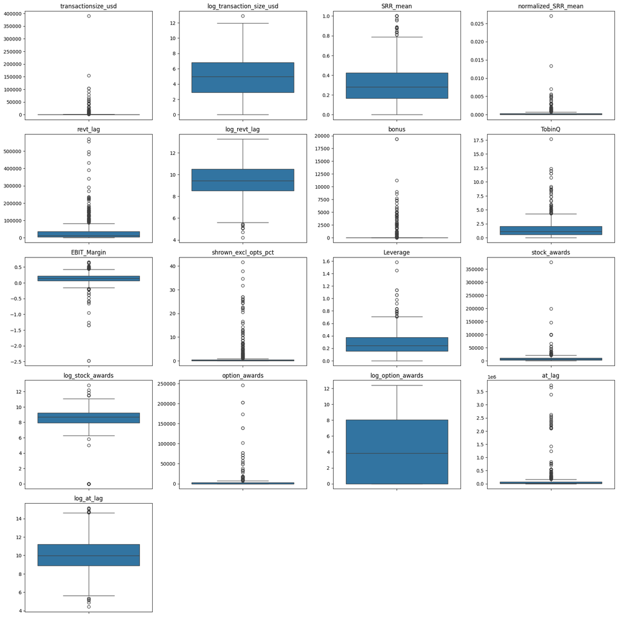

```python
# Variables
vars_to_plot = [
    "transactionsize_usd",
    "log_transaction_size_usd",
    "SRR_mean",
    "normalized_SRR_mean",
    "revt_lag",
    "log_revt_lag",
    "bonus",
    "TobinQ",
    "EBIT_Margin",
    "shrown_excl_opts_pct",
    "Leverage",
    "stock_awards","log_stock_awards",
    "option_awards","log_option_awards",
    "at_lag","log_at_lag",

]

# Create a figure with 5 rows and 4 columns
fig, axes = plt.subplots(5, 4, figsize=(18, 18))
axes = axes.flatten()

# Boxplots
for i, col in enumerate(vars_to_plot):
    d = final_data[col].dropna()
    sns.boxplot(y=d, ax=axes[i])
    axes[i].set_title(col)
    axes[i].set_xlabel("")
    axes[i].set_ylabel("")

# Turn off unused subplots
for j in range(len(vars_to_plot), 20):
    axes[j].axis("off")

plt.tight_layout()
plt.show()
```

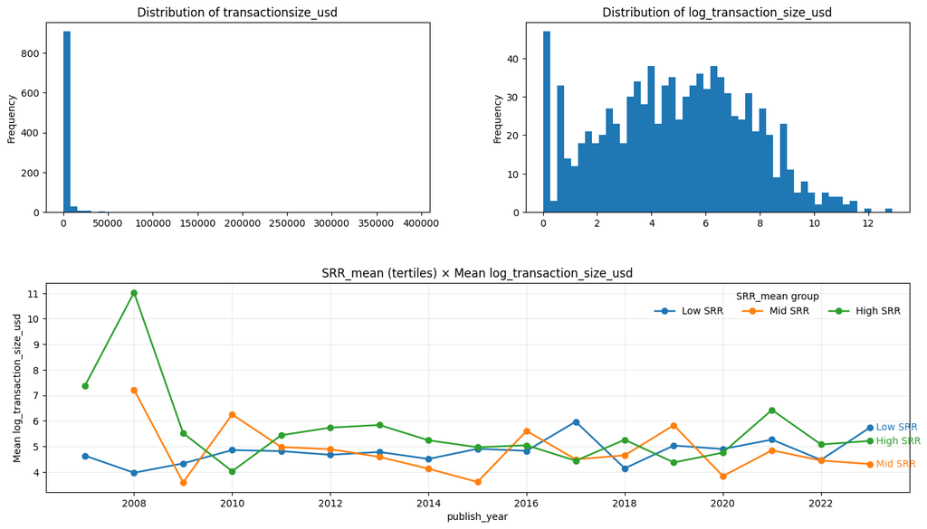

```python
df = final_data.copy()


# --- keep only what we need ---
cols = ["transactionsize_usd", "log_transaction_size_usd", "SRR_mean", "normalized_SRR_mean", "publish_year"]
d = df[cols].dropna(subset=["log_transaction_size_usd", "publish_year"]).copy()
d["publish_year"] = d["publish_year"].astype(int)

# =========================
# Figure layout:
# Row 1: 1x2 distributions
# Row 2: SRR interaction (spans both columns)
# Row 3: normalized SRR interaction (spans both columns)
# =========================
fig = plt.figure(figsize=(16, 14))
gs = fig.add_gridspec(nrows=3, ncols=2, height_ratios=[1, 1.1, 1.1], hspace=0.35, wspace=0.25)

# ---------- Top row: distributions ----------
ax1 = fig.add_subplot(gs[0, 0])
raw = d["transactionsize_usd"].dropna()
ax1.hist(raw, bins=50)
ax1.set_title("Distribution of transactionsize_usd")
ax1.set_ylabel("Frequency")

ax2 = fig.add_subplot(gs[0, 1])
logv = d["log_transaction_size_usd"].dropna()
ax2.hist(logv, bins=50)
ax2.set_title("Distribution of log_transaction_size_usd")
ax2.set_ylabel("Frequency")


# ---------- Bottom 1: SRR_mean interaction over years ----------
ax3 = fig.add_subplot(gs[1, :])

tmp = d.dropna(subset=["SRR_mean", "log_transaction_size_usd", "publish_year"]).copy()
tmp["SRR_group"] = pd.qcut(tmp["SRR_mean"], q=3, labels=["Low SRR", "Mid SRR", "High SRR"])

g1 = (tmp.groupby(["publish_year", "SRR_group"])["log_transaction_size_usd"]
        .mean()
        .reset_index()
        .pivot(index="publish_year", columns="SRR_group", values="log_transaction_size_usd")
        .sort_index())

# Choose colors (explicitly requested by you)
color_map = {
    "Low SRR":  "tab:blue",
    "Mid SRR":  "tab:orange",
    "High SRR": "tab:green",
}

for grp in g1.columns:
    y = g1[grp]
    ax3.plot(
        g1.index, y,
        marker="o",
        linewidth=1.8,
        color=color_map.get(grp, None),
        label=grp
    )

    # ---- Label the line on the chart (at the last available point) ----
    last_valid_year = y.dropna().index.max()
    if pd.notna(last_valid_year):
        last_y = y.loc[last_valid_year]
        ax3.annotate(
            grp,
            xy=(last_valid_year, last_y),
            xytext=(6, 0),             # small right offset
            textcoords="offset points",
            va="center",
            fontsize=10,
            color=color_map.get(grp, "black")
        )

ax3.set_title("SRR_mean (tertiles) × Mean log_transaction_size_usd")
ax3.set_xlabel("publish_year")
ax3.set_ylabel("Mean log_transaction_size_usd")
ax3.legend(title="SRR_mean group", ncol=3, frameon=False)
ax3.grid(True, alpha=0.25)
```

Transaction size is really skewed, log transaction will be used to normalize the distribitution

The extreme separation in 2007–2010 is likely driven by a small number of observations and/or influential mega-deals, making group means in those years less stable.

Visually, there is no stable pattern for high SRR always make larger deals each year. In first period ( 2007-2009 ) SRR is very unstable suggests that there were too few observations.

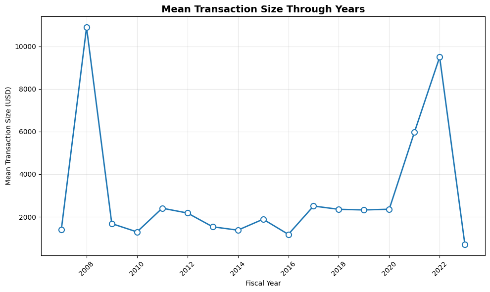

```python
import matplotlib.pyplot as plt
from matplotlib.ticker import MaxNLocator
# Calculate mean transaction size per year
mean_data = (
    final_data.groupby("publish_year", as_index=False)["transactionsize_usd"]
    .mean()
    .rename(columns={"transactionsize_usd": "mean_transactionsize_usd"})
)
fig, ax = plt.subplots(figsize=(10, 6))

ax.plot(
    mean_data["publish_year"],
    mean_data["mean_transactionsize_usd"],
    marker="o", linewidth=2,
    markersize=8, markerfacecolor="white", markeredgewidth=1.5
)

ax.set_title("Mean Transaction Size Through Years", fontsize=14, fontweight="bold")
ax.set_xlabel("Fiscal Year")
ax.set_ylabel("Mean Transaction Size (USD)")

ax.xaxis.set_major_locator(MaxNLocator(integer=True))
ax.tick_params(axis="x", rotation=45)

ax.grid(True, alpha=0.3)
plt.tight_layout()
plt.show()
```

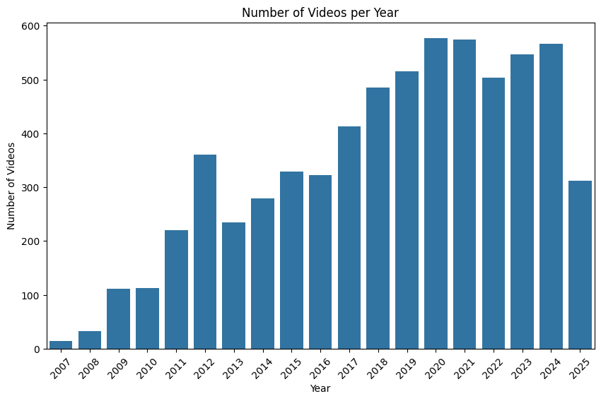

```python
#plot the number of videos per year
plt.figure(figsize=(10, 6))
sns.countplot(x='publish_year', data=interview, order=sorted(interview['publish_year'].dropna().unique()))
plt.title('Number of Videos per Year')
plt.xlabel('Year')
plt.ylabel('Number of Videos')
plt.xticks(rotation=45)
plt.show()
```

The bar chart shows a strong upward trend in the number of videos over time. Peaking around 2020–2021 (~570–580 videos)

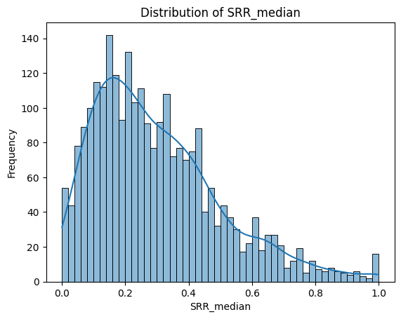

```python
# plot the distribution of SRR_median
sns.histplot(final_merged['SRR_median'], bins=50, kde=True)
plt.title('Distribution of SRR_median')
plt.xlabel('SRR_median')
plt.ylabel('Frequency')
plt.show()
```

The histogram shows SRR_median is right-skewed: most observations cluster at low values (roughly 0.1–0.3, peaking around ~0.15–0.2), and the frequency declines steadily as SRR_median increases, with a long tail extending toward 1.0 (few very high-SRR cases).

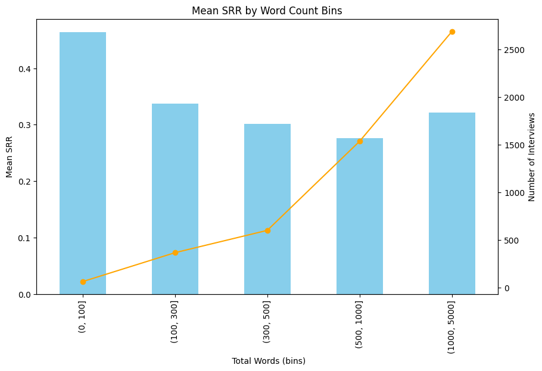

```python
# Word Count Binning Analysis
interview["word_bin"] = pd.cut(
    interview["total_words"],
    bins=[0, 100, 300, 500, 1000, 5000]
)
bin_means = interview.groupby("word_bin")["SRR_mean"].mean()
fig, ax1 = plt.subplots(figsize=(10, 6))
bin_means.plot(kind="bar", ax=ax1, color="skyblue")
ax1.set_ylabel("Mean SRR")
ax1.set_xlabel(" Total Words (bins)")
ax2 = ax1.twinx()
bin_counts = interview["word_bin"].value_counts().sort_index()
bin_counts.plot(kind="line", ax=ax2, color="orange", marker="o")
ax2.set_ylabel("Number of Interviews")
plt.title("Mean SRR by Word Count Bins")
plt.show()
```

Mean SRR is highest in very short interviews (0–100 words) and generally declines as word count increases, stabilizing around ~0.27–0.33 for longer interviews. SRR estimates from short transcripts are noisier and more extreme, while longer interviews provide more stable averages.

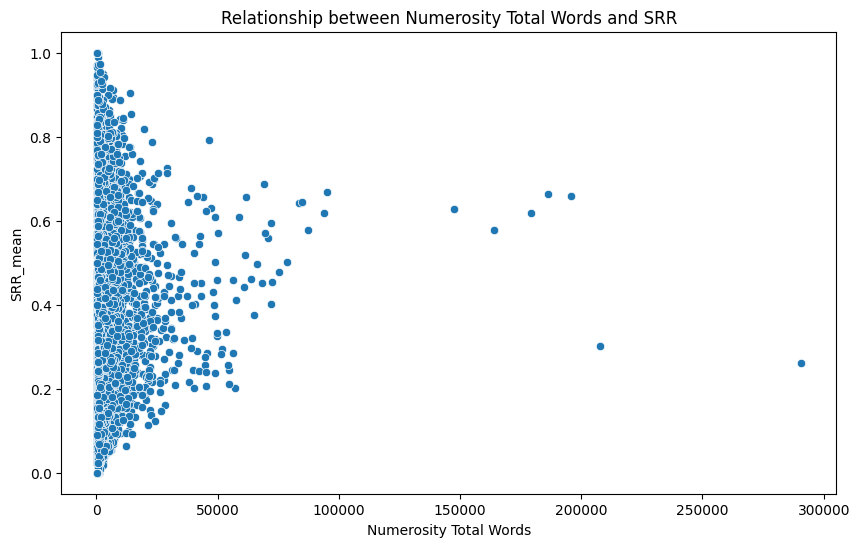

```python
# plot the relationship between numerosity_total_words and SRR
plt.figure(figsize=(10, 6))
sns.scatterplot(x='total_words', y='SRR_mean', data=interview)
plt.title('Relationship between Numerosity Total Words and SRR')
plt.xlabel('Numerosity Total Words')
plt.ylabel('SRR_mean')
plt.show()
```

Very short interviews show high dispersion (SRR ranges from near 0 to near 1), while as word count increases, SRR values become more concentrated around mid-levels (roughly 0.2–0.6). This indicates SRR is noisier in short transcripts and more stable for longer interviews.

Short interviews show high SRR -> SRR should be normalized

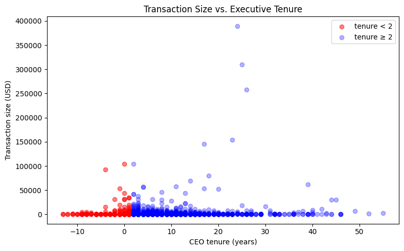

```python
short = final_merged[final_merged["tenure_years"] < 2]
long  = final_merged[final_merged["tenure_years"] >= 2]

plt.figure(figsize=(8, 5))
plt.scatter(short["tenure_years"], short["transactionsize_usd"],
            color="red", alpha=0.5, label="tenure < 2")
plt.scatter(long["tenure_years"], long["transactionsize_usd"],
            color="blue", alpha=0.3, label="tenure ≥ 2")

plt.xlabel("CEO tenure (years)")
plt.ylabel("Transaction size (USD)")
plt.title("Transaction Size vs. Executive Tenure")
plt.legend()
plt.tight_layout()
plt.show()
```

Deal size varies a lot both for early and later‑tenure CEOs. And an acquisition deal is usually approved by the company’s board of directors, not only CEO. So we dont exlude tenure year<2. Research reports that CEO with more tenure year tend to make more shareholder value in M&A. In this study it will be just controlled variable, we focus on SRR.

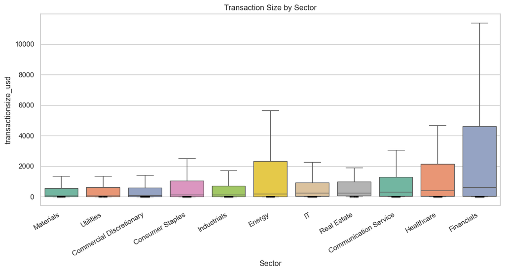

```python
# ensure sector names exist
sector_names = {
    10: 'Energy',
    15: 'Materials',
    20: 'Industrials',
    25: 'Commercial Discretionary',
    30: 'Consumer Staples',
    35: 'Healthcare',
    40: 'Financials',
    45: 'IT',
    50: 'Communication Service',
    55: 'Utilities',
    60: 'Real Estate'
}

final_merged["g_sector_name"] = final_merged["gsector"].map(sector_names)

# order sectors by median SRR
order = (
    final_merged.groupby("g_sector_name")["transactionsize_usd"]
    .median()
    .sort_values()
    .index
)

sns.set(style="whitegrid", font_scale=1.0)

plt.figure(figsize=(11, 6))
sns.boxplot(
    data=final_merged,
    x="g_sector_name",
    y="transactionsize_usd",
    order=order,
    palette="Set2",
    showfliers=False,   # hide outliers for cleaner boxes
)
sns.stripplot(
    data=final_merged,
    x="g_sector_name",
    y="normalized_SRR_mean",
    order=order,
    color="black",
    size=2,
    alpha=0.3
)

plt.title("Transaction Size by Sector")
plt.xlabel("Sector")
plt.ylabel("transactionsize_usd")
plt.xticks(rotation=30, ha="right")
plt.tight_layout()
plt.show()
```

The boxplots show that Financials (and to a lesser extent Healthcare and Energy) have the largest typical deal sizes.

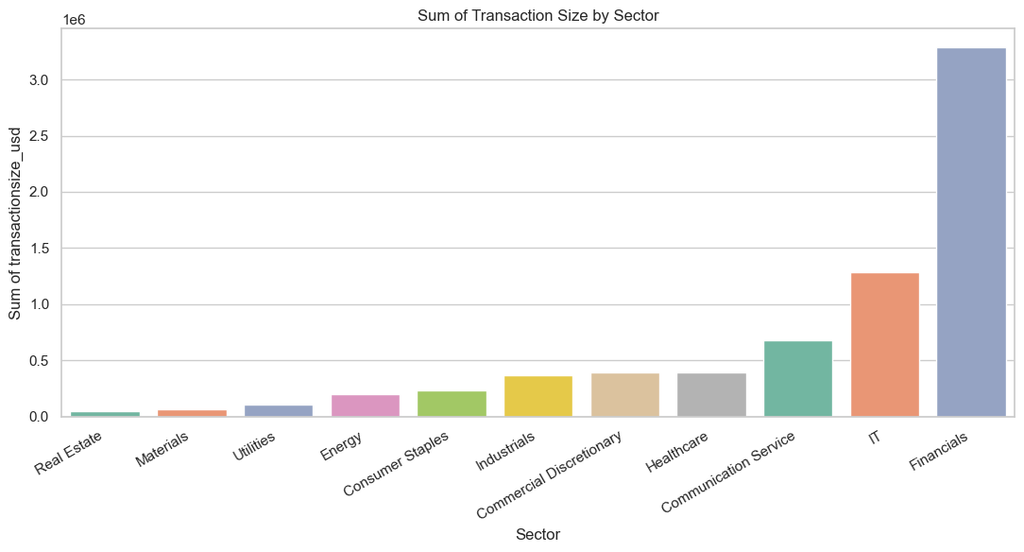

```python
# Sum of transaction size by sector
sector_sum = (
    final_merged
    .groupby("g_sector_name", as_index=False)["transactionsize_usd"]
    .sum()
)

# Order sectors by sum (optional)
sector_sum = sector_sum.sort_values("transactionsize_usd")

plt.figure(figsize=(11, 6))
sns.barplot(
    data=sector_sum,
    x="g_sector_name",
    y="transactionsize_usd",
    palette="Set2"
)

plt.title("Sum of Transaction Size by Sector")
plt.xlabel("Sector")
plt.ylabel("Sum of transactionsize_usd")
plt.xticks(rotation=30, ha="right")
plt.tight_layout()
plt.show()
```

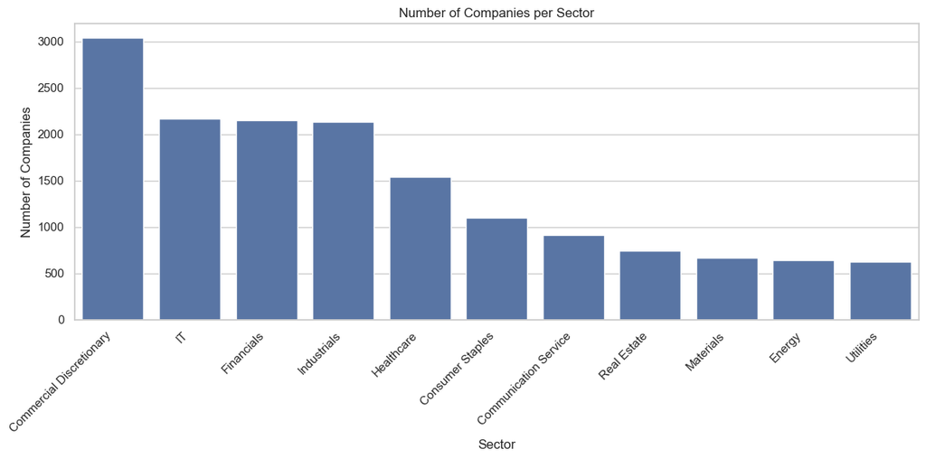

```python
com["gsector_name"] = com["gsector"].map(sector_names)
# 2) Order bars by count (descending)
order = com["gsector_name"].value_counts().index

# 3) Plot
plt.figure(figsize=(12, 6))
sns.countplot(x="gsector_name", data=com, order=order)
plt.title("Number of Companies per Sector")
plt.xlabel("Sector")
plt.ylabel("Number of Companies")
plt.xticks(rotation=45, ha="right")
plt.tight_layout()
plt.show()
```

### 2.2 Correlation of variables

Result: The normalized SRR variables have correlations that are near 0 with almost everything. They are very “orthogonal” to the rest of your predictors Almost all off-diagonal correlations are small (close to 0 and smaller than 0.5 ) so there is no strong multicollinearity overall.

Normalized_SRR_mean is better than SRR_mean because it reduces collinearity risk.

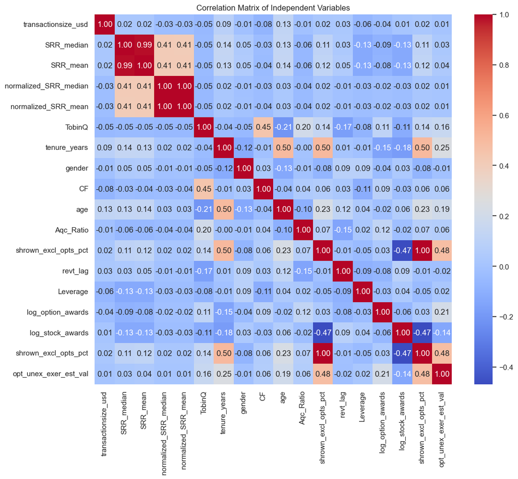

```python
X1=X = final_data[["transactionsize_usd","SRR_median","SRR_mean","normalized_SRR_median","normalized_SRR_mean", "TobinQ", "tenure_years", "gender","CF","age","Aqc_Ratio","shrown_excl_opts_pct","revt_lag","Leverage","log_option_awards","log_stock_awards","shrown_excl_opts_pct","opt_unex_exer_est_val"]]
#check the correlation of the variables
import seaborn as sns
import matplotlib.pyplot as plt
corr = X1.corr()
plt.figure(figsize=(12, 10))
sns.heatmap(corr, annot=True, fmt=".2f", cmap="coolwarm")
plt.title("Correlation Matrix of Independent Variables")
plt.show()
```

## 3. OLS Regression

## 3.1 Same-year regression

Purpose: OLS provides a simple and transparent way to test whether a CEO’s linguistic self-referencing measure—captured by the Singular-Referencing Ratio (SRR)—is related to M&A deal size when both are measured in the same time period. Conceptually, the model asks whether firms led by executives who speak more in “I/me/my” terms (higher SRR) tend to complete larger deals in that same year, after accounting for firm characteristics and other controls that also influence deal size.

Note: This specification is just a contemporaneous correlation rather than causal evidence. Because SRR and deal size are observed in the same period, the regression cannot fully rule out reverse causality (e.g., CEOs involved in major deals may communicate differently) or omitted factors that jointly affect both SRR and acquisition size.

Approach: Firm-clustered standard errors. In panel data, errors are typically heteroskedastic across firms, and correlated within a firm over time (serial correlation). Non-robust SEs assume neither of these is present, so they often understate the true uncertainty and can make results look “more significant” than they really are. Therefore, we rely on a set of controls and fixed effects, firm-clustered SE by gvkey and we later complement this analysis with alternative specifications to strengthen identification.

Process: To examine the performance of variance of SRR we chose, we build a function to run regressions ( m1,m2,m3) on `Raw SRR` and `normalized_SRR` then build a function to demonstrate the OLS result, focusing on `p_value`, `coef`, `R square` ( power of fit)

**Does SRR in this year relate to deal size in this year ?**

The model is estimated using the following specification:

\begin{align} ln(TransactionSize)_{it} = \beta_0 + \beta_1 SRR_{it} + \epsilon_{it} \end{align}

where

- $i$ denotes the firm/individual.
- $t$ denotes the fiscal year.
- $\epsilon_{it}$ is the error term.

Result: In simple model, both raw_SRR and normalized_SRR are all insignificant ( cov_type: non_robust ), normalized_SRR is statistically significant ( cov_type: clusted).

```python
def simple_ols(data, dependent_var, independent_vars):
    """
    OLS model: dependent_var ~ const + independent_var
    """
    rows = []
    for x in independent_vars:
        d = data[[dependent_var, x]].dropna()
        X = sm.add_constant(d[[x]])
        y = d[dependent_var]

        res = sm.OLS(y, X).fit()

        rows.append({
            "model": x,
            "coef": res.params[x],
            "std_err": res.bse[x],
            "p_value": res.pvalues[x],
            "t_stat": res.tvalues[x],
            "F_stat": res.fvalue,
            "Probabilitiy_F_stat": res.f_pvalue,
            "R_squared": res.rsquared,
            "adj_R_squared": res.rsquared_adj,
            "[0.025": res.conf_int().loc[x, 0],
            "0.975]": res.conf_int().loc[x, 1],
            "kurtosis": res.resid.kurtosis,
            "skewness": res.resid.skew(),
            "Cond. No.": res.condition_number,
            "n": int(res.nobs)
        })

    table = pd.DataFrame(rows).set_index("model")
    return table[["coef", "std_err", "p_value", "t_stat", "R_squared", "adj_R_squared", "n"]]

# use it
m1_sameyear_nocl = simple_ols(
    final_data,
    dependent_var="log_transaction_size_usd",
    independent_vars=["SRR_median", "SRR_mean", "normalized_SRR_mean", "normalized_SRR_median"]
)

print("Simple regression on log_transaction_size_usd, nonrobust: \n")

display(m1_sameyear_nocl)
```

```
Simple regression on log_transaction_size_usd, nonrobust:
```

| model | coef | std_err | p_value | t_stat | R_squared | adj_R_squared | n |
| --- | --- | --- | --- | --- | --- | --- | --- |
| SRR_median | 0.669448 | 0.420968 | 0.112104 | 1.590260 | 0.002619 | 0.001584 | 965 |
| SRR_mean | 0.816221 | 0.432003 | 0.059140 | 1.889386 | 0.003693 | 0.002659 | 965 |
| normalized_SRR_mean | -66.782098 | 74.455089 | 0.369973 | -0.896945 | 0.000835 | -0.000203 | 965 |
| normalized_SRR_median | -67.594356 | 74.425515 | 0.363992 | -0.908215 | 0.000856 | -0.000182 | 965 |

```python
def simple_ols_clustered(data, dependent_var, independent_vars, cluster_col="gvkey"):
    """
    Runs separate bivariate OLS models: y ~ const + x
    Returns a compact table using firm-clustered standard errors.
    """
    rows = []
    for x in independent_vars:
        d = data[[dependent_var, x, cluster_col]].dropna()
        X = sm.add_constant(d[[x]])
        y = d[dependent_var]
        groups = d[cluster_col]

        res = sm.OLS(y, X).fit(
            cov_type="cluster",
            cov_kwds={"groups": groups, "use_correction": True}
        )

        rows.append({
            "model": x,
            "coef": res.params[x],
            "std_err": res.bse[x],
            "p_value": res.pvalues[x],
            "t_stat": res.tvalues[x],
            # With clustered SEs, model-wide F-stat may be unstable; keep if you want:
            "F_stat": getattr(res, "fvalue", np.nan),
            "R_squared": res.rsquared,
            "adj_R_squared": res.rsquared_adj,
            "n_obs": int(res.nobs),
            "n_clusters": d[cluster_col].nunique()
        })

    table = pd.DataFrame(rows).set_index("model")
    return table[["coef", "std_err", "p_value", "t_stat", "R_squared", "adj_R_squared", "n_obs", "n_clusters"]]

# ------- use it -----------------
m1_same_year = simple_ols_clustered(
    final_data,
    dependent_var="log_transaction_size_usd",
    independent_vars=["SRR_median", "SRR_mean", "normalized_SRR_mean", "normalized_SRR_median"],
    cluster_col="gvkey"
)

print("Simple regression on log_transaction_size_usd, firm-clustered SE (gvkey):\n")
display(m1_same_year)
```

```
Simple regression on log_transaction_size_usd, firm-clustered SE (gvkey):
```

| model | coef | std_err | p_value | t_stat | R_squared | adj_R_squared | n_obs | n_clusters |
| --- | --- | --- | --- | --- | --- | --- | --- | --- |
| SRR_median | 0.669448 | 0.494121 | 0.175473 | 1.354826 | 0.002619 | 0.001584 | 965 | 222 |
| SRR_mean | 0.816221 | 0.497932 | 0.101167 | 1.639222 | 0.003693 | 0.002659 | 965 | 222 |
| normalized_SRR_mean | -66.782098 | 33.917111 | 0.048955 | -1.968980 | 0.000835 | -0.000203 | 965 | 222 |
| normalized_SRR_median | -67.594356 | 33.981425 | 0.046684 | -1.989156 | 0.000856 | -0.000182 | 965 | 222 |

The control model (m2 ) is estimated using the following specification:

\begin{align} ln(TransactionSize)_{it} = \beta_0 + \beta_1 SRR_{it} + \sum_{k=1}^{n} \gamma_k \text{Controls}_{it,k} + \epsilon_{it} \end{align}

where

- $i$ denotes the firm/individual.
- $t$ denotes the fiscal year.
- $Controls_{it,k}$ represents the k-th control variable for firm/individual i at time t.
- $\epsilon_{it}$ is the error term.

Result: Both SRR are insignificant ( no clustering and with clustering ). SRR does not have a statistically reliable association with current-year deal size.

```python
def ols_with_controls(data, dependent_var, independent_vars, control_vars):



    results_list = []
    models = {}

    for x in independent_vars:
        # Build formula
        formula_parts = [dependent_var, "~", x]

        # Add control variables
        for ctrl in control_vars:
            formula_parts.append(f"+ {ctrl}")

        formula = " ".join(formula_parts)

        # Fit model
        try:
            model = smf.ols(formula, data=data).fit()
            models[x] = model

            # Extract results for main independent variable
            results_list.append({
                'Independent_Variable': x,
                'Coefficient': model.params[x],
                'Std_Error': model.bse[x],
                'T_Stat': model.tvalues[x],
                'P_Value': model.pvalues[x],
                '[0.025': model.conf_int().loc[x, 0],
                '0.975]': model.conf_int().loc[x, 1],
                'R_Squared': model.rsquared,
                'Adj_R_Squared': model.rsquared_adj,
                'F_Stat': model.fvalue,
                'Prob_F_Stat': model.f_pvalue,

            })
        except Exception as e:
            print(f"Error fitting model for {x}: {str(e)}")
            continue

    results_df = pd.DataFrame(results_list)
    return results_df, models

#Regression with basic controls
control_vars = ["TobinQ", "tenure_years", "gender", "age", "log_stock_awards",
                "EBIT_Margin","shrown_excl_opts_pct","Leverage","log_option_awards","log_revt_lag","log_at_lag"]
m2_sameyear_nocl, models_basic = ols_with_controls(
    data=final_data,
    dependent_var="log_transaction_size_usd",
    independent_vars=["SRR_median", "SRR_mean", "normalized_SRR_mean", "normalized_SRR_median"],
    control_vars=control_vars,
)

print("Regression with Controls Results on log_transaction_size_usd with Controls:, no clustering\n")
display(m2_sameyear_nocl)
```

```
Regression with Controls Results on log_transaction_size_usd with Controls:, no clustering
```

|  | Independent_Variable | Coefficient | Std_Error | T_Stat | P_Value | [0.025 | 0.975] | R_Squared | Adj_R_Squared | F_Stat | Prob_F_Stat |
| --- | --- | --- | --- | --- | --- | --- | --- | --- | --- | --- | --- |
| 0 | SRR_median | 0.270576 | 0.414891 | 0.652161 | 0.514455 | -0.543632 | 1.084783 | 0.110410 | 0.099196 | 9.846290 | 2.452449e-18 |
| 1 | SRR_mean | 0.356056 | 0.426407 | 0.835015 | 0.403919 | -0.480750 | 1.192862 | 0.110664 | 0.099453 | 9.871752 | 2.165077e-18 |
| 2 | normalized_SRR_mean | -19.862534 | 71.243908 | -0.278796 | 0.780462 | -159.675781 | 119.950712 | 0.110085 | 0.098867 | 9.813744 | 2.875997e-18 |
| 3 | normalized_SRR_median | -20.260794 | 71.218074 | -0.284489 | 0.776097 | -160.023343 | 119.501755 | 0.110088 | 0.098870 | 9.814044 | 2.871772e-18 |

```python
formula = (
    "log_transaction_size_usd ~ normalized_SRR_median + TobinQ + tenure_years + gender + age + "
    "log_stock_awards + EBIT_Margin + shrown_excl_opts_pct + Leverage + "
    "log_option_awards + log_revt_lag + log_at_lag"
)

base = smf.ols(formula, data=final_data, missing="drop")
m2 = base.fit()  # No clustering - uses standard OLS SEs

print(m2.summary())
```

```
                               OLS Regression Results
====================================================================================
Dep. Variable:     log_transaction_size_usd   R-squared:                       0.110
Model:                                  OLS   Adj. R-squared:                  0.099
Method:                       Least Squares   F-statistic:                     9.814
Date:                      Fri, 30 Jan 2026   Prob (F-statistic):           2.87e-18
Time:                              23:13:53   Log-Likelihood:                -2266.5
No. Observations:                       965   AIC:                             4559.
Df Residuals:                           952   BIC:                             4622.
Df Model:                                12
Covariance Type:                  nonrobust
=========================================================================================
                            coef    std err          t      P>|t|      [0.025      0.975]
-----------------------------------------------------------------------------------------
Intercept                 0.0286      0.907      0.031      0.975      -1.752       1.809
normalized_SRR_median   -20.2608     71.218     -0.284      0.776    -160.023     119.502
TobinQ                    0.1596      0.055      2.921      0.004       0.052       0.267
tenure_years              0.0029      0.013      0.224      0.823      -0.023       0.028
gender                    0.4373      0.343      1.273      0.203      -0.237       1.111
age                       0.0127      0.015      0.839      0.402      -0.017       0.042
log_stock_awards         -0.0020      0.033     -0.061      0.951      -0.067       0.063
EBIT_Margin               1.2352      0.428      2.888      0.004       0.396       2.075
shrown_excl_opts_pct      0.0213      0.025      0.861      0.390      -0.027       0.070
Leverage                 -0.3417      0.461     -0.741      0.459      -1.246       0.563
log_option_awards        -0.0438      0.021     -2.096      0.036      -0.085      -0.003
log_revt_lag             -0.1914      0.112     -1.712      0.087      -0.411       0.028
log_at_lag                0.5742      0.100      5.728      0.000       0.377       0.771
==============================================================================
Omnibus:                       31.298   Durbin-Watson:                   1.912
Prob(Omnibus):                  0.000   Jarque-Bera (JB):               16.142
Skew:                          -0.105   Prob(JB):                     0.000312
Kurtosis:                       2.403   Cond. No.                     5.13e+04
==============================================================================

Notes:
[1] Standard Errors assume that the covariance matrix of the errors is correctly specified.
[2] The condition number is large, 5.13e+04. This might indicate that there are
strong multicollinearity or other numerical problems.
```

```python
def ols_with_controls_clustered(
    data,
    dependent_var,
    independent_vars,
    control_vars,
    cluster_col="gvkey",
    use_correction=True
):

    # remove duplicates while keeping order
    control_vars = list(dict.fromkeys(control_vars))

    results_list = []
    models = {}

    for x in independent_vars:
        formula = f"{dependent_var} ~ {x}"
        if control_vars:
            formula += " + " + " + ".join(control_vars)

        try:
            base = smf.ols(formula, data=data, missing="drop")

            # align groups to the exact estimation sample
            used_idx = base.data.row_labels
            groups = data.loc[used_idx, cluster_col]

            res = base.fit(
                cov_type="cluster",
                cov_kwds={"groups": groups, "use_correction": use_correction}
            )

            models[x] = res
            ci = res.conf_int()

            results_list.append({
                "Independent_Variable": x,
                "coef": res.params.get(x, np.nan),
                "Std_Error": res.bse.get(x, np.nan),
                "T_Stat": res.tvalues.get(x, np.nan),
                "P_Value": res.pvalues.get(x, np.nan),
                "[0.025": ci.loc[x, 0] if x in ci.index else np.nan,
                "0.975]": ci.loc[x, 1] if x in ci.index else np.nan,
                "R_Squared": res.rsquared,
                "Adj_R_Squared": res.rsquared_adj,
                # With clustered SEs, model-wide F can be unstable; keep if you want:
                "N_Clusters": int(pd.Series(groups).nunique())
            })

        except Exception as e:
            print(f"Error fitting model for {x}: {str(e)}")
            continue

    results_df = pd.DataFrame(results_list)
    return results_df, models


# -------- run it ----------
control_vars = ["TobinQ", "tenure_years", "gender", "age",
                "log_stock_awards",
                "EBIT_Margin", "shrown_excl_opts_pct", "Leverage",
                "log_option_awards", "log_revt_lag", "log_at_lag"]

m2_same_year, models_basic_cl = ols_with_controls_clustered(
    data=final_data,
    dependent_var="log_transaction_size_usd",
    independent_vars=["SRR_median", "SRR_mean", "normalized_SRR_mean", "normalized_SRR_median"],
    control_vars=control_vars,
    cluster_col="gvkey"
)

print("Regression with Controls Results on log_transaction_size_usd (clustered by gvkey):\n")
display(m2_same_year)
```

```
Regression with Controls Results on log_transaction_size_usd (clustered by gvkey):
```

|  | Independent_Variable | coef | Std_Error | T_Stat | P_Value | [0.025 | 0.975] | R_Squared | Adj_R_Squared | N_Clusters |
| --- | --- | --- | --- | --- | --- | --- | --- | --- | --- | --- |
| 0 | SRR_median | 0.270576 | 0.393389 | 0.687807 | 0.491574 | -0.500453 | 1.041605 | 0.110410 | 0.099196 | 222 |
| 1 | SRR_mean | 0.356056 | 0.400473 | 0.889089 | 0.373955 | -0.428856 | 1.140968 | 0.110664 | 0.099453 | 222 |
| 2 | normalized_SRR_mean | -19.862534 | 32.193188 | -0.616979 | 0.537248 | -82.960024 | 43.234956 | 0.110085 | 0.098867 | 222 |
| 3 | normalized_SRR_median | -20.260794 | 32.277204 | -0.627712 | 0.530193 | -83.522952 | 43.001364 | 0.110088 | 0.098870 | 222 |

The full model (m3) is estimated using the following specification:

\begin{align} ln(TransactionSize)_{it} = \beta_0 + \beta_1 SRR_{it} + \sum_{k=1}^{n} \gamma_k \text{Controls}_{it,k} + \alpha_{it} + \delta_{t} + \epsilon_{it} \end{align}

where

- $i$ denotes the firm/individual.
- $t$ denotes the fiscal year.
- $\alpha_i$ and $\delta_t$ represent entity and time fixed effects respectively.
- $Controls_{it,k}$ represents the k-th control variable for firm/individual i at time t.
- $\epsilon_{it}$ is the error term.

Result: After controlling for covariates and fixed effects, SRR (mean/median and normalized) still does not significantly explain current-year log transaction size.

```python
# convert gvkey, gsector to categorical type
final_data["gvkey"] = final_data["gvkey"].astype("category")
final_data["gsector"] = final_data["gsector"].astype("category")
# Convert publish_year, gender to float
final_data["publish_year"] = final_data["publish_year"].astype(float)
final_data["gender"] = final_data["gender"].astype(float)
```

```python
def ols_with_controls_and_fe(
    data: pd.DataFrame,
    dependent_var: str,
    independent_vars: list,
    control_vars: list,
    fe_specs: dict,
    cov_type: str = "nonrobust",  # keep as-is
):
    """
    Runs OLS with controls + fixed effects for each FE spec and each independent var.
    Returns:
      models_fe[fe_name][x] = fitted statsmodels result
    """
    controls_str = " + ".join(control_vars) if control_vars else "1"

    models_fe = {}
    for fe_name, fe_terms in fe_specs.items():
        models_fe[fe_name] = {}
        for x in independent_vars:
            formula = f"{dependent_var} ~ {x} + {controls_str} + {fe_terms}"
            models_fe[fe_name][x] = smf.ols(formula, data=data).fit(cov_type=cov_type)

    return models_fe


def fe_results_table_nocl(models_fe: dict):
    rows = []
    for fe_name, sub in models_fe.items():
        for x, res in sub.items():
            ci = res.conf_int()
            rows.append({
                "FE_spec": fe_name,
                "Independent_Variable": x,
                "Coefficient": res.params.get(x, float("nan")),
                "Std_Error": res.bse.get(x, float("nan")),
                "T_Stat": res.tvalues.get(x, float("nan")),
                "P_Value": res.pvalues.get(x, float("nan")),
                "[0.025": ci.loc[x, 0] if x in ci.index else float("nan"),
                "0.975]": ci.loc[x, 1] if x in ci.index else float("nan"),
                "R_Squared": res.rsquared,
                "Adj_R_Squared": res.rsquared_adj,
                "F_Stat": res.fvalue,
                "Prob_F_Stat": res.f_pvalue,

            })
    return pd.DataFrame(rows)


# ---- inputs ----
control_vars = [
    "TobinQ", "tenure_years", "gender", "age",
    "log_stock_awards",
    "EBIT_Margin", "shrown_excl_opts_pct", "Leverage",
    "log_option_awards", "log_revt_lag", "log_at_lag"
]

"""
we decide to consider four fixed effect specifications to control time invariant characteristic of each unit(firm or sector)
and time varying macroeconomic factors (year) which may affect both independent and dependent variables, so that the coeffcients
can be interpreted as within-firm or within-sector effects over time.
"""

fe_specs = {
    "FE1: sector":        "C(gsector)",
    "FE2: sector + year": "C(gsector) + C(publish_year)",
    "FE3: firm ":   "C(gvkey) ",
    "FE4: sector + firm": "C(gsector) + C(gvkey)",
    "FE5: year": "C(publish_year)"
}

m3_sameyear_nocl = ols_with_controls_and_fe(
    data=final_data,
    dependent_var="log_transaction_size_usd",
    independent_vars=["SRR_median", "SRR_mean", "normalized_SRR_mean", "normalized_SRR_median"],
    control_vars=control_vars,
    fe_specs=fe_specs,
    cov_type="nonrobust"
)


m3_sameyear_nocl = fe_results_table_nocl(m3_sameyear_nocl)
print("Regression with Controls and Fixed Effects Results on log_transaction_size_usd:, no cluster \n")
display(m3_sameyear_nocl)
```

```
Regression with Controls and Fixed Effects Results on log_transaction_size_usd:, no cluster
```

|  | FE_spec | Independent_Variable | Coefficient | Std_Error | T_Stat | P_Value | [0.025 | 0.975] | R_Squared | Adj_R_Squared | F_Stat | Prob_F_Stat |
| --- | --- | --- | --- | --- | --- | --- | --- | --- | --- | --- | --- | --- |
| 0 | FE1: sector | SRR_median | -0.045327 | 0.423328 | -0.107074 | 0.914753 | -0.876101 | 0.785447 | 0.128621 | 0.108270 | 6.320224 | 1.650321e-17 |
| 1 | FE1: sector | SRR_mean | 0.000926 | 0.436059 | 0.002123 | 0.998306 | -0.854834 | 0.856686 | 0.128610 | 0.108259 | 6.319626 | 1.658462e-17 |
| 2 | FE1: sector | normalized_SRR_mean | -17.675723 | 71.336462 | -0.247780 | 0.804359 | -157.672495 | 122.321048 | 0.128667 | 0.108317 | 6.322829 | 1.615314e-17 |
| 3 | FE1: sector | normalized_SRR_median | -17.853952 | 71.303894 | -0.250392 | 0.802339 | -157.786811 | 122.078906 | 0.128668 | 0.108319 | 6.322897 | 1.614411e-17 |
| 4 | FE2: sector + year | SRR_median | 0.021914 | 0.437456 | 0.050095 | 0.960058 | -0.836605 | 0.880434 | 0.146435 | 0.111408 | 4.180577 | 3.853274e-15 |
| 5 | FE2: sector + year | SRR_mean | 0.116297 | 0.451821 | 0.257396 | 0.796930 | -0.770414 | 1.003008 | 0.146494 | 0.111469 | 4.182543 | 3.758957e-15 |
| 6 | FE2: sector + year | normalized_SRR_mean | 3.167614 | 72.077478 | 0.043947 | 0.964956 | -138.286536 | 144.621764 | 0.146435 | 0.111407 | 4.180559 | 3.854140e-15 |
| 7 | FE2: sector + year | normalized_SRR_median | 2.578818 | 72.038100 | 0.035798 | 0.971451 | -138.798051 | 143.955688 | 0.146434 | 0.111406 | 4.180539 | 3.855114e-15 |
| 8 | FE3: firm | SRR_median | -0.447099 | 0.561614 | -0.796096 | 0.426235 | -1.549667 | 0.655470 | 0.425314 | 0.242137 | 2.321879 | 1.597365e-17 |
| 9 | FE3: firm | SRR_mean | -0.294058 | 0.578925 | -0.507937 | 0.611651 | -1.430612 | 0.842497 | 0.425018 | 0.241748 | 2.319076 | 1.780284e-17 |
| 10 | FE3: firm | normalized_SRR_mean | -46.241982 | 83.918686 | -0.551033 | 0.581779 | -210.992365 | 118.508400 | 0.425054 | 0.241795 | 2.319416 | 1.757000e-17 |
| 11 | FE3: firm | normalized_SRR_median | -46.466175 | 83.909304 | -0.553767 | 0.579908 | -211.198139 | 118.265789 | 0.425056 | 0.241798 | 2.319439 | 1.755470e-17 |
| 12 | FE4: sector + firm | SRR_median | -0.447099 | 0.561614 | -0.796096 | 0.426235 | -1.549667 | 0.655470 | 0.425314 | 0.242137 | 2.321879 | 1.597365e-17 |
| 13 | FE4: sector + firm | SRR_mean | -0.294058 | 0.578925 | -0.507937 | 0.611651 | -1.430612 | 0.842497 | 0.425018 | 0.241748 | 2.319076 | 1.780284e-17 |
| 14 | FE4: sector + firm | normalized_SRR_mean | -46.241982 | 83.918686 | -0.551033 | 0.581779 | -210.992365 | 118.508400 | 0.425054 | 0.241795 | 2.319416 | 1.757000e-17 |
| 15 | FE4: sector + firm | normalized_SRR_median | -46.466175 | 83.909304 | -0.553767 | 0.579908 | -211.198139 | 118.265789 | 0.425056 | 0.241798 | 2.319439 | 1.755470e-17 |
| 16 | FE5: year | SRR_median | 0.327269 | 0.431097 | 0.759155 | 0.447951 | -0.518759 | 1.173297 | 0.126678 | 0.100553 | 4.848898 | 7.900352e-15 |
| 17 | FE5: year | SRR_mean | 0.461195 | 0.444214 | 1.038227 | 0.299432 | -0.410575 | 1.332965 | 0.127145 | 0.101034 | 4.869399 | 6.444727e-15 |
| 18 | FE5: year | normalized_SRR_mean | -4.589097 | 72.058002 | -0.063686 | 0.949234 | -146.003047 | 136.824854 | 0.126144 | 0.100003 | 4.825510 | 9.965563e-15 |
| 19 | FE5: year | normalized_SRR_median | -5.329713 | 72.025318 | -0.073998 | 0.941028 | -146.679522 | 136.020096 | 0.126145 | 0.100004 | 4.825568 | 9.959824e-15 |

```python
m3 = smf.ols(
    "log_transaction_size_usd ~ normalized_SRR_mean + TobinQ + tenure_years + gender+ age "
    "+ log_stock_awards + EBIT_Margin + shrown_excl_opts_pct "
    "+ Leverage+ log_revt_lag+ log_at_lag+C(gsector)",
    data=final_data).fit()
m3.summary()
```

OLS Regression Results

| Dep. Variable: | log_transaction_size_usd | R-squared: | 0.124 |
| --- | --- | --- | --- |
| Model: | OLS | Adj. R-squared: | 0.105 |
| Method: | Least Squares | F-statistic: | 6.379 |
| Date: | Fri, 30 Jan 2026 | Prob (F-statistic): | 4.52e-17 |
| Time: | 23:13:53 | Log-Likelihood: | -2258.7 |
| No. Observations: | 965 | AIC: | 4561. |
| Df Residuals: | 943 | BIC: | 4669. |
| Df Model: | 21 |  |  |
| Covariance Type: | nonrobust |  |  |

|  | coef | std err | t | P>\|t\| | [0.025 | 0.975] |
| --- | --- | --- | --- | --- | --- | --- |
| Intercept | -0.6222 | 1.054 | -0.590 | 0.555 | -2.691 | 1.447 |
| C(gsector)[T.15.0] | -0.1075 | 0.551 | -0.195 | 0.845 | -1.188 | 0.973 |
| C(gsector)[T.20.0] | 0.3052 | 0.473 | 0.646 | 0.519 | -0.622 | 1.233 |
| C(gsector)[T.25.0] | 0.4154 | 0.481 | 0.863 | 0.388 | -0.529 | 1.360 |
| C(gsector)[T.30.0] | 0.0049 | 0.510 | 0.010 | 0.992 | -0.997 | 1.007 |
| C(gsector)[T.35.0] | 0.8995 | 0.498 | 1.807 | 0.071 | -0.077 | 1.876 |
| C(gsector)[T.40.0] | 1.3399 | 0.562 | 2.384 | 0.017 | 0.237 | 2.443 |
| C(gsector)[T.45.0] | 0.6504 | 0.459 | 1.417 | 0.157 | -0.250 | 1.551 |
| C(gsector)[T.50.0] | 1.2628 | 0.516 | 2.446 | 0.015 | 0.250 | 2.276 |
| C(gsector)[T.55.0] | 0.1035 | 0.743 | 0.139 | 0.889 | -1.355 | 1.561 |
| C(gsector)[T.60.0] | 0.6685 | 0.776 | 0.862 | 0.389 | -0.853 | 2.191 |
| normalized_SRR_mean | -12.8298 | 71.438 | -0.180 | 0.858 | -153.025 | 127.366 |
| TobinQ | 0.1466 | 0.058 | 2.540 | 0.011 | 0.033 | 0.260 |
| tenure_years | 0.0070 | 0.013 | 0.528 | 0.597 | -0.019 | 0.033 |
| gender | 0.3971 | 0.351 | 1.131 | 0.258 | -0.292 | 1.086 |
| age | 0.0134 | 0.015 | 0.877 | 0.381 | -0.017 | 0.043 |
| log_stock_awards | 0.0102 | 0.034 | 0.302 | 0.763 | -0.056 | 0.076 |
| EBIT_Margin | 0.9954 | 0.441 | 2.259 | 0.024 | 0.131 | 1.860 |
| shrown_excl_opts_pct | 0.0096 | 0.026 | 0.373 | 0.709 | -0.041 | 0.060 |
| Leverage | 0.0824 | 0.525 | 0.157 | 0.875 | -0.948 | 1.113 |
| log_revt_lag | -0.0175 | 0.152 | -0.115 | 0.909 | -0.316 | 0.281 |
| log_at_lag | 0.3793 | 0.142 | 2.676 | 0.008 | 0.101 | 0.657 |

| Omnibus: | 33.087 | Durbin-Watson: | 1.927 |
| --- | --- | --- | --- |
| Prob(Omnibus): | 0.000 | Jarque-Bera (JB): | 16.439 |
| Skew: | -0.093 | Prob(JB): | 0.000269 |
| Kurtosis: | 2.388 | Cond. No. | 5.15e+04 |

Notes:  
[1] Standard Errors assume that the covariance matrix of the errors is correctly specified.  
[2] The condition number is large, 5.15e+04. This might indicate that there are  
strong multicollinearity or other numerical problems.

```python
def ols_with_controls_and_fe_clusterd(
    data: pd.DataFrame,
    dependent_var: str,
    independent_vars: list,
    control_vars: list,
    fe_specs: dict,
    cov_type: str = "cluster",     # "nonrobust", "HC1", "HC3", "cluster"
    cluster_col: str | None = None,  # firm id for clustering
    use_correction: bool = True
):
    control_vars = list(dict.fromkeys(control_vars))
    controls_str = " + ".join(control_vars) if control_vars else ""  # <- don't force "1"

    models_fe = {}
    for fe_name, fe_terms in fe_specs.items():
        models_fe[fe_name] = {}
        for x in independent_vars:
            rhs_parts = [x]
            if controls_str:
                rhs_parts.append(controls_str)
            if fe_terms and fe_terms.strip():
                rhs_parts.append(fe_terms)

            formula = f"{dependent_var} ~ " + " + ".join(rhs_parts)

            base = smf.ols(formula, data=data, missing="drop")

            if cov_type == "cluster":
                if not cluster_col:
                    raise ValueError("cov_type='cluster' requires cluster_col (e.g., 'gvkey').")

                used_idx = base.data.row_labels
                groups = data.loc[used_idx, cluster_col]

                res = base.fit(
                    cov_type="cluster",
                    cov_kwds={"groups": groups, "use_correction": use_correction}
                )
            elif cov_type == "nonrobust":
                res = base.fit()
            else:
                res = base.fit(cov_type=cov_type)

            models_fe[fe_name][x] = res

    return models_fe


def fe_results_table(models_fe: dict, data: pd.DataFrame, cluster_col: str | None = None):
    rows = []
    for fe_name, sub in models_fe.items():
        for x, res in sub.items():
            ci = res.conf_int()
            used_idx = res.model.data.row_labels

            n_clusters = np.nan
            if cluster_col is not None:
                n_clusters = int(data.loc[used_idx, cluster_col].nunique())

            rows.append({
                "FE_spec": fe_name,
                "Independent_Variable": x,
                "Coefficient": res.params.get(x, np.nan),
                "Std_Error": res.bse.get(x, np.nan),
                "T_Stat": res.tvalues.get(x, np.nan),
                "P_Value": res.pvalues.get(x, np.nan),
                "[0.025": ci.loc[x, 0] if x in ci.index else np.nan,
                "0.975]": ci.loc[x, 1] if x in ci.index else np.nan,
                "R_Squared": res.rsquared,
                "Adj_R_Squared": res.rsquared_adj,
                "N_Clusters": n_clusters,
                "N_Obs": int(res.nobs),
            })
    return pd.DataFrame(rows)


# ---- run clustered by firm ----

control_vars = [
    "TobinQ", "tenure_years", "gender", "age",
    "log_stock_awards",
    "EBIT_Margin", "shrown_excl_opts_pct", "Leverage",
    "log_option_awards", "log_revt_lag", "log_at_lag"
]

"""
we decide to consider four fixed effect specifications to control time invariant characteristic of each unit(firm or sector)
and time varying macroeconomic factors (year) which may affect both independent and dependent variables, so that the coeffcients
can be interpreted as within-firm or within-sector effects over time.
"""


fe_specs = {
    "FE1: sector":        "C(gsector)",
    "FE2: sector + year": "C(gsector) + C(publish_year)",
    "FE3: firm ":   "C(gvkey) ",
    "FE4: sector + firm": "C(gsector) + C(gvkey)",
    "FE5: year": "C(publish_year)"
}


models_same_year = ols_with_controls_and_fe_clusterd(
    data=final_data,
    dependent_var="log_transaction_size_usd",
    independent_vars=["SRR_median", "SRR_mean", "normalized_SRR_mean", "normalized_SRR_median"],
    control_vars=control_vars,
    fe_specs=fe_specs,
    cov_type="cluster",
    cluster_col="gvkey"
)

m3_sameyear = fe_results_table(models_same_year, data=final_data, cluster_col="gvkey")

print("Regression with Controls and Fixed Effects (clustered by firm gvkey):\n")
display(m3_sameyear)
```

```
Regression with Controls and Fixed Effects (clustered by firm gvkey):
```

|  | FE_spec | Independent_Variable | Coefficient | Std_Error | T_Stat | P_Value | [0.025 | 0.975] | R_Squared | Adj_R_Squared | N_Clusters | N_Obs |
| --- | --- | --- | --- | --- | --- | --- | --- | --- | --- | --- | --- | --- |
| 0 | FE1: sector | SRR_median | -0.045327 | 0.430679 | -0.105246 | 0.916181 | -0.889442 | 0.798788 | 0.128621 | 0.108270 | 222 | 965 |
| 1 | FE1: sector | SRR_mean | 0.000926 | 0.443336 | 0.002089 | 0.998334 | -0.867996 | 0.869848 | 0.128610 | 0.108259 | 222 | 965 |
| 2 | FE1: sector | normalized_SRR_mean | -17.675723 | 32.813193 | -0.538677 | 0.590110 | -81.988400 | 46.636954 | 0.128667 | 0.108317 | 222 | 965 |
| 3 | FE1: sector | normalized_SRR_median | -17.853952 | 32.862525 | -0.543292 | 0.586929 | -82.263318 | 46.555414 | 0.128668 | 0.108319 | 222 | 965 |
| 4 | FE2: sector + year | SRR_median | 0.021914 | 0.425172 | 0.051542 | 0.958894 | -0.811407 | 0.855235 | 0.146435 | 0.111408 | 222 | 965 |
| 5 | FE2: sector + year | SRR_mean | 0.116297 | 0.435664 | 0.266942 | 0.789514 | -0.737589 | 0.970183 | 0.146494 | 0.111469 | 222 | 965 |
| 6 | FE2: sector + year | normalized_SRR_mean | 3.167614 | 30.464737 | 0.103976 | 0.917188 | -56.542173 | 62.877401 | 0.146435 | 0.111407 | 222 | 965 |
| 7 | FE2: sector + year | normalized_SRR_median | 2.578818 | 30.560194 | 0.084385 | 0.932750 | -57.318061 | 62.475697 | 0.146434 | 0.111406 | 222 | 965 |
| 8 | FE3: firm | SRR_median | -0.447099 | 0.488698 | -0.914877 | 0.360256 | -1.404929 | 0.510731 | 0.425314 | 0.242137 | 222 | 965 |
| 9 | FE3: firm | SRR_mean | -0.294058 | 0.515950 | -0.569934 | 0.568722 | -1.305301 | 0.717186 | 0.425018 | 0.241748 | 222 | 965 |
| 10 | FE3: firm | normalized_SRR_mean | -46.241982 | 41.917482 | -1.103167 | 0.269955 | -128.398738 | 35.914773 | 0.425054 | 0.241795 | 222 | 965 |
| 11 | FE3: firm | normalized_SRR_median | -46.466175 | 41.909133 | -1.108736 | 0.267544 | -128.606565 | 35.674216 | 0.425056 | 0.241798 | 222 | 965 |
| 12 | FE4: sector + firm | SRR_median | -0.447099 | 0.492075 | -0.908598 | 0.363562 | -1.411548 | 0.517351 | 0.425314 | 0.242137 | 222 | 965 |
| 13 | FE4: sector + firm | SRR_mean | -0.294058 | 0.519516 | -0.566023 | 0.571378 | -1.312289 | 0.724174 | 0.425018 | 0.241748 | 222 | 965 |
| 14 | FE4: sector + firm | normalized_SRR_mean | -46.241982 | 42.207171 | -1.095595 | 0.273256 | -128.966518 | 36.482553 | 0.425054 | 0.241795 | 222 | 965 |
| 15 | FE4: sector + firm | normalized_SRR_median | -46.466175 | 42.198764 | -1.101126 | 0.270842 | -129.174232 | 36.241882 | 0.425056 | 0.241798 | 222 | 965 |
| 16 | FE5: year | SRR_median | 0.327269 | 0.397967 | 0.822353 | 0.410876 | -0.452731 | 1.107270 | 0.126678 | 0.100553 | 222 | 965 |
| 17 | FE5: year | SRR_mean | 0.461195 | 0.403829 | 1.142056 | 0.253431 | -0.330295 | 1.252684 | 0.127145 | 0.101034 | 222 | 965 |
| 18 | FE5: year | normalized_SRR_mean | -4.589097 | 32.598444 | -0.140777 | 0.888046 | -68.480873 | 59.302679 | 0.126144 | 0.100003 | 222 | 965 |
| 19 | FE5: year | normalized_SRR_median | -5.329713 | 32.758683 | -0.162696 | 0.870758 | -69.535551 | 58.876125 | 0.126145 | 0.100004 | 222 | 965 |

## 3.2 Regression for M&A spending next year

This part is to answer the question: **Does SRR this year is associated to deal size next year?**

Result:

In simple model, SRR_median and SRR_mean is significant, but normalized SRR is not significant at 5% level ( no clustering). While SRR and normalized_SRR are statistically significant ( p_value < 0.05 ). Higher SRR today is associated with larger log deal size next year ( cov_type: clustered)

```python
import statsmodels.api as sm

X = final_data[["SRR_mean"]]
y = final_data["log_transaction_size_usd_nextyear"]
X = sm.add_constant(X)
model = sm.OLS(y, X , missing="drop").fit()
print(model.summary())
```

```
                                    OLS Regression Results
=============================================================================================
Dep. Variable:     log_transaction_size_usd_nextyear   R-squared:                       0.010
Model:                                           OLS   Adj. R-squared:                  0.009
Method:                                Least Squares   F-statistic:                     9.497
Date:                               Fri, 30 Jan 2026   Prob (F-statistic):            0.00212
Time:                                       23:13:53   Log-Likelihood:                -2318.3
No. Observations:                                965   AIC:                             4641.
Df Residuals:                                    963   BIC:                             4650.
Df Model:                                          1
Covariance Type:                           nonrobust
==============================================================================
                 coef    std err          t      P>|t|      [0.025      0.975]
------------------------------------------------------------------------------
const          4.5348      0.162     28.067      0.000       4.218       4.852
SRR_mean       1.3276      0.431      3.082      0.002       0.482       2.173
==============================================================================
Omnibus:                       40.762   Durbin-Watson:                   1.742
Prob(Omnibus):                  0.000   Jarque-Bera (JB):               17.665
Skew:                          -0.007   Prob(JB):                     0.000146
Kurtosis:                       2.337   Cond. No.                         5.52
==============================================================================

Notes:
[1] Standard Errors assume that the covariance matrix of the errors is correctly specified.
```

```python
m1_nextyear_nocl = simple_ols(
    final_data,
    dependent_var="log_transaction_size_usd_nextyear",
    independent_vars=["SRR_median", "SRR_mean", "normalized_SRR_mean", "normalized_SRR_median"]
)

print("Simple regression on log_transaction_size_usd_nextyear, nonrobust: \n")

display(m1_nextyear_nocl)
```

```
Simple regression on log_transaction_size_usd_nextyear, nonrobust:
```

| model | coef | std_err | p_value | t_stat | R_squared | adj_R_squared | n |
| --- | --- | --- | --- | --- | --- | --- | --- |
| SRR_median | 1.236708 | 0.419748 | 0.003293 | 2.946311 | 0.008934 | 0.007905 | 965 |
| SRR_mean | 1.327601 | 0.430803 | 0.002117 | 3.081691 | 0.009765 | 0.008737 | 965 |
| normalized_SRR_mean | 119.290238 | 74.407334 | 0.109217 | 1.603205 | 0.002662 | 0.001626 | 965 |
| normalized_SRR_median | 119.768814 | 74.377687 | 0.107665 | 1.610279 | 0.002685 | 0.001650 | 965 |

```python
# ------- inputs -----------------
m1_nextyear = simple_ols_clustered(
    final_data,
    dependent_var="log_transaction_size_usd_nextyear",
    independent_vars=["SRR_median", "SRR_mean", "normalized_SRR_mean", "normalized_SRR_median"]
)

print("\n Simple regression on log_transaction_size_usd_nextyear, firm-clustered SE (gvkey): \n")
display(m1_nextyear)
```

```
 Simple regression on log_transaction_size_usd_nextyear, firm-clustered SE (gvkey):
```

| model | coef | std_err | p_value | t_stat | R_squared | adj_R_squared | n_obs | n_clusters |
| --- | --- | --- | --- | --- | --- | --- | --- | --- |
| SRR_median | 1.236708 | 0.497381 | 0.012903 | 2.486443 | 0.008934 | 0.007905 | 965 | 222 |
| SRR_mean | 1.327601 | 0.508296 | 0.009005 | 2.611864 | 0.009765 | 0.008737 | 965 | 222 |
| normalized_SRR_mean | 119.290238 | 59.052315 | 0.043375 | 2.020077 | 0.002662 | 0.001626 | 965 | 222 |
| normalized_SRR_median | 119.768814 | 59.169189 | 0.042952 | 2.024175 | 0.002685 | 0.001650 | 965 | 222 |

```python
#Regression with basic controls

m2_nextyear_nocl, models_basic = ols_with_controls(
    data=final_data,
    dependent_var="log_transaction_size_usd_nextyear",
    independent_vars=["SRR_median", "SRR_mean", "normalized_SRR_mean", "normalized_SRR_median"],
    control_vars=control_vars,
)

print("Regression with Controls Results on log_transaction_size_usd_nextyear with Controls:, no clustering\n")
display(m2_nextyear_nocl)
```

```
Regression with Controls Results on log_transaction_size_usd_nextyear with Controls:, no clustering
```

|  | Independent_Variable | Coefficient | Std_Error | T_Stat | P_Value | [0.025 | 0.975] | R_Squared | Adj_R_Squared | F_Stat | Prob_F_Stat |
| --- | --- | --- | --- | --- | --- | --- | --- | --- | --- | --- | --- |
| 0 | SRR_median | 0.937836 | 0.419153 | 2.237457 | 0.025487 | 0.115266 | 1.760406 | 0.092539 | 0.081101 | 8.090091 | 1.337219e-14 |
| 1 | SRR_mean | 0.964728 | 0.430846 | 2.239147 | 0.025377 | 0.119210 | 1.810245 | 0.092546 | 0.081108 | 8.090783 | 1.332699e-14 |
| 2 | normalized_SRR_mean | 165.887062 | 71.950863 | 2.305560 | 0.021349 | 24.686445 | 307.087679 | 0.092832 | 0.081398 | 8.118355 | 1.164358e-14 |
| 3 | normalized_SRR_median | 166.735987 | 71.922687 | 2.318267 | 0.020646 | 25.590664 | 307.881309 | 0.092888 | 0.081454 | 8.123722 | 1.134150e-14 |

```python
#Regression with basic controls

m2_nextyear, models_basic = ols_with_controls_clustered(
    data=final_data,
    dependent_var="log_transaction_size_usd_nextyear",
    independent_vars=["SRR_median", "SRR_mean", "normalized_SRR_mean", "normalized_SRR_median"],
    control_vars=control_vars,
)

print("Regression with Controls Results on log_transaction_size_usd_nextyear with Controls, firm-clustered SE (gvkey)::\n")
display(m2_nextyear)
```

```
Regression with Controls Results on log_transaction_size_usd_nextyear with Controls, firm-clustered SE (gvkey)::
```

|  | Independent_Variable | coef | Std_Error | T_Stat | P_Value | [0.025 | 0.975] | R_Squared | Adj_R_Squared | N_Clusters |
| --- | --- | --- | --- | --- | --- | --- | --- | --- | --- | --- |
| 0 | SRR_median | 0.937836 | 0.420967 | 2.227812 | 0.025893 | 0.112755 | 1.762917 | 0.092539 | 0.081101 | 222 |
| 1 | SRR_mean | 0.964728 | 0.429879 | 2.244185 | 0.024821 | 0.122180 | 1.807275 | 0.092546 | 0.081108 | 222 |
| 2 | normalized_SRR_mean | 165.887062 | 69.157706 | 2.398678 | 0.016454 | 30.340449 | 301.433675 | 0.092832 | 0.081398 | 222 |
| 3 | normalized_SRR_median | 166.735987 | 69.295991 | 2.406142 | 0.016122 | 30.918340 | 302.553634 | 0.092888 | 0.081454 | 222 |

Raw SRR and normalized SRR are statistically significant But SRR in same_year regression was not statistically significant in the same model.

One possible hypothesis is that SRR has a lagged effect. It takes time to turn into a boardroom decision for a giant merger.

```python
m2 = smf.ols(
    "log_transaction_size_usd_nextyear ~ normalized_SRR_mean + TobinQ + tenure_years + gender+ age "
    "+ log_stock_awards + EBIT_Margin + shrown_excl_opts_pct "
    "+ Leverage+ log_revt_lag+ log_at_lag",
    data=final_data).fit()
m2.summary()
```

OLS Regression Results

| Dep. Variable: | log_transaction_size_usd_nextyear | R-squared: | 0.089 |
| --- | --- | --- | --- |
| Model: | OLS | Adj. R-squared: | 0.078 |
| Method: | Least Squares | F-statistic: | 8.442 |
| Date: | Fri, 30 Jan 2026 | Prob (F-statistic): | 2.58e-14 |
| Time: | 23:13:54 | Log-Likelihood: | -2278.2 |
| No. Observations: | 965 | AIC: | 4580. |
| Df Residuals: | 953 | BIC: | 4639. |
| Df Model: | 11 |  |  |
| Covariance Type: | nonrobust |  |  |

|  | coef | std err | t | P>\|t\| | [0.025 | 0.975] |
| --- | --- | --- | --- | --- | --- | --- |
| Intercept | 0.6213 | 0.918 | 0.677 | 0.499 | -1.180 | 2.422 |
| normalized_SRR_mean | 168.8879 | 72.058 | 2.344 | 0.019 | 27.477 | 310.299 |
| TobinQ | 0.1332 | 0.055 | 2.417 | 0.016 | 0.025 | 0.241 |
| tenure_years | 0.0066 | 0.013 | 0.513 | 0.608 | -0.019 | 0.032 |
| gender | 0.4190 | 0.347 | 1.209 | 0.227 | -0.261 | 1.099 |
| age | -0.0027 | 0.015 | -0.180 | 0.857 | -0.033 | 0.027 |
| log_stock_awards | -0.0092 | 0.034 | -0.275 | 0.784 | -0.075 | 0.057 |
| EBIT_Margin | 0.9462 | 0.432 | 2.189 | 0.029 | 0.098 | 1.795 |
| shrown_excl_opts_pct | 0.0245 | 0.025 | 0.979 | 0.328 | -0.025 | 0.073 |
| Leverage | -0.2047 | 0.466 | -0.439 | 0.661 | -1.120 | 0.710 |
| log_revt_lag | -0.1093 | 0.111 | -0.985 | 0.325 | -0.327 | 0.108 |
| log_at_lag | 0.5114 | 0.100 | 5.128 | 0.000 | 0.316 | 0.707 |

| Omnibus: | 35.429 | Durbin-Watson: | 1.855 |
| --- | --- | --- | --- |
| Prob(Omnibus): | 0.000 | Jarque-Bera (JB): | 18.145 |
| Skew: | -0.133 | Prob(JB): | 0.000115 |
| Kurtosis: | 2.383 | Cond. No. | 5.12e+04 |

Notes:  
[1] Standard Errors assume that the covariance matrix of the errors is correctly specified.  
[2] The condition number is large, 5.12e+04. This might indicate that there are  
strong multicollinearity or other numerical problems.

```python
m2 = smf.ols(
    "log_transaction_size_usd_nextyear ~ normalized_SRR_median + TobinQ + tenure_years + gender+ age "
    "+ log_stock_awards + EBIT_Margin + shrown_excl_opts_pct "
    "+ Leverage+ log_revt_lag+ log_at_lag",
    data=final_data).fit()
m2.summary()
```

OLS Regression Results

| Dep. Variable: | log_transaction_size_usd_nextyear | R-squared: | 0.089 |
| --- | --- | --- | --- |
| Model: | OLS | Adj. R-squared: | 0.078 |
| Method: | Least Squares | F-statistic: | 8.448 |
| Date: | Fri, 30 Jan 2026 | Prob (F-statistic): | 2.52e-14 |
| Time: | 23:13:54 | Log-Likelihood: | -2278.1 |
| No. Observations: | 965 | AIC: | 4580. |
| Df Residuals: | 953 | BIC: | 4639. |
| Df Model: | 11 |  |  |
| Covariance Type: | nonrobust |  |  |

|  | coef | std err | t | P>\|t\| | [0.025 | 0.975] |
| --- | --- | --- | --- | --- | --- | --- |
| Intercept | 0.6175 | 0.918 | 0.673 | 0.501 | -1.184 | 2.419 |
| normalized_SRR_median | 169.7422 | 72.030 | 2.357 | 0.019 | 28.386 | 311.098 |
| TobinQ | 0.1332 | 0.055 | 2.418 | 0.016 | 0.025 | 0.241 |
| tenure_years | 0.0066 | 0.013 | 0.513 | 0.608 | -0.019 | 0.032 |
| gender | 0.4197 | 0.347 | 1.211 | 0.226 | -0.260 | 1.100 |
| age | -0.0027 | 0.015 | -0.178 | 0.859 | -0.033 | 0.027 |
| log_stock_awards | -0.0092 | 0.034 | -0.274 | 0.784 | -0.075 | 0.057 |
| EBIT_Margin | 0.9455 | 0.432 | 2.187 | 0.029 | 0.097 | 1.794 |
| shrown_excl_opts_pct | 0.0244 | 0.025 | 0.978 | 0.328 | -0.025 | 0.073 |
| Leverage | -0.2044 | 0.466 | -0.438 | 0.661 | -1.119 | 0.711 |
| log_revt_lag | -0.1092 | 0.111 | -0.985 | 0.325 | -0.327 | 0.108 |
| log_at_lag | 0.5115 | 0.100 | 5.129 | 0.000 | 0.316 | 0.707 |

| Omnibus: | 35.431 | Durbin-Watson: | 1.855 |
| --- | --- | --- | --- |
| Prob(Omnibus): | 0.000 | Jarque-Bera (JB): | 18.145 |
| Skew: | -0.133 | Prob(JB): | 0.000115 |
| Kurtosis: | 2.383 | Cond. No. | 5.12e+04 |

Notes:  
[1] Standard Errors assume that the covariance matrix of the errors is correctly specified.  
[2] The condition number is large, 5.12e+04. This might indicate that there are  
strong multicollinearity or other numerical problems.

```python
formula = (
    "log_transaction_size_usd_nextyear ~ normalized_SRR_median + TobinQ + tenure_years + gender + age + "
    "log_stock_awards + EBIT_Margin + shrown_excl_opts_pct + Leverage + "
    "log_option_awards + log_revt_lag + log_at_lag"
)

base = smf.ols(formula, data=final_data, missing="drop")
used_idx = base.data.row_labels
groups = final_data.loc[used_idx, "gvkey"]

m2 = base.fit(
    cov_type="cluster",
    cov_kwds={"groups": groups, "use_correction": True}
)

print(m2.summary())
```

```
                                    OLS Regression Results
=============================================================================================
Dep. Variable:     log_transaction_size_usd_nextyear   R-squared:                       0.093
Model:                                           OLS   Adj. R-squared:                  0.081
Method:                                Least Squares   F-statistic:                     5.295
Date:                               Fri, 30 Jan 2026   Prob (F-statistic):           7.65e-08
Time:                                       23:13:54   Log-Likelihood:                -2276.0
No. Observations:                                965   AIC:                             4578.
Df Residuals:                                    952   BIC:                             4641.
Df Model:                                         12
Covariance Type:                             cluster
=========================================================================================
                            coef    std err          z      P>|z|      [0.025      0.975]
-----------------------------------------------------------------------------------------
Intercept                 0.6464      1.017      0.636      0.525      -1.347       2.640
normalized_SRR_median   166.7360     69.296      2.406      0.016      30.918     302.554
TobinQ                    0.1424      0.059      2.411      0.016       0.027       0.258
tenure_years              0.0009      0.020      0.046      0.963      -0.039       0.040
gender                    0.3701      0.295      1.256      0.209      -0.207       0.948
age                      -0.0003      0.016     -0.017      0.986      -0.032       0.031
log_stock_awards         -0.0122      0.040     -0.302      0.763      -0.091       0.067
EBIT_Margin               0.9859      0.409      2.410      0.016       0.184       1.788
shrown_excl_opts_pct      0.0292      0.030      0.974      0.330      -0.030       0.088
Leverage                 -0.2165      0.586     -0.369      0.712      -1.366       0.933
log_option_awards        -0.0434      0.023     -1.876      0.061      -0.089       0.002
log_revt_lag             -0.0633      0.163     -0.388      0.698      -0.383       0.256
log_at_lag                0.4736      0.148      3.200      0.001       0.184       0.764
==============================================================================
Omnibus:                       33.453   Durbin-Watson:                   1.853
Prob(Omnibus):                  0.000   Jarque-Bera (JB):               17.233
Skew:                          -0.122   Prob(JB):                     0.000181
Kurtosis:                       2.392   Cond. No.                     5.13e+04
==============================================================================

Notes:
[1] Standard Errors are robust to cluster correlation (cluster)
[2] The condition number is large, 5.13e+04. This might indicate that there are
strong multicollinearity or other numerical problems.
```

normalized_SRR_median is positive and statistically significant at the 5% level

This supports our hypothesis, executives with higher SRR today tend to be associated with larger deal sizes next year.

Controls that are not significant:

- **tenure_years**: Whether a CEO has been there for 2 years or 20, the deal size is likely dictated by the firm’s strategic needs and balance sheet capacity rather than the CEO's personal experience or "empire-building" phase.
- **Gender**: does not play a role in the magnitude of the transaction. This is consistent with several modern studies which find that while gender might influence the frequency or risk profile of deals, it doesn't fundamentally change the size of the check once a deal is approved.
- **shrown_excl_opts_pct** measures the percentage of the company held by shareholders (excluding options). Because two effects "tight leash on spending" and "mandate for aggressive growth" often cancel each other out, the variable can end up non-significant.
- **Leverage** perhaps is the most interesting non-significant result Highly leveraged firms might still pull off massive deals if they can secure bridge financing or use equity as a "currency" (stock-for-stock deals).It implies that a firm's current debt level does not act as a "ceiling" for next year's deal size.

To ensure the validity of our primary findings, we controlled for CEO characteristics (Tenure, Gender) and Capital structures (Leverage, Ownership Concentration). These factors were not found to have a statistically significant impact on next-year deal size, indicating that the scale of M&A activity is primarily driven by firm-level economic fundamentals (Assets, Profitability, and Tobin's Q) rather than individual or capital-structure constraints.

```python
# Fixed Effects Regression Model

# convert gvkey, gsector to categorical type
final_data["gvkey"] = final_data["gvkey"].astype("category")
final_data["gsector"] = final_data["gsector"].astype("category")
# Convert publish_year, gender to float
final_data["publish_year"] = final_data["publish_year"].astype(float)
final_data["gender"] = final_data["gender"].astype(float)



m3_nextyear_nocl = ols_with_controls_and_fe(
    data=final_data,
    dependent_var="log_transaction_size_usd_nextyear",
    independent_vars=["SRR_median", "SRR_mean", "normalized_SRR_mean", "normalized_SRR_median"],
    control_vars=control_vars,
    fe_specs=fe_specs,
    cov_type="nonrobust"
)



results_m3 = fe_results_table_nocl(m3_nextyear_nocl)
print("Regression with Controls and Fixed Effects Results on log_transaction_size_usd_nextyear:\n")
display(results_m3)
```

```
Regression with Controls and Fixed Effects Results on log_transaction_size_usd_nextyear:
```

|  | FE_spec | Independent_Variable | Coefficient | Std_Error | T_Stat | P_Value | [0.025 | 0.975] | R_Squared | Adj_R_Squared | F_Stat | Prob_F_Stat |
| --- | --- | --- | --- | --- | --- | --- | --- | --- | --- | --- | --- | --- |
| 0 | FE1: sector | SRR_median | 0.657448 | 0.427284 | 1.538669 | 0.124221 | -0.181090 | 1.495987 | 0.112743 | 0.092022 | 5.440885 | 2.241001e-14 |
| 1 | FE1: sector | SRR_mean | 0.640093 | 0.440191 | 1.454126 | 0.146245 | -0.223775 | 1.503961 | 0.112505 | 0.091778 | 5.427955 | 2.490479e-14 |
| 2 | FE1: sector | normalized_SRR_mean | 172.317030 | 71.876537 | 2.397403 | 0.016706 | 31.260368 | 313.373693 | 0.115908 | 0.095260 | 5.613612 | 5.461195e-15 |
| 3 | FE1: sector | normalized_SRR_median | 173.368918 | 71.840886 | 2.413235 | 0.016002 | 32.382219 | 314.355616 | 0.115979 | 0.095333 | 5.617504 | 5.290006e-15 |
| 4 | FE2: sector + year | SRR_median | 0.709219 | 0.443496 | 1.599157 | 0.110127 | -0.161154 | 1.579593 | 0.123181 | 0.087200 | 3.423438 | 4.638564e-11 |
| 5 | FE2: sector + year | SRR_mean | 0.705351 | 0.458121 | 1.539662 | 0.123984 | -0.193724 | 1.604427 | 0.123005 | 0.087016 | 3.417848 | 4.964575e-11 |
| 6 | FE2: sector + year | normalized_SRR_mean | 175.404662 | 72.946104 | 2.404579 | 0.016387 | 32.245807 | 318.563516 | 0.126216 | 0.090359 | 3.519953 | 1.429721e-11 |
| 7 | FE2: sector + year | normalized_SRR_median | 176.367161 | 72.903469 | 2.419187 | 0.015747 | 33.291979 | 319.442343 | 0.126282 | 0.090427 | 3.522062 | 1.393303e-11 |
| 8 | FE3: firm | SRR_median | 0.269903 | 0.569238 | 0.474147 | 0.635536 | -0.847634 | 1.387439 | 0.409927 | 0.221847 | 2.179531 | 3.715197e-15 |
| 9 | FE3: firm | SRR_mean | 0.329885 | 0.586597 | 0.562370 | 0.574036 | -0.821731 | 1.481500 | 0.410001 | 0.221944 | 2.180195 | 3.622877e-15 |
| 10 | FE3: firm | normalized_SRR_mean | 171.305315 | 84.815470 | 2.019741 | 0.043775 | 4.794354 | 337.816276 | 0.413022 | 0.225927 | 2.207558 | 1.282987e-15 |
| 11 | FE3: firm | normalized_SRR_median | 171.410135 | 84.805821 | 2.021207 | 0.043622 | 4.918115 | 337.902154 | 0.413026 | 0.225933 | 2.207601 | 1.280888e-15 |
| 12 | FE4: sector + firm | SRR_median | 0.269903 | 0.569238 | 0.474147 | 0.635536 | -0.847634 | 1.387439 | 0.409927 | 0.221847 | 2.179531 | 3.715197e-15 |
| 13 | FE4: sector + firm | SRR_mean | 0.329885 | 0.586597 | 0.562370 | 0.574036 | -0.821731 | 1.481500 | 0.410001 | 0.221944 | 2.180195 | 3.622877e-15 |
| 14 | FE4: sector + firm | normalized_SRR_mean | 171.305315 | 84.815470 | 2.019741 | 0.043775 | 4.794354 | 337.816276 | 0.413022 | 0.225927 | 2.207558 | 1.282987e-15 |
| 15 | FE4: sector + firm | normalized_SRR_median | 171.410135 | 84.805821 | 2.021207 | 0.043622 | 4.918115 | 337.902154 | 0.413026 | 0.225933 | 2.207601 | 1.280888e-15 |
| 16 | FE5: year | SRR_median | 0.992681 | 0.437069 | 2.271223 | 0.023360 | 0.134933 | 1.850429 | 0.102804 | 0.075965 | 3.830359 | 1.686592e-10 |
| 17 | FE5: year | SRR_mean | 1.036224 | 0.450456 | 2.300387 | 0.021645 | 0.152203 | 1.920245 | 0.102931 | 0.076095 | 3.835638 | 1.603300e-10 |
| 18 | FE5: year | normalized_SRR_mean | 165.682358 | 73.034411 | 2.268552 | 0.023523 | 22.352204 | 309.012512 | 0.102792 | 0.075953 | 3.829879 | 1.694378e-10 |
| 19 | FE5: year | normalized_SRR_median | 166.483325 | 72.999211 | 2.280618 | 0.022795 | 23.222251 | 309.744399 | 0.102845 | 0.076007 | 3.832052 | 1.659417e-10 |

```python
m3_nextyear_clustered = ols_with_controls_and_fe_clusterd(
    data=final_data,
    dependent_var="log_transaction_size_usd_nextyear",
    independent_vars=["SRR_median", "SRR_mean", "normalized_SRR_mean", "normalized_SRR_median"],
    control_vars=control_vars,
    fe_specs=fe_specs,
    cov_type="cluster",
    cluster_col="gvkey"
)

m3_nextyear_clustered = fe_results_table(m3_nextyear_clustered, data=final_data, cluster_col="gvkey")

print("Regression with Controls and Fixed Effects (clustered by firm gvkey):\n")
display(m3_nextyear_clustered)
```

```
Regression with Controls and Fixed Effects (clustered by firm gvkey):
```

|  | FE_spec | Independent_Variable | Coefficient | Std_Error | T_Stat | P_Value | [0.025 | 0.975] | R_Squared | Adj_R_Squared | N_Clusters | N_Obs |
| --- | --- | --- | --- | --- | --- | --- | --- | --- | --- | --- | --- | --- |
| 0 | FE1: sector | SRR_median | 0.657448 | 0.437373 | 1.503175 | 0.132794 | -0.199787 | 1.514684 | 0.112743 | 0.092022 | 222 | 965 |
| 1 | FE1: sector | SRR_mean | 0.640093 | 0.455255 | 1.406010 | 0.159721 | -0.252190 | 1.532376 | 0.112505 | 0.091778 | 222 | 965 |
| 2 | FE1: sector | normalized_SRR_mean | 172.317030 | 61.952161 | 2.781453 | 0.005412 | 50.893026 | 293.741035 | 0.115908 | 0.095260 | 222 | 965 |
| 3 | FE1: sector | normalized_SRR_median | 173.368918 | 62.141144 | 2.789922 | 0.005272 | 51.574514 | 295.163321 | 0.115979 | 0.095333 | 222 | 965 |
| 4 | FE2: sector + year | SRR_median | 0.709219 | 0.432620 | 1.639360 | 0.101138 | -0.138700 | 1.557138 | 0.123181 | 0.087200 | 222 | 965 |
| 5 | FE2: sector + year | SRR_mean | 0.705351 | 0.455450 | 1.548693 | 0.121456 | -0.187313 | 1.598016 | 0.123005 | 0.087016 | 222 | 965 |
| 6 | FE2: sector + year | normalized_SRR_mean | 175.404662 | 62.926814 | 2.787439 | 0.005313 | 52.070373 | 298.738951 | 0.126216 | 0.090359 | 222 | 965 |
| 7 | FE2: sector + year | normalized_SRR_median | 176.367161 | 63.112424 | 2.794492 | 0.005198 | 52.669084 | 300.065238 | 0.126282 | 0.090427 | 222 | 965 |
| 8 | FE3: firm | SRR_median | 0.269903 | 0.637434 | 0.423421 | 0.671988 | -0.979445 | 1.519250 | 0.409927 | 0.221847 | 222 | 965 |
| 9 | FE3: firm | SRR_mean | 0.329885 | 0.660269 | 0.499622 | 0.617342 | -0.964219 | 1.623988 | 0.410001 | 0.221944 | 222 | 965 |
| 10 | FE3: firm | normalized_SRR_mean | 171.305315 | 96.941310 | 1.767103 | 0.077211 | -18.696162 | 361.306792 | 0.413022 | 0.225927 | 222 | 965 |
| 11 | FE3: firm | normalized_SRR_median | 171.410135 | 96.965549 | 1.767743 | 0.077104 | -18.638850 | 361.459119 | 0.413026 | 0.225933 | 222 | 965 |
| 12 | FE4: sector + firm | SRR_median | 0.269903 | 0.641839 | 0.420515 | 0.674109 | -0.988079 | 1.527884 | 0.409927 | 0.221847 | 222 | 965 |
| 13 | FE4: sector + firm | SRR_mean | 0.329885 | 0.664832 | 0.496192 | 0.619759 | -0.973162 | 1.632931 | 0.410001 | 0.221944 | 222 | 965 |
| 14 | FE4: sector + firm | normalized_SRR_mean | 171.305315 | 97.611265 | 1.754975 | 0.079264 | -20.009249 | 362.619879 | 0.413022 | 0.225927 | 222 | 965 |
| 15 | FE4: sector + firm | normalized_SRR_median | 171.410135 | 97.635672 | 1.755610 | 0.079155 | -19.952265 | 362.772534 | 0.413026 | 0.225933 | 222 | 965 |
| 16 | FE5: year | SRR_median | 0.992681 | 0.420627 | 2.360002 | 0.018275 | 0.168267 | 1.817095 | 0.102804 | 0.075965 | 222 | 965 |
| 17 | FE5: year | SRR_mean | 1.036224 | 0.435375 | 2.380070 | 0.017309 | 0.182904 | 1.889544 | 0.102931 | 0.076095 | 222 | 965 |
| 18 | FE5: year | normalized_SRR_mean | 165.682358 | 70.134503 | 2.362352 | 0.018159 | 28.221257 | 303.143458 | 0.102792 | 0.075953 | 222 | 965 |
| 19 | FE5: year | normalized_SRR_median | 166.483325 | 70.258864 | 2.369570 | 0.017809 | 28.778482 | 304.188169 | 0.102845 | 0.076007 | 222 | 965 |

- normalized_SRR_mean and normalized_SRR_median is significant when we add controls for sector effects (FE1) and sector + year effects (FE2) and sector + firm effects (FE4) or firm effect (FE3) at 10% level significance

```python
# 1) keep the models dict
m3_FE1_nextyear = ols_with_controls_and_fe_clusterd(
    data=final_data,
    dependent_var="log_transaction_size_usd_nextyear",
    independent_vars=["SRR_median", "SRR_mean", "normalized_SRR_mean", "normalized_SRR_median"],
    control_vars=control_vars,
    fe_specs=fe_specs,
    cov_type="nonrobust"
)


# 2) print the summary for FE1 sector and normalized_SRR_median

print(m3_FE1_nextyear["FE1: sector"]["normalized_SRR_median"].summary())
```

```
                                    OLS Regression Results
=============================================================================================
Dep. Variable:     log_transaction_size_usd_nextyear   R-squared:                       0.116
Model:                                           OLS   Adj. R-squared:                  0.095
Method:                                Least Squares   F-statistic:                     5.618
Date:                               Fri, 30 Jan 2026   Prob (F-statistic):           5.29e-15
Time:                                       23:13:55   Log-Likelihood:                -2263.6
No. Observations:                                965   AIC:                             4573.
Df Residuals:                                    942   BIC:                             4685.
Df Model:                                         22
Covariance Type:                           nonrobust
=========================================================================================
                            coef    std err          t      P>|t|      [0.025      0.975]
-----------------------------------------------------------------------------------------
Intercept                 0.2370      1.061      0.223      0.823      -1.846       2.320
C(gsector)[T.15.0]       -0.0178      0.558     -0.032      0.975      -1.113       1.078
C(gsector)[T.20.0]        0.1209      0.475      0.254      0.799      -0.812       1.054
C(gsector)[T.25.0]        0.1154      0.484      0.238      0.812      -0.835       1.065
C(gsector)[T.30.0]       -0.2391      0.513     -0.466      0.642      -1.246       0.768
C(gsector)[T.35.0]        0.7938      0.501      1.583      0.114      -0.190       1.778
C(gsector)[T.40.0]        1.2360      0.571      2.165      0.031       0.116       2.356
C(gsector)[T.45.0]        0.6587      0.463      1.423      0.155      -0.250       1.567
C(gsector)[T.50.0]        1.2999      0.520      2.498      0.013       0.278       2.321
C(gsector)[T.55.0]       -0.4347      0.751     -0.579      0.563      -1.908       1.039
C(gsector)[T.60.0]        0.7114      0.787      0.904      0.366      -0.833       2.256
normalized_SRR_median   173.3689     71.841      2.413      0.016      32.382     314.356
TobinQ                    0.1279      0.058      2.201      0.028       0.014       0.242
tenure_years              0.0037      0.014      0.268      0.788      -0.023       0.031
gender                    0.3188      0.354      0.901      0.368      -0.376       1.013
age                       0.0023      0.015      0.147      0.883      -0.028       0.033
log_stock_awards         -0.0049      0.034     -0.144      0.885      -0.072       0.062
EBIT_Margin               0.7350      0.445      1.652      0.099      -0.138       1.608
shrown_excl_opts_pct      0.0148      0.026      0.566      0.571      -0.036       0.066
Leverage                  0.3667      0.530      0.692      0.489      -0.673       1.406
log_option_awards        -0.0385      0.022     -1.750      0.080      -0.082       0.005
log_revt_lag              0.1659      0.153      1.083      0.279      -0.135       0.466
log_at_lag                0.2205      0.143      1.547      0.122      -0.059       0.500
==============================================================================
Omnibus:                       31.226   Durbin-Watson:                   1.904
Prob(Omnibus):                  0.000   Jarque-Bera (JB):               16.125
Skew:                          -0.106   Prob(JB):                     0.000315
Kurtosis:                       2.403   Cond. No.                     5.16e+04
==============================================================================

Notes:
[1] Standard Errors assume that the covariance matrix of the errors is correctly specified.
[2] The condition number is large, 5.16e+04. This might indicate that there are
strong multicollinearity or other numerical problems.
```

```python
# 1) keep the models dict
m3_FE1_nextyear = ols_with_controls_and_fe_clusterd(
    data=final_data,
    dependent_var="log_transaction_size_usd_nextyear",
    independent_vars=["SRR_median", "SRR_mean", "normalized_SRR_mean", "normalized_SRR_median"],
    control_vars=control_vars,
    fe_specs=fe_specs,
    cov_type="cluster",
    cluster_col="gvkey"
)


# 2) print the summary for FE1 sector and normalized_SRR_median

print(m3_FE1_nextyear["FE1: sector"]["normalized_SRR_median"].summary())
```

```
                                    OLS Regression Results
=============================================================================================
Dep. Variable:     log_transaction_size_usd_nextyear   R-squared:                       0.116
Model:                                           OLS   Adj. R-squared:                  0.095
Method:                                Least Squares   F-statistic:                     4.153
Date:                               Fri, 30 Jan 2026   Prob (F-statistic):           1.75e-08
Time:                                       23:13:55   Log-Likelihood:                -2263.6
No. Observations:                                965   AIC:                             4573.
Df Residuals:                                    942   BIC:                             4685.
Df Model:                                         22
Covariance Type:                             cluster
=========================================================================================
                            coef    std err          z      P>|z|      [0.025      0.975]
-----------------------------------------------------------------------------------------
Intercept                 0.2370      1.143      0.207      0.836      -2.004       2.478
C(gsector)[T.15.0]       -0.0178      0.464     -0.038      0.969      -0.927       0.891
C(gsector)[T.20.0]        0.1209      0.480      0.252      0.801      -0.819       1.061
C(gsector)[T.25.0]        0.1154      0.469      0.246      0.806      -0.804       1.035
C(gsector)[T.30.0]       -0.2391      0.457     -0.523      0.601      -1.135       0.657
C(gsector)[T.35.0]        0.7938      0.522      1.520      0.128      -0.229       1.817
C(gsector)[T.40.0]        1.2360      0.590      2.093      0.036       0.079       2.393
C(gsector)[T.45.0]        0.6587      0.456      1.444      0.149      -0.236       1.553
C(gsector)[T.50.0]        1.2999      0.411      3.163      0.002       0.494       2.105
C(gsector)[T.55.0]       -0.4347      0.705     -0.616      0.538      -1.817       0.948
C(gsector)[T.60.0]        0.7114      0.815      0.873      0.383      -0.886       2.309
normalized_SRR_median   173.3689     62.141      2.790      0.005      51.575     295.163
TobinQ                    0.1279      0.056      2.298      0.022       0.019       0.237
tenure_years              0.0037      0.019      0.197      0.844      -0.033       0.040
gender                    0.3188      0.294      1.085      0.278      -0.257       0.895
age                       0.0023      0.016      0.140      0.889      -0.030       0.034
log_stock_awards         -0.0049      0.040     -0.122      0.903      -0.084       0.074
EBIT_Margin               0.7350      0.416      1.768      0.077      -0.080       1.550
shrown_excl_opts_pct      0.0148      0.029      0.504      0.614      -0.043       0.072
Leverage                  0.3667      0.600      0.611      0.541      -0.809       1.542
log_option_awards        -0.0385      0.023     -1.670      0.095      -0.084       0.007
log_revt_lag              0.1659      0.203      0.819      0.413      -0.231       0.563
log_at_lag                0.2205      0.183      1.205      0.228      -0.138       0.579
==============================================================================
Omnibus:                       31.226   Durbin-Watson:                   1.904
Prob(Omnibus):                  0.000   Jarque-Bera (JB):               16.125
Skew:                          -0.106   Prob(JB):                     0.000315
Kurtosis:                       2.403   Cond. No.                     5.16e+04
==============================================================================

Notes:
[1] Standard Errors are robust to cluster correlation (cluster)
[2] The condition number is large, 5.16e+04. This might indicate that there are
strong multicollinearity or other numerical problems.
```

Only Financials ( gsector = 40 ) and Communication Service ( gsector = 50 ) have significant positive coefficient. This is probably because financial firms are more likely to engage in M&A activities and their SRR scores may reflect their strategic communication related to such activities.

```python
sector_names
```

```
{10: 'Energy',
 15: 'Materials',
 20: 'Industrials',
 25: 'Commercial Discretionary',
 30: 'Consumer Staples',
 35: 'Healthcare',
 40: 'Financials',
 45: 'IT',
 50: 'Communication Service',
 55: 'Utilities',
 60: 'Real Estate'}
```

```python
def fit_clustered(formula, data, cluster_col="gvkey"):
    base = smf.ols(formula, data=data, missing="drop")
    used_idx = base.data.row_labels                 # rows actually used in estimation
    groups = data.loc[used_idx, cluster_col]
    return base.fit(cov_type="cluster", cov_kwds={"groups": groups, "use_correction": True})

# 1. Simple Model (clustered)
m1 = fit_clustered("log_transaction_size_usd_nextyear ~ normalized_SRR_mean", final_data)

# 2. Controlled Model (clustered)
m2 = fit_clustered(
    "log_transaction_size_usd_nextyear ~ normalized_SRR_mean + TobinQ + tenure_years + gender "
    "+ log_stock_awards + EBIT_Margin + shrown_excl_opts_pct "
    "+ Leverage + log_option_awards + log_revt_lag + log_at_lag",
    final_data
)

# 3. Fixed Effects Model (clustered)
m3 = fit_clustered(
    "log_transaction_size_usd_nextyear ~ normalized_SRR_mean + TobinQ + tenure_years + gender "
    "+ log_stock_awards + EBIT_Margin + shrown_excl_opts_pct "
    "+ Leverage + log_option_awards + log_revt_lag + log_at_lag + C(gsector)",
    final_data
)

# Compare coefficients + clustered SEs + p-values
print("\n==========================================")
print(f"1. Simple:        coef={m1.params['normalized_SRR_mean']:.3f}  se={m1.bse['normalized_SRR_mean']:.3f}  p={m1.pvalues['normalized_SRR_mean']:.3g}")
print(f"2. + Controls:    coef={m2.params['normalized_SRR_mean']:.3f}  se={m2.bse['normalized_SRR_mean']:.3f}  p={m2.pvalues['normalized_SRR_mean']:.3g}")
print(f"3. + Sector FE:   coef={m3.params['normalized_SRR_mean']:.3f}  se={m3.bse['normalized_SRR_mean']:.3f}  p={m3.pvalues['normalized_SRR_mean']:.3g}")
print("------------------------------------------")
print("==========================================")
```

```
==========================================
1. Simple:        coef=119.290  se=59.052  p=0.0434
2. + Controls:    coef=165.831  se=68.988  p=0.0162
3. + Sector FE:   coef=172.698  se=61.891  p=0.00526
------------------------------------------
==========================================
```

```python
def fit_clustered(formula, data, cluster_col="gvkey"):
    base = smf.ols(formula, data=data, missing="drop")
    used_idx = base.data.row_labels  # rows actually used in estimation
    groups = data.loc[used_idx, cluster_col]
    return base.fit(cov_type="cluster", cov_kwds={"groups": groups, "use_correction": True})

# 1. Simple Model (clustered)
m1 = fit_clustered(
    "log_transaction_size_usd_nextyear ~ normalized_SRR_median",
    final_data
)

# 2. Controlled Model (clustered)
m2 = fit_clustered(
    "log_transaction_size_usd_nextyear ~ normalized_SRR_median + TobinQ + tenure_years + gender "
    "+ log_stock_awards + EBIT_Margin + shrown_excl_opts_pct "
    "+ Leverage + log_option_awards + log_revt_lag + log_at_lag",
    final_data
)

# 3. Fixed Effects Model (clustered)
m3 = fit_clustered(
    "log_transaction_size_usd_nextyear ~ normalized_SRR_median + TobinQ + tenure_years + gender "
    "+ log_stock_awards + EBIT_Margin + shrown_excl_opts_pct "
    "+ Leverage + log_option_awards + log_revt_lag + log_at_lag + C(gsector)",
    final_data
)

# Compare coefficients + clustered SEs + p-values
print("\n==========================================")
print(f"1. Simple: coef={m1.params['normalized_SRR_median']:.3f} "
      f"   se={m1.bse['normalized_SRR_median']:.3f} "
      f"  p={m1.pvalues['normalized_SRR_median']:.3g}")
print(f"2. + Controls: coef={m2.params['normalized_SRR_median']:.3f} "
      f"  se={m2.bse['normalized_SRR_median']:.3f} "
      f"  p={m2.pvalues['normalized_SRR_median']:.3g}")
print(f"3. + Sector FE: coef={m3.params['normalized_SRR_median']:.3f} "
      f"  se={m3.bse['normalized_SRR_median']:.3f} "
      f"  p={m3.pvalues['normalized_SRR_median']:.3g}")
print("------------------------------------------")
print("==========================================")
```

```
==========================================
1. Simple: coef=119.769    se=59.169   p=0.043
2. + Controls: coef=166.688   se=69.135   p=0.0159
3. + Sector FE: coef=173.743   se=62.073   p=0.00513
------------------------------------------
==========================================
```

Normalized SRR mean and median is significant in 3 case at 5% level sigificance

## 3.3 Regression with Interation term

This part is to answer: **How the SRR effect differs in sector X relative to a base sector Y ( Energy) ?**

```python
#Current year Model with Interaction Term
# map codes -> names (as categorical so statsmodels prints nice levels)
final_data = final_data.copy()
final_data["gsector_name"] = final_data["gsector"].map(sector_names).astype("category")

m_pool = smf.ols(
    "log_transaction_size_usd ~ normalized_SRR_median * C(gsector_name) + TobinQ + tenure_years + gender "
    "+ log_stock_awards + EBIT_Margin + shrown_excl_opts_pct "
    "+ Leverage + log_option_awards + log_revt_lag + log_at_lag",
    data=final_data
).fit()
m_pool.summary()
```

OLS Regression Results

| Dep. Variable: | log_transaction_size_usd | R-squared: | 0.130 |
| --- | --- | --- | --- |
| Model: | OLS | Adj. R-squared: | 0.101 |
| Method: | Least Squares | F-statistic: | 4.502 |
| Date: | Fri, 30 Jan 2026 | Prob (F-statistic): | 1.96e-14 |
| Time: | 23:13:55 | Log-Likelihood: | -2255.5 |
| No. Observations: | 965 | AIC: | 4575. |
| Df Residuals: | 933 | BIC: | 4731. |
| Df Model: | 31 |  |  |
| Covariance Type: | nonrobust |  |  |

|  | coef | std err | t | P>\|t\| | [0.025 | 0.975] |
| --- | --- | --- | --- | --- | --- | --- |
| Intercept | 0.1516 | 0.879 | 0.172 | 0.863 | -1.574 | 1.877 |
| C(gsector_name)[T.Materials] | -0.1909 | 0.595 | -0.321 | 0.748 | -1.358 | 0.976 |
| C(gsector_name)[T.Industrials] | 0.2769 | 0.499 | 0.554 | 0.579 | -0.703 | 1.257 |
| C(gsector_name)[T.Commercial Discretionary] | 0.4487 | 0.500 | 0.898 | 0.369 | -0.532 | 1.430 |
| C(gsector_name)[T.Consumer Staples] | -0.1462 | 0.562 | -0.260 | 0.795 | -1.249 | 0.956 |
| C(gsector_name)[T.Healthcare] | 1.0742 | 0.532 | 2.019 | 0.044 | 0.030 | 2.118 |
| C(gsector_name)[T.Financials] | 1.3179 | 0.612 | 2.154 | 0.032 | 0.117 | 2.519 |
| C(gsector_name)[T.IT] | 0.5610 | 0.487 | 1.151 | 0.250 | -0.396 | 1.518 |
| C(gsector_name)[T.Communication Service] | 1.3263 | 0.569 | 2.331 | 0.020 | 0.210 | 2.443 |
| C(gsector_name)[T.Utilities] | -0.2022 | 1.070 | -0.189 | 0.850 | -2.302 | 1.897 |
| C(gsector_name)[T.Real Estate] | 0.8656 | 1.135 | 0.763 | 0.446 | -1.361 | 3.092 |
| normalized_SRR_median | 6.9553 | 173.279 | 0.040 | 0.968 | -333.106 | 347.017 |
| normalized_SRR_median:C(gsector_name)[T.Materials] | 8.8071 | 523.337 | 0.017 | 0.987 | -1018.246 | 1035.860 |
| normalized_SRR_median:C(gsector_name)[T.Industrials] | 59.1163 | 299.617 | 0.197 | 0.844 | -528.886 | 647.118 |
| normalized_SRR_median:C(gsector_name)[T.Commercial Discretionary] | -27.0577 | 197.951 | -0.137 | 0.891 | -415.538 | 361.422 |
| normalized_SRR_median:C(gsector_name)[T.Consumer Staples] | 665.7225 | 799.716 | 0.832 | 0.405 | -903.729 | 2235.174 |
| normalized_SRR_median:C(gsector_name)[T.Healthcare] | -284.5174 | 348.854 | -0.816 | 0.415 | -969.147 | 400.112 |
| normalized_SRR_median:C(gsector_name)[T.Financials] | -145.3779 | 401.641 | -0.362 | 0.717 | -933.602 | 642.846 |
| normalized_SRR_median:C(gsector_name)[T.IT] | 131.9512 | 363.636 | 0.363 | 0.717 | -581.689 | 845.591 |
| normalized_SRR_median:C(gsector_name)[T.Communication Service] | -1026.0331 | 1523.515 | -0.673 | 0.501 | -4015.946 | 1963.880 |
| normalized_SRR_median:C(gsector_name)[T.Utilities] | 818.6222 | 3515.223 | 0.233 | 0.816 | -6080.038 | 7717.282 |
| normalized_SRR_median:C(gsector_name)[T.Real Estate] | -891.7859 | 1710.460 | -0.521 | 0.602 | -4248.580 | 2465.009 |
| TobinQ | 0.1453 | 0.058 | 2.502 | 0.013 | 0.031 | 0.259 |
| tenure_years | 0.0056 | 0.012 | 0.459 | 0.646 | -0.019 | 0.030 |
| gender | 0.2324 | 0.355 | 0.654 | 0.513 | -0.465 | 0.930 |
| log_stock_awards | 0.0097 | 0.034 | 0.289 | 0.773 | -0.057 | 0.076 |
| EBIT_Margin | 1.1060 | 0.443 | 2.494 | 0.013 | 0.236 | 1.976 |
| shrown_excl_opts_pct | 0.0180 | 0.026 | 0.692 | 0.489 | -0.033 | 0.069 |
| Leverage | 0.0430 | 0.529 | 0.081 | 0.935 | -0.994 | 1.080 |
| log_option_awards | -0.0431 | 0.022 | -1.962 | 0.050 | -0.086 | 1.95e-05 |
| log_revt_lag | 0.0138 | 0.152 | 0.090 | 0.928 | -0.285 | 0.312 |
| log_at_lag | 0.3680 | 0.143 | 2.571 | 0.010 | 0.087 | 0.649 |

| Omnibus: | 24.893 | Durbin-Watson: | 1.941 |
| --- | --- | --- | --- |
| Prob(Omnibus): | 0.000 | Jarque-Bera (JB): | 13.591 |
| Skew: | -0.087 | Prob(JB): | 0.00112 |
| Kurtosis: | 2.445 | Cond. No. | 7.86e+05 |

Notes:  
[1] Standard Errors assume that the covariance matrix of the errors is correctly specified.  
[2] The condition number is large, 7.86e+05. This might indicate that there are  
strong multicollinearity or other numerical problems.

The interation between SRR and sector is insignificant

```python
#Next year transaction Model with Interaction Term
# map name codes
final_data = final_data.copy()
final_data["gsector_name"] = final_data["gsector"].map(sector_names).astype("category")



formula = (
    "log_transaction_size_usd_nextyear ~ normalized_SRR_median * C(gsector_name) + TobinQ + tenure_years + gender "
    "+ log_stock_awards + EBIT_Margin + shrown_excl_opts_pct "
    "+ Leverage + log_option_awards + log_revt_lag + log_at_lag"
)

# Build model with missing="drop" so we can align clusters to the used sample
base = smf.ols(formula, data=final_data, missing="drop")
used_idx = base.data.row_labels
groups = final_data.loc[used_idx, "gvkey"]

m_pool = base.fit(
    cov_type="cluster",
    cov_kwds={"groups": groups, "use_correction": True}
)

pd.set_option("display.max_rows", None)
pd.set_option("display.max_columns", None)
pd.set_option("display.width", None)
pd.set_option("display.max_colwidth", None)

display(m_pool.summary())
```

OLS Regression Results

| Dep. Variable: | log_transaction_size_usd_nextyear | R-squared: | 0.125 |
| --- | --- | --- | --- |
| Model: | OLS | Adj. R-squared: | 0.096 |
| Method: | Least Squares | F-statistic: | 7.429 |
| Date: | Fri, 30 Jan 2026 | Prob (F-statistic): | 1.21e-20 |
| Time: | 23:13:55 | Log-Likelihood: | -2258.7 |
| No. Observations: | 965 | AIC: | 4581. |
| Df Residuals: | 933 | BIC: | 4737. |
| Df Model: | 31 |  |  |
| Covariance Type: | cluster |  |  |

|  | coef | std err | z | P>\|z\| | [0.025 | 0.975] |
| --- | --- | --- | --- | --- | --- | --- |
| Intercept | 0.4992 | 0.925 | 0.539 | 0.590 | -1.314 | 2.313 |
| C(gsector_name)[T.Materials] | -0.1965 | 0.431 | -0.456 | 0.649 | -1.042 | 0.649 |
| C(gsector_name)[T.Industrials] | -0.2226 | 0.465 | -0.479 | 0.632 | -1.133 | 0.688 |
| C(gsector_name)[T.Commercial Discretionary] | -0.0924 | 0.437 | -0.211 | 0.833 | -0.949 | 0.764 |
| C(gsector_name)[T.Consumer Staples] | -0.5587 | 0.476 | -1.173 | 0.241 | -1.492 | 0.375 |
| C(gsector_name)[T.Healthcare] | 0.5495 | 0.541 | 1.017 | 0.309 | -0.510 | 1.609 |
| C(gsector_name)[T.Financials] | 1.0100 | 0.646 | 1.563 | 0.118 | -0.256 | 2.276 |
| C(gsector_name)[T.IT] | 0.3133 | 0.444 | 0.705 | 0.481 | -0.557 | 1.184 |
| C(gsector_name)[T.Communication Service] | 0.9030 | 0.415 | 2.174 | 0.030 | 0.089 | 1.717 |
| C(gsector_name)[T.Utilities] | -0.3120 | 0.809 | -0.386 | 0.700 | -1.897 | 1.273 |
| C(gsector_name)[T.Real Estate] | 1.4157 | 0.795 | 1.781 | 0.075 | -0.142 | 2.973 |
| normalized_SRR_median | -113.8639 | 36.435 | -3.125 | 0.002 | -185.275 | -42.453 |
| normalized_SRR_median:C(gsector_name)[T.Materials] | 252.3609 | 301.812 | 0.836 | 0.403 | -339.179 | 843.901 |
| normalized_SRR_median:C(gsector_name)[T.Industrials] | 597.9551 | 163.406 | 3.659 | 0.000 | 277.684 | 918.226 |
| normalized_SRR_median:C(gsector_name)[T.Commercial Discretionary] | 266.8777 | 41.864 | 6.375 | 0.000 | 184.825 | 348.930 |
| normalized_SRR_median:C(gsector_name)[T.Consumer Staples] | 683.7818 | 626.805 | 1.091 | 0.275 | -544.734 | 1912.298 |
| normalized_SRR_median:C(gsector_name)[T.Healthcare] | 358.6223 | 148.552 | 2.414 | 0.016 | 67.466 | 649.778 |
| normalized_SRR_median:C(gsector_name)[T.Financials] | 371.3690 | 413.149 | 0.899 | 0.369 | -438.389 | 1181.127 |
| normalized_SRR_median:C(gsector_name)[T.IT] | 799.5035 | 206.039 | 3.880 | 0.000 | 395.675 | 1203.332 |
| normalized_SRR_median:C(gsector_name)[T.Communication Service] | 1597.5113 | 768.723 | 2.078 | 0.038 | 90.841 | 3104.181 |
| normalized_SRR_median:C(gsector_name)[T.Utilities] | -1260.9793 | 2425.867 | -0.520 | 0.603 | -6015.591 | 3493.632 |
| normalized_SRR_median:C(gsector_name)[T.Real Estate] | -1592.8423 | 423.305 | -3.763 | 0.000 | -2422.504 | -763.180 |
| TobinQ | 0.1311 | 0.056 | 2.356 | 0.018 | 0.022 | 0.240 |
| tenure_years | 0.0035 | 0.018 | 0.200 | 0.841 | -0.031 | 0.038 |
| gender | 0.2779 | 0.291 | 0.954 | 0.340 | -0.293 | 0.849 |
| log_stock_awards | -0.0069 | 0.040 | -0.174 | 0.862 | -0.085 | 0.071 |
| EBIT_Margin | 0.6509 | 0.404 | 1.610 | 0.107 | -0.141 | 1.443 |
| shrown_excl_opts_pct | 0.0134 | 0.029 | 0.464 | 0.643 | -0.043 | 0.070 |
| Leverage | 0.4185 | 0.605 | 0.692 | 0.489 | -0.767 | 1.604 |
| log_option_awards | -0.0340 | 0.022 | -1.530 | 0.126 | -0.077 | 0.010 |
| log_revt_lag | 0.1585 | 0.197 | 0.805 | 0.421 | -0.228 | 0.545 |
| log_at_lag | 0.2343 | 0.182 | 1.290 | 0.197 | -0.122 | 0.590 |

| Omnibus: | 25.986 | Durbin-Watson: | 1.917 |
| --- | --- | --- | --- |
| Prob(Omnibus): | 0.000 | Jarque-Bera (JB): | 14.243 |
| Skew: | -0.100 | Prob(JB): | 0.000808 |
| Kurtosis: | 2.440 | Cond. No. | 7.86e+05 |

Notes:  
[1] Standard Errors are robust to cluster correlation (cluster)  
[2] The condition number is large, 7.86e+05. This might indicate that there are  
strong multicollinearity or other numerical problems.

normalized SRR is statistically significant

## 3.4 Regression for M&A spending next 2 year

This part is to answer the question: **Does SRR this year is associated to deal size next 2 year?**

```python
m1_next2year_nocl = simple_ols(
    final_data,
    dependent_var="log_transaction_size_usd_next2year",
    independent_vars=["SRR_median", "SRR_mean", "normalized_SRR_mean", "normalized_SRR_median"]
)

print("Simple regression on log_transaction_size_usd_next2year, nonrobust: \n")

display(m1_next2year_nocl)
```

```
Simple regression on log_transaction_size_usd_next2year, nonrobust:
```

| model | coef | std_err | p_value | t_stat | R_squared | adj_R_squared | n |
| --- | --- | --- | --- | --- | --- | --- | --- |
| SRR_median | 0.906986 | 0.421931 | 0.031835 | 2.149607 | 0.004775 | 0.003742 | 965 |
| SRR_mean | 0.927837 | 0.433233 | 0.032471 | 2.141660 | 0.004740 | 0.003707 | 965 |
| normalized_SRR_mean | -54.839609 | 74.716548 | 0.463146 | -0.733969 | 0.000559 | -0.000479 | 965 |
| normalized_SRR_median | -53.856119 | 74.688385 | 0.471037 | -0.721078 | 0.000540 | -0.000498 | 965 |

Raw SRR is statistically significant but normalized SRR is not.

```python
m1_next2years = simple_ols_clustered(
    final_data,
    dependent_var="log_transaction_size_usd_next2year",
    independent_vars=["SRR_median", "SRR_mean", "normalized_SRR_mean", "normalized_SRR_median"],
    cluster_col="gvkey"
)

print("Simple regression on log_transaction_size_usd_next2year, firm-clustered SE (gvkey):\n")
display(m1_next2years)
```

```
Simple regression on log_transaction_size_usd_next2year, firm-clustered SE (gvkey):
```

| model | coef | std_err | p_value | t_stat | R_squared | adj_R_squared | n_obs | n_clusters |
| --- | --- | --- | --- | --- | --- | --- | --- | --- |
| SRR_median | 0.906986 | 0.482188 | 0.059975 | 1.880979 | 0.004775 | 0.003742 | 965 | 222 |
| SRR_mean | 0.927837 | 0.500589 | 0.063812 | 1.853493 | 0.004740 | 0.003707 | 965 | 222 |
| normalized_SRR_mean | -54.839609 | 50.238379 | 0.275014 | -1.091588 | 0.000559 | -0.000479 | 965 | 222 |
| normalized_SRR_median | -53.856119 | 50.312806 | 0.284428 | -1.070426 | 0.000540 | -0.000498 | 965 | 222 |

SRR is no statistically siginicant

```python
#Regression with basic controls

m2_sameyear_nocl, models_basic = ols_with_controls(
    data=final_data,
    dependent_var="log_transaction_size_usd_next2year",
    independent_vars=["SRR_median", "SRR_mean", "normalized_SRR_mean", "normalized_SRR_median"],
    control_vars=control_vars,
)

print("Regression with Controls Results on log_transaction_size_usd_next2year with Controls:, no clustering\n")
display(m2_sameyear_nocl)
```

```
Regression with Controls Results on log_transaction_size_usd_next2year with Controls:, no clustering
```

|  | Independent_Variable | Coefficient | Std_Error | T_Stat | P_Value | [0.025 | 0.975] | R_Squared | Adj_R_Squared | F_Stat | Prob_F_Stat |
| --- | --- | --- | --- | --- | --- | --- | --- | --- | --- | --- | --- |
| 0 | SRR_median | 0.638849 | 0.424394 | 1.505321 | 0.132573 | -0.194007 | 1.471704 | 0.075443 | 0.063789 | 6.473495 | 3.572870e-11 |
| 1 | SRR_mean | 0.607953 | 0.436309 | 1.393400 | 0.163824 | -0.248286 | 1.464192 | 0.075128 | 0.063470 | 6.444323 | 4.116359e-11 |
| 2 | normalized_SRR_mean | -15.125348 | 72.947316 | -0.207346 | 0.835784 | -158.281465 | 128.030768 | 0.073284 | 0.061603 | 6.273605 | 9.419396e-11 |
| 3 | normalized_SRR_median | -13.940456 | 72.921235 | -0.191171 | 0.848432 | -157.045388 | 129.164477 | 0.073278 | 0.061596 | 6.273025 | 9.445882e-11 |

```python
m2_next2year, models_basic_cl = ols_with_controls_clustered(
    data=final_data,
    dependent_var="log_transaction_size_usd_next2year",
    independent_vars=["SRR_median", "SRR_mean", "normalized_SRR_mean", "normalized_SRR_median"],
    control_vars=control_vars,
    cluster_col="gvkey"
)

print("Regression with Controls Results on log_transaction_size_usd_next2year (clustered by gvkey):\n")
display(m2_next2year)
```

```
Regression with Controls Results on log_transaction_size_usd_next2year (clustered by gvkey):
```

|  | Independent_Variable | coef | Std_Error | T_Stat | P_Value | [0.025 | 0.975] | R_Squared | Adj_R_Squared | N_Clusters |
| --- | --- | --- | --- | --- | --- | --- | --- | --- | --- | --- |
| 0 | SRR_median | 0.638849 | 0.405720 | 1.574605 | 0.115348 | -0.156348 | 1.434045 | 0.075443 | 0.063789 | 222 |
| 1 | SRR_mean | 0.607953 | 0.425424 | 1.429051 | 0.152990 | -0.225863 | 1.441769 | 0.075128 | 0.063470 | 222 |
| 2 | normalized_SRR_mean | -15.125348 | 53.067998 | -0.285018 | 0.775630 | -119.136713 | 88.886016 | 0.073284 | 0.061603 | 222 |
| 3 | normalized_SRR_median | -13.940456 | 53.066138 | -0.262700 | 0.792782 | -117.948174 | 90.067263 | 0.073278 | 0.061596 | 222 |

SRR is not associated with deal size in next 2 years

```python
# ---- inputs ----

m3_next2year_nocl = ols_with_controls_and_fe(
    data=final_data,
    dependent_var="log_transaction_size_usd_nextyear",
    independent_vars=["SRR_median", "SRR_mean", "normalized_SRR_mean", "normalized_SRR_median"],
    control_vars=control_vars,
    fe_specs=fe_specs,
    cov_type="nonrobust"
)



results_m3_2year = fe_results_table_nocl(m3_next2year_nocl)
print("Regression with Controls and Fixed Effects Results on log_transaction_size_usd_nextyear:,  no cluster \n")
display(results_m3_2year)
```

```
Regression with Controls and Fixed Effects Results on log_transaction_size_usd_nextyear:,  no cluster
```

|  | FE_spec | Independent_Variable | Coefficient | Std_Error | T_Stat | P_Value | [0.025 | 0.975] | R_Squared | Adj_R_Squared | F_Stat | Prob_F_Stat |
| --- | --- | --- | --- | --- | --- | --- | --- | --- | --- | --- | --- | --- |
| 0 | FE1: sector | SRR_median | 0.657448 | 0.427284 | 1.538669 | 0.124221 | -0.181090 | 1.495987 | 0.112743 | 0.092022 | 5.440885 | 2.241001e-14 |
| 1 | FE1: sector | SRR_mean | 0.640093 | 0.440191 | 1.454126 | 0.146245 | -0.223775 | 1.503961 | 0.112505 | 0.091778 | 5.427955 | 2.490479e-14 |
| 2 | FE1: sector | normalized_SRR_mean | 172.317030 | 71.876537 | 2.397403 | 0.016706 | 31.260368 | 313.373693 | 0.115908 | 0.095260 | 5.613612 | 5.461195e-15 |
| 3 | FE1: sector | normalized_SRR_median | 173.368918 | 71.840886 | 2.413235 | 0.016002 | 32.382219 | 314.355616 | 0.115979 | 0.095333 | 5.617504 | 5.290006e-15 |
| 4 | FE2: sector + year | SRR_median | 0.709219 | 0.443496 | 1.599157 | 0.110127 | -0.161154 | 1.579593 | 0.123181 | 0.087200 | 3.423438 | 4.638564e-11 |
| 5 | FE2: sector + year | SRR_mean | 0.705351 | 0.458121 | 1.539662 | 0.123984 | -0.193724 | 1.604427 | 0.123005 | 0.087016 | 3.417848 | 4.964575e-11 |
| 6 | FE2: sector + year | normalized_SRR_mean | 175.404662 | 72.946104 | 2.404579 | 0.016387 | 32.245807 | 318.563516 | 0.126216 | 0.090359 | 3.519953 | 1.429721e-11 |
| 7 | FE2: sector + year | normalized_SRR_median | 176.367161 | 72.903469 | 2.419187 | 0.015747 | 33.291979 | 319.442343 | 0.126282 | 0.090427 | 3.522062 | 1.393303e-11 |
| 8 | FE3: firm | SRR_median | 0.269903 | 0.569238 | 0.474147 | 0.635536 | -0.847634 | 1.387439 | 0.409927 | 0.221847 | 2.179531 | 3.715197e-15 |
| 9 | FE3: firm | SRR_mean | 0.329885 | 0.586597 | 0.562370 | 0.574036 | -0.821731 | 1.481500 | 0.410001 | 0.221944 | 2.180195 | 3.622877e-15 |
| 10 | FE3: firm | normalized_SRR_mean | 171.305315 | 84.815470 | 2.019741 | 0.043775 | 4.794354 | 337.816276 | 0.413022 | 0.225927 | 2.207558 | 1.282987e-15 |
| 11 | FE3: firm | normalized_SRR_median | 171.410135 | 84.805821 | 2.021207 | 0.043622 | 4.918115 | 337.902154 | 0.413026 | 0.225933 | 2.207601 | 1.280888e-15 |
| 12 | FE4: sector + firm | SRR_median | 0.269903 | 0.569238 | 0.474147 | 0.635536 | -0.847634 | 1.387439 | 0.409927 | 0.221847 | 2.179531 | 3.715197e-15 |
| 13 | FE4: sector + firm | SRR_mean | 0.329885 | 0.586597 | 0.562370 | 0.574036 | -0.821731 | 1.481500 | 0.410001 | 0.221944 | 2.180195 | 3.622877e-15 |
| 14 | FE4: sector + firm | normalized_SRR_mean | 171.305315 | 84.815470 | 2.019741 | 0.043775 | 4.794354 | 337.816276 | 0.413022 | 0.225927 | 2.207558 | 1.282987e-15 |
| 15 | FE4: sector + firm | normalized_SRR_median | 171.410135 | 84.805821 | 2.021207 | 0.043622 | 4.918115 | 337.902154 | 0.413026 | 0.225933 | 2.207601 | 1.280888e-15 |
| 16 | FE5: year | SRR_median | 0.992681 | 0.437069 | 2.271223 | 0.023360 | 0.134933 | 1.850429 | 0.102804 | 0.075965 | 3.830359 | 1.686592e-10 |
| 17 | FE5: year | SRR_mean | 1.036224 | 0.450456 | 2.300387 | 0.021645 | 0.152203 | 1.920245 | 0.102931 | 0.076095 | 3.835638 | 1.603300e-10 |
| 18 | FE5: year | normalized_SRR_mean | 165.682358 | 73.034411 | 2.268552 | 0.023523 | 22.352204 | 309.012512 | 0.102792 | 0.075953 | 3.829879 | 1.694378e-10 |
| 19 | FE5: year | normalized_SRR_median | 166.483325 | 72.999211 | 2.280618 | 0.022795 | 23.222251 | 309.744399 | 0.102845 | 0.076007 | 3.832052 | 1.659417e-10 |

```python
m3_next2year_clustered = ols_with_controls_and_fe_clusterd(
    data=final_data,
    dependent_var="log_transaction_size_usd_nextyear",
    independent_vars=["SRR_median", "SRR_mean", "normalized_SRR_mean", "normalized_SRR_median"],
    control_vars=control_vars,
    fe_specs=fe_specs,
    cov_type="cluster",
    cluster_col="gvkey"
)

m3_next2year_clustered_table = fe_results_table(m3_next2year_clustered, data=final_data, cluster_col="gvkey")

print("Regression with Controls and Fixed Effects (clustered by firm gvkey):\n")
display(m3_next2year_clustered_table)
```

```
Regression with Controls and Fixed Effects (clustered by firm gvkey):
```

|  | FE_spec | Independent_Variable | Coefficient | Std_Error | T_Stat | P_Value | [0.025 | 0.975] | R_Squared | Adj_R_Squared | N_Clusters | N_Obs |
| --- | --- | --- | --- | --- | --- | --- | --- | --- | --- | --- | --- | --- |
| 0 | FE1: sector | SRR_median | 0.657448 | 0.437373 | 1.503175 | 0.132794 | -0.199787 | 1.514684 | 0.112743 | 0.092022 | 222 | 965 |
| 1 | FE1: sector | SRR_mean | 0.640093 | 0.455255 | 1.406010 | 0.159721 | -0.252190 | 1.532376 | 0.112505 | 0.091778 | 222 | 965 |
| 2 | FE1: sector | normalized_SRR_mean | 172.317030 | 61.952161 | 2.781453 | 0.005412 | 50.893026 | 293.741035 | 0.115908 | 0.095260 | 222 | 965 |
| 3 | FE1: sector | normalized_SRR_median | 173.368918 | 62.141144 | 2.789922 | 0.005272 | 51.574514 | 295.163321 | 0.115979 | 0.095333 | 222 | 965 |
| 4 | FE2: sector + year | SRR_median | 0.709219 | 0.432620 | 1.639360 | 0.101138 | -0.138700 | 1.557138 | 0.123181 | 0.087200 | 222 | 965 |
| 5 | FE2: sector + year | SRR_mean | 0.705351 | 0.455450 | 1.548693 | 0.121456 | -0.187313 | 1.598016 | 0.123005 | 0.087016 | 222 | 965 |
| 6 | FE2: sector + year | normalized_SRR_mean | 175.404662 | 62.926814 | 2.787439 | 0.005313 | 52.070373 | 298.738951 | 0.126216 | 0.090359 | 222 | 965 |
| 7 | FE2: sector + year | normalized_SRR_median | 176.367161 | 63.112424 | 2.794492 | 0.005198 | 52.669084 | 300.065238 | 0.126282 | 0.090427 | 222 | 965 |
| 8 | FE3: firm | SRR_median | 0.269903 | 0.637434 | 0.423421 | 0.671988 | -0.979445 | 1.519250 | 0.409927 | 0.221847 | 222 | 965 |
| 9 | FE3: firm | SRR_mean | 0.329885 | 0.660269 | 0.499622 | 0.617342 | -0.964219 | 1.623988 | 0.410001 | 0.221944 | 222 | 965 |
| 10 | FE3: firm | normalized_SRR_mean | 171.305315 | 96.941310 | 1.767103 | 0.077211 | -18.696162 | 361.306792 | 0.413022 | 0.225927 | 222 | 965 |
| 11 | FE3: firm | normalized_SRR_median | 171.410135 | 96.965549 | 1.767743 | 0.077104 | -18.638850 | 361.459119 | 0.413026 | 0.225933 | 222 | 965 |
| 12 | FE4: sector + firm | SRR_median | 0.269903 | 0.641839 | 0.420515 | 0.674109 | -0.988079 | 1.527884 | 0.409927 | 0.221847 | 222 | 965 |
| 13 | FE4: sector + firm | SRR_mean | 0.329885 | 0.664832 | 0.496192 | 0.619759 | -0.973162 | 1.632931 | 0.410001 | 0.221944 | 222 | 965 |
| 14 | FE4: sector + firm | normalized_SRR_mean | 171.305315 | 97.611265 | 1.754975 | 0.079264 | -20.009249 | 362.619879 | 0.413022 | 0.225927 | 222 | 965 |
| 15 | FE4: sector + firm | normalized_SRR_median | 171.410135 | 97.635672 | 1.755610 | 0.079155 | -19.952265 | 362.772534 | 0.413026 | 0.225933 | 222 | 965 |
| 16 | FE5: year | SRR_median | 0.992681 | 0.420627 | 2.360002 | 0.018275 | 0.168267 | 1.817095 | 0.102804 | 0.075965 | 222 | 965 |
| 17 | FE5: year | SRR_mean | 1.036224 | 0.435375 | 2.380070 | 0.017309 | 0.182904 | 1.889544 | 0.102931 | 0.076095 | 222 | 965 |
| 18 | FE5: year | normalized_SRR_mean | 165.682358 | 70.134503 | 2.362352 | 0.018159 | 28.221257 | 303.143458 | 0.102792 | 0.075953 | 222 | 965 |
| 19 | FE5: year | normalized_SRR_median | 166.483325 | 70.258864 | 2.369570 | 0.017809 | 28.778482 | 304.188169 | 0.102845 | 0.076007 | 222 | 965 |

The association between SRR and next-year acquisition size is not robust for the raw SRR measures.

Overall, SRR is most strongly related to deal size in next-year models

## 4. Robustness check

To check whether the SRR–M&A relationship still hold when we make reasonable alternative assumptions

Purpose: to mitigate the influence of extreme transaction values and ensure that estimated relationships are not driven by a small number of unusually large or small deals, we trim the transaction size distribution by excluding observations below the 2nd percentile and above the 98th percentile. This improves the stability of OLS estimates and provides a robustness check that the SRR–deal size association holds for the bulk of the sample

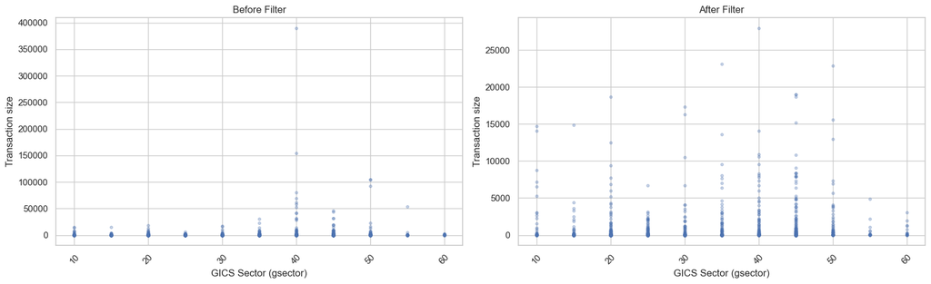

```python
#remove outlier at the smallest 2% and largest 2%

q2 = final_data["transactionsize_usd"].quantile(0.02)
q98 = final_data["transactionsize_usd"].quantile(0.98)

final_data_filtered = final_data[(final_data["transactionsize_usd"] >= q2) &
                    (final_data["transactionsize_usd"] <= q98)]

# Create 2 subplots side by side
fig, axes = plt.subplots(1, 2, figsize=(16, 5))  # 1 row, 2 columns

# --- Before filtered ---
axes[0].scatter(final_data["gsector"], final_data["transactionsize_usd"],
                alpha=0.3, s=10)
axes[0].set_xlabel("GICS Sector (gsector)")
axes[0].set_ylabel("Transaction size")
axes[0].set_title("Before Filter")
axes[0].tick_params(axis='x', rotation=45)

# --- After filtered ---
axes[1].scatter(final_data_filtered["gsector"], final_data_filtered["transactionsize_usd"],
                alpha=0.3, s=10)
axes[1].set_xlabel("GICS Sector (gsector)")
axes[1].set_ylabel("Transaction size")
axes[1].set_title("After Filter")
axes[1].tick_params(axis='x', rotation=45)

plt.tight_layout()
plt.show()
```

```python
# --- filter outliers (2% / 98%) ---
q2  = final_data["log_transaction_size_usd_nextyear"].quantile(0.02)
q98 = final_data["log_transaction_size_usd_nextyear"].quantile(0.98)

final_data_filtered = final_data[
    (final_data["log_transaction_size_usd_nextyear"] >= q2) &
    (final_data["log_transaction_size_usd_nextyear"] <= q98)
].copy()

# --- helper: fit with firm-clustered SE ---
def fit_clustered(formula, data, cluster_col="gvkey"):
    base = smf.ols(formula, data=data, missing="drop")
    used_idx = base.data.row_labels
    groups = data.loc[used_idx, cluster_col]
    return base.fit(cov_type="cluster", cov_kwds={"groups": groups, "use_correction": True})

# 1) Simple model (clustered)
m1 = fit_clustered("log_transaction_size_usd_nextyear ~ normalized_SRR_median", final_data_filtered)

# 2) Controls (clustered)
m2 = fit_clustered(
    "log_transaction_size_usd_nextyear ~ normalized_SRR_median + TobinQ + tenure_years + gender "
    "+ log_stock_awards + EBIT_Margin + shrown_excl_opts_pct "
    "+ Leverage + log_option_awards + log_revt_lag + log_at_lag",
    final_data_filtered
)


# 3) Sector FE (clustered)
m3 = fit_clustered(
    "log_transaction_size_usd_nextyear ~ normalized_SRR_median + TobinQ + tenure_years + gender "
    "+ log_stock_awards + EBIT_Margin + shrown_excl_opts_pct "
    "+ Leverage + log_option_awards + log_revt_lag + log_at_lag + C(gsector)",
    final_data_filtered
)

# --- Compare coef + clustered SE + p-value ---
print("\n==========================================")
print(f"1. Simple:        coef={m1.params['normalized_SRR_median']:.3f}  se={m1.bse['normalized_SRR_median']:.3f}  p={m1.pvalues['normalized_SRR_median']:.3g}")
print(f"2. + Controls:    coef={m2.params['normalized_SRR_median']:.3f}  se={m2.bse['normalized_SRR_median']:.3f}  p={m2.pvalues['normalized_SRR_median']:.3g}")
print(f"3. + Sector FE:   coef={m3.params['normalized_SRR_median']:.3f}  se={m3.bse['normalized_SRR_median']:.3f}  p={m3.pvalues['normalized_SRR_median']:.3g}")
print("------------------------------------------")
print("==========================================")

# Optional: full summaries
# print(m1.summary()); print(m2.summary()); print(m3.summary())
```

```
==========================================
1. Simple:        coef=128.932  se=58.944  p=0.0287
2. + Controls:    coef=169.829  se=67.840  p=0.0123
3. + Sector FE:   coef=174.912  se=62.522  p=0.00515
------------------------------------------
==========================================
```

### 4.2 Lag corrected SRR by 1 year (Causality)

Result: No causality is seen

```python
# sort panel
final_data = final_data.sort_values(["gvkey", "publish_year"]).copy()

# 1-year lag of SRR measures (within firm)

final_data["normalized_SRR_mean_lag1"] = final_data.groupby("gvkey")["normalized_SRR_mean"].shift(1)
final_data["normalized_SRR_median_lag1"] = final_data.groupby("gvkey")["normalized_SRR_median"].shift(1)

# Helper: OLS with FE + firm-clustered SEs
def fit_fe_clustered(formula, data, cluster_col="gvkey"):
    base = smf.ols(formula, data=data, missing="drop")
    used_idx = base.data.row_labels
    groups = data.loc[used_idx, cluster_col]
    return base.fit(cov_type="cluster", cov_kwds={"groups": groups, "use_correction": True})

# Model with controls + FE
# # Firm + year FE
m_lag_firm = fit_fe_clustered(
    "log_transaction_size_usd_nextyear ~ normalized_SRR_mean_lag1 + TobinQ + tenure_years + gender "
    "+ age + log_stock_awards + EBIT_Margin + shrown_excl_opts_pct + Leverage "
    "+ log_option_awards + log_revt_lag + log_at_lag "
    "+ C(gsector) + C(publish_year)",
    final_data
)

print(m_lag_firm.summary())

print("\n==========================================")

var = "normalized_SRR_mean_lag1"

print("coef :", m_lag_firm.params[var])
print("se   :", m_lag_firm.bse[var])
print("pval :", m_lag_firm.pvalues[var])
```

```
                                    OLS Regression Results
=============================================================================================
Dep. Variable:     log_transaction_size_usd_nextyear   R-squared:                       0.141
Model:                                           OLS   Adj. R-squared:                  0.095
Method:                                Least Squares   F-statistic:                     5.779
Date:                               Fri, 30 Jan 2026   Prob (F-statistic):           6.72e-16
Time:                                       23:13:56   Log-Likelihood:                -1740.9
No. Observations:                                743   AIC:                             3560.
Df Residuals:                                    704   BIC:                             3740.
Df Model:                                         38
Covariance Type:                             cluster
=============================================================================================
                                coef    std err          z      P>|z|      [0.025      0.975]
---------------------------------------------------------------------------------------------
Intercept                    -0.8260      1.353     -0.611      0.541      -3.477       1.825
C(gsector)[T.15.0]           -0.2911      0.552     -0.528      0.598      -1.372       0.790
C(gsector)[T.20.0]           -0.1515      0.531     -0.285      0.776      -1.193       0.890
C(gsector)[T.25.0]           -0.1621      0.522     -0.311      0.756      -1.185       0.860
C(gsector)[T.30.0]           -0.7124      0.448     -1.589      0.112      -1.591       0.166
C(gsector)[T.35.0]            0.6022      0.516      1.168      0.243      -0.409       1.613
C(gsector)[T.40.0]            1.2721      0.655      1.944      0.052      -0.011       2.555
C(gsector)[T.45.0]            0.7294      0.491      1.484      0.138      -0.234       1.693
C(gsector)[T.50.0]            1.4682      0.439      3.343      0.001       0.608       2.329
C(gsector)[T.55.0]           -0.6924      0.886     -0.782      0.434      -2.428       1.043
C(gsector)[T.60.0]            0.8424      0.746      1.130      0.259      -0.619       2.304
C(publish_year)[T.2008.0]     1.9747      1.045      1.889      0.059      -0.074       4.024
C(publish_year)[T.2009.0]     0.4813      1.187      0.406      0.685      -1.845       2.808
C(publish_year)[T.2010.0]     1.4397      0.577      2.495      0.013       0.309       2.571
C(publish_year)[T.2011.0]     1.5313      0.752      2.036      0.042       0.057       3.005
C(publish_year)[T.2012.0]     1.6855      0.747      2.256      0.024       0.221       3.150
C(publish_year)[T.2013.0]     1.1074      0.750      1.476      0.140      -0.363       2.577
C(publish_year)[T.2014.0]     1.8556      0.750      2.475      0.013       0.386       3.325
C(publish_year)[T.2015.0]     1.4779      0.731      2.022      0.043       0.045       2.911
C(publish_year)[T.2016.0]     1.7085      0.738      2.315      0.021       0.262       3.155
C(publish_year)[T.2017.0]     1.7434      0.813      2.144      0.032       0.149       3.337
C(publish_year)[T.2018.0]     1.0730      0.680      1.578      0.114      -0.259       2.405
C(publish_year)[T.2019.0]     1.6743      0.844      1.984      0.047       0.020       3.328
C(publish_year)[T.2020.0]     1.9855      0.960      2.069      0.039       0.105       3.866
C(publish_year)[T.2021.0]     1.8484      0.876      2.111      0.035       0.132       3.564
C(publish_year)[T.2022.0]     1.7746      0.889      1.996      0.046       0.032       3.517
```

[output cut: 14 more lines]

```
Omnibus:                       25.191   Durbin-Watson:                   2.013
Prob(Omnibus):                  0.000   Jarque-Bera (JB):               12.193
Skew:                          -0.056   Prob(JB):                      0.00225
Kurtosis:                       2.382   Cond. No.                     7.36e+04
==============================================================================

Notes:
[1] Standard Errors are robust to cluster correlation (cluster)
[2] The condition number is large, 7.36e+04. This might indicate that there are
strong multicollinearity or other numerical problems.

==========================================
coef : -14.998420750649615
se   : 94.31526242444318
pval : 0.873649710733196
```

```python
# sort panel
final_data = final_data.sort_values(["gvkey", "publish_year"]).copy()

# 1-year lag of SRR measures (within firm)

final_data["normalized_SRR_mean_lag1"] = final_data.groupby("gvkey")["normalized_SRR_mean"].shift(1)
final_data["normalized_SRR_median_lag1"] = final_data.groupby("gvkey")["normalized_SRR_median"].shift(1)

# Helper: OLS with FE + firm-clustered SEs
def fit_fe_clustered(formula, data, cluster_col="gvkey"):
    base = smf.ols(formula, data=data, missing="drop")
    used_idx = base.data.row_labels
    groups = data.loc[used_idx, cluster_col]
    return base.fit(cov_type="cluster", cov_kwds={"groups": groups, "use_correction": True})

# Model with controls + FE
# # Firm + year FE
m_lag_firm = fit_fe_clustered(
    "normalized_SRR_mean_lag1 ~ log_transaction_size_usd_nextyear+ TobinQ + tenure_years + gender "
    "+ age + log_stock_awards + EBIT_Margin + shrown_excl_opts_pct + Leverage "
    "+ log_option_awards + log_revt_lag + log_at_lag "
    "+ C(gsector) + C(publish_year)",
    final_data
)

print(m_lag_firm.summary())

print("\n==========================================")

var = "log_transaction_size_usd_nextyear"

print("coef :", m_lag_firm.params[var])
print("se   :", m_lag_firm.bse[var])
print("pval :", m_lag_firm.pvalues[var])
```

```
                               OLS Regression Results
====================================================================================
Dep. Variable:     normalized_SRR_mean_lag1   R-squared:                       0.094
Model:                                  OLS   Adj. R-squared:                  0.045
Method:                       Least Squares   F-statistic:                     3.600
Date:                      Fri, 30 Jan 2026   Prob (F-statistic):           6.39e-09
Time:                              23:13:56   Log-Likelihood:                 4234.0
No. Observations:                       743   AIC:                            -8390.
Df Residuals:                           704   BIC:                            -8210.
Df Model:                                38
Covariance Type:                    cluster
=====================================================================================================
                                        coef    std err          z      P>|z|      [0.025      0.975]
-----------------------------------------------------------------------------------------------------
Intercept                             0.0008      0.001      1.203      0.229      -0.000       0.002
C(gsector)[T.15.0]                   -0.0005      0.001     -0.809      0.419      -0.002       0.001
C(gsector)[T.20.0]                   -0.0005      0.001     -0.741      0.458      -0.002       0.001
C(gsector)[T.25.0]                   -0.0007      0.001     -1.112      0.266      -0.002       0.001
C(gsector)[T.30.0]                   -0.0007      0.001     -1.140      0.254      -0.002       0.000
C(gsector)[T.35.0]                   -0.0005      0.001     -0.861      0.389      -0.002       0.001
C(gsector)[T.40.0]                   -0.0004      0.001     -0.625      0.532      -0.002       0.001
C(gsector)[T.45.0]                   -0.0007      0.001     -1.095      0.274      -0.002       0.001
C(gsector)[T.50.0]                   -0.0008      0.001     -1.258      0.208      -0.002       0.000
C(gsector)[T.55.0]                   -0.0009      0.001     -1.360      0.174      -0.002       0.000
C(gsector)[T.60.0]                   -0.0004      0.001     -0.580      0.562      -0.002       0.001
C(publish_year)[T.2008.0]             0.0009      0.001      0.919      0.358      -0.001       0.003
C(publish_year)[T.2009.0]          4.538e-05      0.000      0.217      0.829      -0.000       0.000
C(publish_year)[T.2010.0]          3.175e-05      0.000      0.155      0.877      -0.000       0.000
C(publish_year)[T.2011.0]          7.693e-05      0.000      0.395      0.693      -0.000       0.000
C(publish_year)[T.2012.0]             0.0001      0.000      0.543      0.587      -0.000       0.001
C(publish_year)[T.2013.0]             0.0001      0.000      0.494      0.621      -0.000       0.000
C(publish_year)[T.2014.0]             0.0003      0.000      1.262      0.207      -0.000       0.001
C(publish_year)[T.2015.0]             0.0005      0.000      1.817      0.069   -3.67e-05       0.001
C(publish_year)[T.2016.0]             0.0005      0.000      1.589      0.112      -0.000       0.001
C(publish_year)[T.2017.0]             0.0004      0.000      1.488      0.137      -0.000       0.001
C(publish_year)[T.2018.0]             0.0004      0.000      1.239      0.215      -0.000       0.001
C(publish_year)[T.2019.0]          7.961e-06      0.000      0.041      0.967      -0.000       0.000
C(publish_year)[T.2020.0]         -2.804e-05      0.000     -0.170      0.865      -0.000       0.000
C(publish_year)[T.2021.0]         -2.364e-05      0.000     -0.129      0.897      -0.000       0.000
C(publish_year)[T.2022.0]         -1.606e-05      0.000     -0.082      0.935      -0.000       0.000
```

[output cut: 14 more lines]

```
Omnibus:                      996.505   Durbin-Watson:                   1.315
Prob(Omnibus):                  0.000   Jarque-Bera (JB):           204359.896
Skew:                           6.959   Prob(JB):                         0.00
Kurtosis:                      83.046   Cond. No.                     4.90e+03
==============================================================================

Notes:
[1] Standard Errors are robust to cluster correlation (cluster)
[2] The condition number is large, 4.9e+03. This might indicate that there are
strong multicollinearity or other numerical problems.

==========================================
coef : -1.5534014698289653e-06
se   : 9.793086602578666e-06
pval : 0.8739664946788703
```

```python
m_lag_firm = fit_fe_clustered(
    "normalized_SRR_mean_lag1 ~ log_transaction_size_usd_nextyear+ C(gsector)",
    final_data
)

print(m_lag_firm.summary())

print("\n==========================================")

var = "log_transaction_size_usd_nextyear"

print("coef :", m_lag_firm.params[var])
print("se   :", m_lag_firm.bse[var])
print("pval :", m_lag_firm.pvalues[var])
```

```
                               OLS Regression Results
====================================================================================
Dep. Variable:     normalized_SRR_mean_lag1   R-squared:                       0.035
Model:                                  OLS   Adj. R-squared:                  0.020
Method:                       Least Squares   F-statistic:                     4.235
Date:                      Fri, 30 Jan 2026   Prob (F-statistic):           1.52e-05
Time:                              23:13:56   Log-Likelihood:                 4210.6
No. Observations:                       743   AIC:                            -8397.
Df Residuals:                           731   BIC:                            -8342.
Df Model:                                11
Covariance Type:                    cluster
=====================================================================================================
                                        coef    std err          z      P>|z|      [0.025      0.975]
-----------------------------------------------------------------------------------------------------
Intercept                             0.0009      0.001      1.506      0.132      -0.000       0.002
C(gsector)[T.15.0]                   -0.0005      0.001     -0.774      0.439      -0.002       0.001
C(gsector)[T.20.0]                   -0.0004      0.001     -0.634      0.526      -0.002       0.001
C(gsector)[T.25.0]                   -0.0006      0.001     -1.008      0.313      -0.002       0.001
C(gsector)[T.30.0]                   -0.0006      0.001     -1.077      0.282      -0.002       0.001
C(gsector)[T.35.0]                   -0.0005      0.001     -0.751      0.452      -0.002       0.001
C(gsector)[T.40.0]                   -0.0004      0.001     -0.598      0.550      -0.002       0.001
C(gsector)[T.45.0]                   -0.0006      0.001     -1.017      0.309      -0.002       0.001
C(gsector)[T.50.0]                   -0.0007      0.001     -1.238      0.216      -0.002       0.000
C(gsector)[T.55.0]                   -0.0007      0.001     -1.168      0.243      -0.002       0.000
C(gsector)[T.60.0]                   -0.0004      0.001     -0.606      0.545      -0.002       0.001
log_transaction_size_usd_nextyear -3.355e-06    1.1e-05     -0.304      0.761    -2.5e-05    1.83e-05
==============================================================================
Omnibus:                      996.968   Durbin-Watson:                   1.264
Prob(Omnibus):                  0.000   Jarque-Bera (JB):           189090.297
Skew:                           7.006   Prob(JB):                         0.00
Kurtosis:                      79.887   Cond. No.                         95.1
==============================================================================

Notes:
[1] Standard Errors are robust to cluster correlation (cluster)

==========================================
coef : -3.354600741055933e-06
se   : 1.1045354566101878e-05
pval : 0.7613477277754338
```

```python
m_lag_firm = fit_fe_clustered(
    "normalized_SRR_mean_lag1 ~ log_transaction_size_usd_nextyear",
    final_data
)

print(m_lag_firm.summary())

print("\n==========================================")

var = "log_transaction_size_usd_nextyear"

print("coef :", m_lag_firm.params[var])
print("se   :", m_lag_firm.bse[var])
print("pval :", m_lag_firm.pvalues[var])
```

```
                               OLS Regression Results
====================================================================================
Dep. Variable:     normalized_SRR_mean_lag1   R-squared:                       0.000
Model:                                  OLS   Adj. R-squared:                 -0.001
Method:                       Least Squares   F-statistic:                   0.09695
Date:                      Fri, 30 Jan 2026   Prob (F-statistic):              0.756
Time:                              23:13:56   Log-Likelihood:                 4197.5
No. Observations:                       743   AIC:                            -8391.
Df Residuals:                           741   BIC:                            -8382.
Df Model:                                 1
Covariance Type:                    cluster
=====================================================================================================
                                        coef    std err          z      P>|z|      [0.025      0.975]
-----------------------------------------------------------------------------------------------------
Intercept                             0.0004   7.85e-05      4.982      0.000       0.000       0.001
log_transaction_size_usd_nextyear -3.279e-06   1.05e-05     -0.311      0.756   -2.39e-05    1.74e-05
==============================================================================
Omnibus:                     1034.526   Durbin-Watson:                   1.214
Prob(Omnibus):                  0.000   Jarque-Bera (JB):           226422.198
Skew:                           7.465   Prob(JB):                         0.00
Kurtosis:                      87.207   Cond. No.                         12.0
==============================================================================

Notes:
[1] Standard Errors are robust to cluster correlation (cluster)

==========================================
coef : -3.279222153391897e-06
se   : 1.0531405040206354e-05
pval : 0.7555151305312023
```

```python
df = final_data.sort_values(["gvkey", "publish_year"]).copy()

# Lead of Y (t+1) within firm
df["log_transaction_size_usd_nextyear"] = (
    df.groupby("gvkey")["log_transaction_size_usd"].shift(-1)
)

# Lag of Y (t)
# If you want explicit lag:
df["log_transaction_size_usd_lag1"] = (
    df.groupby("gvkey")["log_transaction_size_usd"].shift(0)  # same-year
)

# Lag of SRR (t-1 relative to nextyear is t)
# If your normalized_SRR_mean_lag1 is already computed correctly, skip this.
df["normalized_SRR_mean_lag1"] = (
    df.groupby("gvkey")["normalized_SRR_mean"].shift(0)  # same-year relative to nextyear
)

# Drop rows where nextyear is missing (last year per firm) + any missing regressors
needed = [
    "log_transaction_size_usd_nextyear",
    "log_transaction_size_usd",
    "normalized_SRR_mean_lag1",
    "TobinQ", "tenure_years", "gender", "age",
    "log_stock_awards", "EBIT_Margin", "shrown_excl_opts_pct", "Leverage",
    "log_option_awards", "log_revt_lag", "log_at_lag",
    "gsector", "publish_year", "gvkey"
]
d = df.dropna(subset=needed).copy()


# Unrestricted: add SRR lag
f_unrestricted = (
    "log_transaction_size_usd_nextyear ~ "
    "log_transaction_size_usd "
    "+ normalized_SRR_mean_lag1 "
    "+ TobinQ + tenure_years + gender + age "
    "+ log_stock_awards + EBIT_Margin + shrown_excl_opts_pct + Leverage "
    "+ log_option_awards + log_revt_lag + log_at_lag "
    "+ C(gsector) + C(publish_year)"
)

m_u = smf.ols(f_unrestricted, data=d).fit(cov_type="cluster",
                                      cov_kwds={"groups": d["gvkey"]})


print(m_u.summary())
print("coef SRR:", m_u.params["normalized_SRR_mean_lag1"])
print("pval SRR:", m_u.pvalues["normalized_SRR_mean_lag1"])
print("coef lagged log_transaction_size_usd:", m_u.params["log_transaction_size_usd"])
print("pval lagged log_transaction_size_usd:", m_u.pvalues["log_transaction_size_usd"])
```

```
                                    OLS Regression Results
=============================================================================================
Dep. Variable:     log_transaction_size_usd_nextyear   R-squared:                       0.142
Model:                                           OLS   Adj. R-squared:                  0.096
Method:                                Least Squares   F-statistic:                     11.72
Date:                               Fri, 30 Jan 2026   Prob (F-statistic):           1.09e-30
Time:                                       23:13:56   Log-Likelihood:                -1733.5
No. Observations:                                743   AIC:                             3545.
Df Residuals:                                    704   BIC:                             3725.
Df Model:                                         38
Covariance Type:                             cluster
=============================================================================================
                                coef    std err          z      P>|z|      [0.025      0.975]
---------------------------------------------------------------------------------------------
Intercept                     0.4896      1.588      0.308      0.758      -2.623       3.602
C(gsector)[T.15.0]           -0.2745      0.564     -0.487      0.627      -1.380       0.831
C(gsector)[T.20.0]            0.1088      0.542      0.201      0.841      -0.953       1.170
C(gsector)[T.25.0]            0.2383      0.556      0.429      0.668      -0.851       1.328
C(gsector)[T.30.0]           -0.3787      0.547     -0.692      0.489      -1.451       0.693
C(gsector)[T.35.0]            0.8566      0.569      1.505      0.132      -0.259       1.972
C(gsector)[T.40.0]            1.2828      0.697      1.840      0.066      -0.084       2.649
C(gsector)[T.45.0]            0.4231      0.486      0.870      0.384      -0.530       1.376
C(gsector)[T.50.0]            1.1968      0.463      2.587      0.010       0.290       2.104
C(gsector)[T.55.0]           -0.5228      0.750     -0.697      0.486      -1.992       0.947
C(gsector)[T.60.0]            0.3477      0.871      0.399      0.690      -1.360       2.055
C(publish_year)[T.2008.0]    -0.5383      0.938     -0.574      0.566      -2.377       1.301
C(publish_year)[T.2009.0]    -0.2214      1.090     -0.203      0.839      -2.358       1.915
C(publish_year)[T.2010.0]     0.6465      1.132      0.571      0.568      -1.573       2.866
C(publish_year)[T.2011.0]    -0.0315      1.061     -0.030      0.976      -2.110       2.047
C(publish_year)[T.2012.0]    -0.0032      1.066     -0.003      0.998      -2.092       2.086
C(publish_year)[T.2013.0]     0.1358      1.020      0.133      0.894      -1.863       2.134
C(publish_year)[T.2014.0]     0.2262      0.990      0.229      0.819      -1.713       2.166
C(publish_year)[T.2015.0]    -0.1317      1.036     -0.127      0.899      -2.162       1.899
C(publish_year)[T.2016.0]     0.3318      0.964      0.344      0.731      -1.557       2.221
C(publish_year)[T.2017.0]    -0.0843      0.995     -0.085      0.933      -2.035       1.867
C(publish_year)[T.2018.0]    -0.3573      1.045     -0.342      0.732      -2.405       1.691
C(publish_year)[T.2019.0]     0.2090      1.038      0.201      0.840      -1.826       2.244
C(publish_year)[T.2020.0]    -0.4710      1.098     -0.429      0.668      -2.623       1.681
C(publish_year)[T.2021.0]     0.0375      0.977      0.038      0.969      -1.878       1.953
C(publish_year)[T.2022.0]    -0.6125      1.087     -0.563      0.573      -2.743       1.518
```

[output cut: 13 more lines]

```
==============================================================================
Omnibus:                       19.899   Durbin-Watson:                   2.043
Prob(Omnibus):                  0.000   Jarque-Bera (JB):               10.271
Skew:                          -0.027   Prob(JB):                      0.00588
Kurtosis:                       2.426   Cond. No.                     7.30e+04
==============================================================================

Notes:
[1] Standard Errors are robust to cluster correlation (cluster)
[2] The condition number is large, 7.3e+04. This might indicate that there are
strong multicollinearity or other numerical problems.
coef SRR: 150.84871921056254
pval SRR: 0.26879797556962715
coef lagged log_transaction_size_usd: 0.01853971953166924
pval lagged log_transaction_size_usd: 0.7292362135276723
```

### 4.3 Winsorize SRR only among observations with transaction volume at 1%

```python
def winsorize_series(s, p_low=0.01, p_high=0.99):
    lo, hi = s.quantile([p_low, p_high])
    return s.clip(lower=lo, upper=hi)
mask = final_data["transactionsize_usd_nextyear"].notna()


final_data.loc[mask, "normalized_SRR_mean_w"] = winsorize_series(final_data.loc[mask, "normalized_SRR_mean"], 0.01, 0.99)
final_data.loc[mask, "normalized_SRR_median_w"] = winsorize_series(final_data.loc[mask, "normalized_SRR_median"], 0.01, 0.99)

#Regression with basic controls
control_vars = ["TobinQ", "tenure_years", "gender", "age", "log_stock_awards", "log_stock_awards",
                "EBIT_Margin","shrown_excl_opts_pct","Leverage","log_option_awards","log_revt_lag","log_at_lag"]
model_with_controls, models_basic = ols_with_controls_clustered(
    data=final_data,
    dependent_var="log_transaction_size_usd_nextyear",
    independent_vars=["normalized_SRR_mean_w", "normalized_SRR_median_w"],
    control_vars=control_vars,
)
print("Regression with Winsorized SRR Controls Results on log_transaction_size_usd_nextyear with Controls:\n")
display(model_with_controls)
```

```
Regression with Winsorized SRR Controls Results on log_transaction_size_usd_nextyear with Controls:
```

|  | Independent_Variable | coef | Std_Error | T_Stat | P_Value | [0.025 | 0.975] | R_Squared | Adj_R_Squared | N_Clusters |
| --- | --- | --- | --- | --- | --- | --- | --- | --- | --- | --- |
| 0 | normalized_SRR_mean_w | 353.064675 | 114.935280 | 3.071856 | 0.002127 | 127.795665 | 578.333685 | 0.09469 | 0.083278 | 222 |
| 1 | normalized_SRR_median_w | 355.463552 | 114.805733 | 3.096218 | 0.001960 | 130.448449 | 580.478655 | 0.09480 | 0.083390 | 222 |

Across all 2 SRR measures, the coefficient stays positive and statistically significant after winsorization and controls. The SRR–deal-size link is not just caused by a few outlier interviews.

```python
# ---- inputs ----

models_fe = ols_with_controls_and_fe_clusterd(
    data=final_data,
    dependent_var="log_transaction_size_usd_nextyear",
    independent_vars=["normalized_SRR_mean_w", "normalized_SRR_median_w"],
    control_vars=control_vars,
    fe_specs=fe_specs,
    cov_type="nonrobust"
)

results_df = fe_results_table(models_fe, data=final_data, cluster_col="gvkey")
print("Regression with Winsorized SRR Controls and Fixed Effects Results on log_transaction_size_usd_nextyear:\n")
display(results_df)
```

```
Regression with Winsorized SRR Controls and Fixed Effects Results on log_transaction_size_usd_nextyear:
```

|  | FE_spec | Independent_Variable | Coefficient | Std_Error | T_Stat | P_Value | [0.025 | 0.975] | R_Squared | Adj_R_Squared | N_Clusters | N_Obs |
| --- | --- | --- | --- | --- | --- | --- | --- | --- | --- | --- | --- | --- |
| 0 | FE1: sector | normalized_SRR_mean_w | 357.328150 | 131.144202 | 2.724697 | 0.006555 | 99.959555 | 614.696745 | 0.117469 | 0.096858 | 222 | 965 |
| 1 | FE1: sector | normalized_SRR_median_w | 360.367342 | 130.953025 | 2.751883 | 0.006039 | 103.373929 | 617.360754 | 0.117607 | 0.096999 | 222 | 965 |
| 2 | FE2: sector + year | normalized_SRR_mean_w | 382.594141 | 135.222584 | 2.829366 | 0.004765 | 117.215881 | 647.972400 | 0.128296 | 0.092524 | 222 | 965 |
| 3 | FE2: sector + year | normalized_SRR_median_w | 385.343439 | 134.996836 | 2.854463 | 0.004407 | 120.408217 | 650.278661 | 0.128429 | 0.092662 | 222 | 965 |
| 4 | FE3: firm | normalized_SRR_mean_w | 347.958907 | 146.313680 | 2.378171 | 0.017655 | 60.713766 | 635.204048 | 0.414278 | 0.227584 | 222 | 965 |
| 5 | FE3: firm | normalized_SRR_median_w | 348.241984 | 146.282764 | 2.380608 | 0.017539 | 61.057540 | 635.426429 | 0.414287 | 0.227596 | 222 | 965 |
| 6 | FE4: sector + firm | normalized_SRR_mean_w | 347.958907 | 146.313680 | 2.378171 | 0.017655 | 60.713766 | 635.204048 | 0.414278 | 0.227584 | 222 | 965 |
| 7 | FE4: sector + firm | normalized_SRR_median_w | 348.241984 | 146.282764 | 2.380608 | 0.017539 | 61.057540 | 635.426429 | 0.414287 | 0.227596 | 222 | 965 |
| 8 | FE5: year | normalized_SRR_mean_w | 364.240113 | 134.679747 | 2.704491 | 0.006965 | 99.930882 | 628.549345 | 0.104854 | 0.078076 | 222 | 965 |
| 9 | FE5: year | normalized_SRR_median_w | 366.481840 | 134.487971 | 2.725016 | 0.006550 | 102.548970 | 630.414710 | 0.104960 | 0.078185 | 222 | 965 |

The estimated association between normalized SRR and next-year acquisition size remains positive and statistically significant across multiple fixed-effect specifications.

### 4.4 Check multicollinearity

Purpose:To assess whether correlation among regressors inflates estimation uncertainty, we compute variance inflation factors (VIFs) for the main explanatory and control variables.

Intuition: High VIF values indicate strong multicollinearity, which can increase standard errors and produce unstable coefficient estimates across specifications.

Result: Variance inflation factors (VIFs) for the main explanatory variable and all controls are low (all < 2.1), indicating that multicollinearity is not a material concern

```python
# Check multicollinearity by VIF

def compute_vif(df, features):
    X = df[features].assign(constant=1)  # add constant for intercept
    vif_data = pd.DataFrame()
    vif_data["feature"] = features
    vif_data["VIF"] = [variance_inflation_factor(X.values, i) for i in range(len(features))]
    return vif_data
features = [
    "normalized_SRR_mean", "TobinQ", "tenure_years", "gender", "CF", "age", "Aqc_Ratio",
    "shrown_excl_opts_pct", "revt_lag", "Leverage",
    "log_option_awards", "log_stock_awards", "opt_unex_exer_est_val"
]
vif_results = compute_vif(final_data, features)
print(vif_results)
```

```
                  feature       VIF
0     normalized_SRR_mean  1.008127
1                  TobinQ  1.472676
2            tenure_years  1.788360
3                  gender  1.055481
4                      CF  1.291133
5                     age  1.524452
6               Aqc_Ratio  1.083126
7    shrown_excl_opts_pct  2.076961
8                revt_lag  1.098426
9                Leverage  1.045056
10      log_option_awards  1.142242
11       log_stock_awards  1.361907
12  opt_unex_exer_est_val  1.434540
```

# Insight

The model same year regression and next 2 year regression show the relationship between SRR and transaction size is not significant

SRR is statistical significant and positive associated with the acquisition activity next year

The model demonstrates that traditional governance and demographic variables have negligible predictive power regarding transaction size

1. CEO Characteristics: Neither gender nor tenure_years impact the scale of transactions.
2. Compensation Structures: The magnitude of stock awards and option awards does not appear to incentivize larger deal tickets.
3. Capital Structure: Current leverage does not act as a statistically significant constraint on the following year's acquisition size.

# Reference

Liu, Yue (Lucy) and Taffler, Richard J., Damned Out of Their Own Mouths: CEO Narcissism in M&A Decision-Making and Its Impact on Firm Performance (February 15, 2009). Available at SSRN: https://ssrn.com/abstract=1344119 or http://dx.doi.org/10.2139/ssrn.1344119